# Code

Deep belief networks from G. Hinton  
(http://www.cs.toronto.edu/~hinton/csc2515/projects/deep1.html)

DBN code is available at https://github.com/albertbup/deep-belief-network

**Set-up**

```python
# Import NumPy
import numpy as np
np.random.seed(42)  # Set random seed

# Import scikit-learn DBN dependency modules
from sklearn.datasets import load_digits
from sklearn.model_selection import train_test_split
from sklearn.metrics.classification import accuracy_score

# Import deep-belief network
# Found at https://github.com/albertbup/deep-belief-network
from dbn.tensorflow import SupervisedDBNClassification

# Graphs
import matplotlib.pyplot as plt
```

**Load and format dataset**

```python
# Load MNIST dataset
from sklearn.datasets import fetch_mldata
mnist = fetch_mldata('MNIST original')
```

```python
# Create set of 1000 MNIST datapoints
class_count = [0, 0, 0, 0, 0, 0, 0, 0, 0, 0]
X = []
Y = []

# Get 100 of each class
for i in range(0, len(mnist.data)):
    target_value = int(mnist.target[i])
    if class_count[target_value] < 100:
        X.append(mnist.data[i])
        Y.append(target_value)
        class_count[target_value] += 1
    if sum(class_count) == 1000:
        break

# Convert to NumPy
X = np.array(X)
Y = np.array(Y)

# Scale data for MNIST
X = (X / 256).astype(np.float32)
```

**DBN function**

```python
def deep_belief_net(hidden_layers_structure=[256, 256],
                    learning_rate_rbm=0.05,
                    learning_rate=0.1,
                    n_epochs_rbm=10,
                    n_iter_backprop=100,
                    batch_size=32,
                    activation_function='relu',
                    dropout_p=0.2):

    # Splitting data
    X_train, X_test, Y_train, Y_test = train_test_split(X, Y, test_size=0.2, random_state=0)

    # Training
    classifier = SupervisedDBNClassification(hidden_layers_structure=hidden_layers_structure,
                                             learning_rate_rbm=learning_rate_rbm,
                                             learning_rate=learning_rate,
                                             n_epochs_rbm=n_epochs_rbm,
                                             n_iter_backprop=n_iter_backprop,
                                             batch_size=batch_size,
                                             activation_function=activation_function,
                                             dropout_p=dropout_p)
    classifier.fit(X_train, Y_train)

    # Save the model
    classifier.save('model.pkl')

    # Restore
    classifier = SupervisedDBNClassification.load('model.pkl')

    # Test
    Y_pred = classifier.predict(X_test)
    acc = accuracy_score(Y_test, Y_pred)
    print('Done.\nAccuracy: %f' % acc)
    return acc
```

## Run DBN tests below:

**Default setting (base performance)**

```
hidden_layers_structure=[256, 256]
learning_rate_rbm=0.05
learning_rate=0.1
n_epochs_rbm=10
n_iter_backprop=100
batch_size=32
activation_function='relu'
dropout_p=0.2
```

```python
# Run DBN
default_acc = deep_belief_net()
```

```
[START] Pre-training step:
>> Epoch 1 finished 	RBM Reconstruction error 74.742325
>> Epoch 2 finished 	RBM Reconstruction error 41.013561
>> Epoch 3 finished 	RBM Reconstruction error 29.765366
>> Epoch 4 finished 	RBM Reconstruction error 39.022728
>> Epoch 5 finished 	RBM Reconstruction error 38.707474
>> Epoch 6 finished 	RBM Reconstruction error 45.363823
>> Epoch 7 finished 	RBM Reconstruction error 35.756557
>> Epoch 8 finished 	RBM Reconstruction error 37.316841
>> Epoch 9 finished 	RBM Reconstruction error 34.732811
>> Epoch 10 finished 	RBM Reconstruction error 26.490023
>> Epoch 1 finished 	RBM Reconstruction error 112.534027
>> Epoch 2 finished 	RBM Reconstruction error 114.069450
>> Epoch 3 finished 	RBM Reconstruction error 75.408974
>> Epoch 4 finished 	RBM Reconstruction error 76.183395
>> Epoch 5 finished 	RBM Reconstruction error 86.979401
>> Epoch 6 finished 	RBM Reconstruction error 107.212440
>> Epoch 7 finished 	RBM Reconstruction error 92.068924
>> Epoch 8 finished 	RBM Reconstruction error 101.160736
>> Epoch 9 finished 	RBM Reconstruction error 83.630653
>> Epoch 10 finished 	RBM Reconstruction error 109.224358
[END] Pre-training step
[START] Fine tuning step:
>> Epoch 0 finished 	ANN training loss 0.661431
>> Epoch 1 finished 	ANN training loss 0.473681
>> Epoch 2 finished 	ANN training loss 0.381107
>> Epoch 3 finished 	ANN training loss 0.329544
>> Epoch 4 finished 	ANN training loss 0.277102
>> Epoch 5 finished 	ANN training loss 0.237960
>> Epoch 6 finished 	ANN training loss 0.201121
>> Epoch 7 finished 	ANN training loss 0.176852
>> Epoch 8 finished 	ANN training loss 0.175910
>> Epoch 9 finished 	ANN training loss 0.150462
>> Epoch 10 finished 	ANN training loss 0.134221
>> Epoch 11 finished 	ANN training loss 0.106897
>> Epoch 12 finished 	ANN training loss 0.101303
>> Epoch 13 finished 	ANN training loss 0.097185
>> Epoch 14 finished 	ANN training loss 0.090578
>> Epoch 15 finished 	ANN training loss 0.081134
>> Epoch 16 finished 	ANN training loss 0.062650
```

[output cut: 71 more lines]

```
>> Epoch 88 finished 	ANN training loss 0.001311
>> Epoch 89 finished 	ANN training loss 0.001214
>> Epoch 90 finished 	ANN training loss 0.001467
>> Epoch 91 finished 	ANN training loss 0.001324
>> Epoch 92 finished 	ANN training loss 0.001243
>> Epoch 93 finished 	ANN training loss 0.001247
>> Epoch 94 finished 	ANN training loss 0.001068
>> Epoch 95 finished 	ANN training loss 0.001037
>> Epoch 96 finished 	ANN training loss 0.001000
>> Epoch 97 finished 	ANN training loss 0.001057
>> Epoch 98 finished 	ANN training loss 0.000968
>> Epoch 99 finished 	ANN training loss 0.000883
[END] Fine tuning step
Done.
Accuracy: 0.910000
```

```python
print('ACCURACY: ' + str(default_acc))
```

```
ACCURACY: 0.91
```

### Different 1-layer structures

```python
# Store accuracies
onelayer_acc = [0, 0, 0, 0, 0]
```

**Setting 1**

```
hidden_layers_structure=[100]
```

```python
onelayer_acc[0] = deep_belief_net(hidden_layers_structure=[100])
```

```
[START] Pre-training step:
>> Epoch 1 finished 	RBM Reconstruction error 86.976990
>> Epoch 2 finished 	RBM Reconstruction error 63.835304
>> Epoch 3 finished 	RBM Reconstruction error 47.721466
>> Epoch 4 finished 	RBM Reconstruction error 48.712292
>> Epoch 5 finished 	RBM Reconstruction error 55.124664
>> Epoch 6 finished 	RBM Reconstruction error 55.460400
>> Epoch 7 finished 	RBM Reconstruction error 53.136978
>> Epoch 8 finished 	RBM Reconstruction error 58.151356
>> Epoch 9 finished 	RBM Reconstruction error 63.297531
>> Epoch 10 finished 	RBM Reconstruction error 60.489033
[END] Pre-training step
[START] Fine tuning step:
>> Epoch 0 finished 	ANN training loss 0.787348
>> Epoch 1 finished 	ANN training loss 0.577817
>> Epoch 2 finished 	ANN training loss 0.461953
>> Epoch 3 finished 	ANN training loss 0.410259
>> Epoch 4 finished 	ANN training loss 0.370284
>> Epoch 5 finished 	ANN training loss 0.330365
>> Epoch 6 finished 	ANN training loss 0.296728
>> Epoch 7 finished 	ANN training loss 0.282827
>> Epoch 8 finished 	ANN training loss 0.254772
>> Epoch 9 finished 	ANN training loss 0.230176
>> Epoch 10 finished 	ANN training loss 0.229763
>> Epoch 11 finished 	ANN training loss 0.192113
>> Epoch 12 finished 	ANN training loss 0.183068
>> Epoch 13 finished 	ANN training loss 0.172171
>> Epoch 14 finished 	ANN training loss 0.153478
>> Epoch 15 finished 	ANN training loss 0.153599
>> Epoch 16 finished 	ANN training loss 0.138848
>> Epoch 17 finished 	ANN training loss 0.123464
>> Epoch 18 finished 	ANN training loss 0.117612
>> Epoch 19 finished 	ANN training loss 0.106769
>> Epoch 20 finished 	ANN training loss 0.099512
>> Epoch 21 finished 	ANN training loss 0.090460
>> Epoch 22 finished 	ANN training loss 0.088617
>> Epoch 23 finished 	ANN training loss 0.078987
>> Epoch 24 finished 	ANN training loss 0.079952
>> Epoch 25 finished 	ANN training loss 0.071017
>> Epoch 26 finished 	ANN training loss 0.068963
```

[output cut: 61 more lines]

```
>> Epoch 88 finished 	ANN training loss 0.005523
>> Epoch 89 finished 	ANN training loss 0.005322
>> Epoch 90 finished 	ANN training loss 0.005478
>> Epoch 91 finished 	ANN training loss 0.005106
>> Epoch 92 finished 	ANN training loss 0.005030
>> Epoch 93 finished 	ANN training loss 0.005018
>> Epoch 94 finished 	ANN training loss 0.005037
>> Epoch 95 finished 	ANN training loss 0.004526
>> Epoch 96 finished 	ANN training loss 0.004715
>> Epoch 97 finished 	ANN training loss 0.004673
>> Epoch 98 finished 	ANN training loss 0.004583
>> Epoch 99 finished 	ANN training loss 0.004510
[END] Fine tuning step
Done.
Accuracy: 0.900000
```

```python
print('ACCURACY: ' + str(onelayer_acc[0]))
```

```
ACCURACY: 0.9
```

**Setting 2**

```
hidden_layers_structure=[200]
```

```python
onelayer_acc[1] = deep_belief_net(hidden_layers_structure=[200])
```

```
[START] Pre-training step:
>> Epoch 1 finished 	RBM Reconstruction error 52.349266
>> Epoch 2 finished 	RBM Reconstruction error 72.684662
>> Epoch 3 finished 	RBM Reconstruction error 46.626049
>> Epoch 4 finished 	RBM Reconstruction error 43.839184
>> Epoch 5 finished 	RBM Reconstruction error 40.715866
>> Epoch 6 finished 	RBM Reconstruction error 38.150314
>> Epoch 7 finished 	RBM Reconstruction error 40.179611
>> Epoch 8 finished 	RBM Reconstruction error 44.788387
>> Epoch 9 finished 	RBM Reconstruction error 38.358856
>> Epoch 10 finished 	RBM Reconstruction error 36.342644
[END] Pre-training step
[START] Fine tuning step:
>> Epoch 0 finished 	ANN training loss 0.856542
>> Epoch 1 finished 	ANN training loss 0.590754
>> Epoch 2 finished 	ANN training loss 0.478319
>> Epoch 3 finished 	ANN training loss 0.415798
>> Epoch 4 finished 	ANN training loss 0.363241
>> Epoch 5 finished 	ANN training loss 0.342769
>> Epoch 6 finished 	ANN training loss 0.290627
>> Epoch 7 finished 	ANN training loss 0.278313
>> Epoch 8 finished 	ANN training loss 0.241844
>> Epoch 9 finished 	ANN training loss 0.221732
>> Epoch 10 finished 	ANN training loss 0.208090
>> Epoch 11 finished 	ANN training loss 0.195600
>> Epoch 12 finished 	ANN training loss 0.175948
>> Epoch 13 finished 	ANN training loss 0.176113
>> Epoch 14 finished 	ANN training loss 0.144608
>> Epoch 15 finished 	ANN training loss 0.132851
>> Epoch 16 finished 	ANN training loss 0.123206
>> Epoch 17 finished 	ANN training loss 0.118496
>> Epoch 18 finished 	ANN training loss 0.115063
>> Epoch 19 finished 	ANN training loss 0.101604
>> Epoch 20 finished 	ANN training loss 0.094504
>> Epoch 21 finished 	ANN training loss 0.086143
>> Epoch 22 finished 	ANN training loss 0.082999
>> Epoch 23 finished 	ANN training loss 0.074577
>> Epoch 24 finished 	ANN training loss 0.068166
>> Epoch 25 finished 	ANN training loss 0.064587
>> Epoch 26 finished 	ANN training loss 0.063026
```

[output cut: 61 more lines]

```
>> Epoch 88 finished 	ANN training loss 0.004829
>> Epoch 89 finished 	ANN training loss 0.004799
>> Epoch 90 finished 	ANN training loss 0.004780
>> Epoch 91 finished 	ANN training loss 0.004908
>> Epoch 92 finished 	ANN training loss 0.004728
>> Epoch 93 finished 	ANN training loss 0.004494
>> Epoch 94 finished 	ANN training loss 0.004456
>> Epoch 95 finished 	ANN training loss 0.004336
>> Epoch 96 finished 	ANN training loss 0.004266
>> Epoch 97 finished 	ANN training loss 0.004331
>> Epoch 98 finished 	ANN training loss 0.004199
>> Epoch 99 finished 	ANN training loss 0.004174
[END] Fine tuning step
Done.
Accuracy: 0.910000
```

```python
print('ACCURACY: ' + str(onelayer_acc[1]))
```

```
ACCURACY: 0.91
```

**Setting 3**

```
hidden_layers_structure=[300]
```

```python
onelayer_acc[2] = deep_belief_net(hidden_layers_structure=[300])
```

```
[START] Pre-training step:
>> Epoch 1 finished 	RBM Reconstruction error 87.902206
>> Epoch 2 finished 	RBM Reconstruction error 55.003399
>> Epoch 3 finished 	RBM Reconstruction error 40.669594
>> Epoch 4 finished 	RBM Reconstruction error 37.418659
>> Epoch 5 finished 	RBM Reconstruction error 39.941753
>> Epoch 6 finished 	RBM Reconstruction error 47.157059
>> Epoch 7 finished 	RBM Reconstruction error 31.197338
>> Epoch 8 finished 	RBM Reconstruction error 39.757397
>> Epoch 9 finished 	RBM Reconstruction error 33.218170
>> Epoch 10 finished 	RBM Reconstruction error 46.521252
[END] Pre-training step
[START] Fine tuning step:
>> Epoch 0 finished 	ANN training loss 0.809349
>> Epoch 1 finished 	ANN training loss 0.550912
>> Epoch 2 finished 	ANN training loss 0.458730
>> Epoch 3 finished 	ANN training loss 0.408621
>> Epoch 4 finished 	ANN training loss 0.343763
>> Epoch 5 finished 	ANN training loss 0.327247
>> Epoch 6 finished 	ANN training loss 0.292876
>> Epoch 7 finished 	ANN training loss 0.264524
>> Epoch 8 finished 	ANN training loss 0.235765
>> Epoch 9 finished 	ANN training loss 0.215654
>> Epoch 10 finished 	ANN training loss 0.202415
>> Epoch 11 finished 	ANN training loss 0.187902
>> Epoch 12 finished 	ANN training loss 0.166092
>> Epoch 13 finished 	ANN training loss 0.160441
>> Epoch 14 finished 	ANN training loss 0.142402
>> Epoch 15 finished 	ANN training loss 0.130498
>> Epoch 16 finished 	ANN training loss 0.122930
>> Epoch 17 finished 	ANN training loss 0.111313
>> Epoch 18 finished 	ANN training loss 0.106092
>> Epoch 19 finished 	ANN training loss 0.092249
>> Epoch 20 finished 	ANN training loss 0.089241
>> Epoch 21 finished 	ANN training loss 0.083307
>> Epoch 22 finished 	ANN training loss 0.077107
>> Epoch 23 finished 	ANN training loss 0.070437
>> Epoch 24 finished 	ANN training loss 0.064246
>> Epoch 25 finished 	ANN training loss 0.059722
>> Epoch 26 finished 	ANN training loss 0.056275
```

[output cut: 61 more lines]

```
>> Epoch 88 finished 	ANN training loss 0.004724
>> Epoch 89 finished 	ANN training loss 0.004845
>> Epoch 90 finished 	ANN training loss 0.004529
>> Epoch 91 finished 	ANN training loss 0.004636
>> Epoch 92 finished 	ANN training loss 0.004444
>> Epoch 93 finished 	ANN training loss 0.004189
>> Epoch 94 finished 	ANN training loss 0.004262
>> Epoch 95 finished 	ANN training loss 0.004398
>> Epoch 96 finished 	ANN training loss 0.003976
>> Epoch 97 finished 	ANN training loss 0.004088
>> Epoch 98 finished 	ANN training loss 0.003930
>> Epoch 99 finished 	ANN training loss 0.003776
[END] Fine tuning step
Done.
Accuracy: 0.910000
```

```python
print('ACCURACY: ' + str(onelayer_acc[2]))
```

```
ACCURACY: 0.91
```

**Setting 4**

```
hidden_layers_structure=[400]
```

```python
onelayer_acc[3] = deep_belief_net(hidden_layers_structure=[400])
```

```
[START] Pre-training step:
>> Epoch 1 finished 	RBM Reconstruction error 49.054512
>> Epoch 2 finished 	RBM Reconstruction error 90.852394
>> Epoch 3 finished 	RBM Reconstruction error 54.142891
>> Epoch 4 finished 	RBM Reconstruction error 68.925636
>> Epoch 5 finished 	RBM Reconstruction error 59.368515
>> Epoch 6 finished 	RBM Reconstruction error 53.105038
>> Epoch 7 finished 	RBM Reconstruction error 49.493587
>> Epoch 8 finished 	RBM Reconstruction error 54.296677
>> Epoch 9 finished 	RBM Reconstruction error 41.562691
>> Epoch 10 finished 	RBM Reconstruction error 35.099659
[END] Pre-training step
[START] Fine tuning step:
>> Epoch 0 finished 	ANN training loss 0.792912
>> Epoch 1 finished 	ANN training loss 0.560390
>> Epoch 2 finished 	ANN training loss 0.456119
>> Epoch 3 finished 	ANN training loss 0.393785
>> Epoch 4 finished 	ANN training loss 0.362233
>> Epoch 5 finished 	ANN training loss 0.321579
>> Epoch 6 finished 	ANN training loss 0.302900
>> Epoch 7 finished 	ANN training loss 0.277325
>> Epoch 8 finished 	ANN training loss 0.240903
>> Epoch 9 finished 	ANN training loss 0.226532
>> Epoch 10 finished 	ANN training loss 0.202836
>> Epoch 11 finished 	ANN training loss 0.185821
>> Epoch 12 finished 	ANN training loss 0.176060
>> Epoch 13 finished 	ANN training loss 0.158493
>> Epoch 14 finished 	ANN training loss 0.147478
>> Epoch 15 finished 	ANN training loss 0.136997
>> Epoch 16 finished 	ANN training loss 0.131882
>> Epoch 17 finished 	ANN training loss 0.120900
>> Epoch 18 finished 	ANN training loss 0.107460
>> Epoch 19 finished 	ANN training loss 0.101513
>> Epoch 20 finished 	ANN training loss 0.091230
>> Epoch 21 finished 	ANN training loss 0.082328
>> Epoch 22 finished 	ANN training loss 0.083925
>> Epoch 23 finished 	ANN training loss 0.075263
>> Epoch 24 finished 	ANN training loss 0.069971
>> Epoch 25 finished 	ANN training loss 0.066040
>> Epoch 26 finished 	ANN training loss 0.059458
```

[output cut: 61 more lines]

```
>> Epoch 88 finished 	ANN training loss 0.004891
>> Epoch 89 finished 	ANN training loss 0.005059
>> Epoch 90 finished 	ANN training loss 0.005261
>> Epoch 91 finished 	ANN training loss 0.004610
>> Epoch 92 finished 	ANN training loss 0.004801
>> Epoch 93 finished 	ANN training loss 0.004589
>> Epoch 94 finished 	ANN training loss 0.004381
>> Epoch 95 finished 	ANN training loss 0.004123
>> Epoch 96 finished 	ANN training loss 0.003979
>> Epoch 97 finished 	ANN training loss 0.003998
>> Epoch 98 finished 	ANN training loss 0.003940
>> Epoch 99 finished 	ANN training loss 0.004037
[END] Fine tuning step
Done.
Accuracy: 0.905000
```

```python
print('ACCURACY: ' + str(onelayer_acc[3]))
```

```
ACCURACY: 0.905
```

**Setting 5**

```
hidden_layers_structure=[500]
```

```python
onelayer_acc[4] = deep_belief_net(hidden_layers_structure=[500])
```

```
[START] Pre-training step:
>> Epoch 1 finished 	RBM Reconstruction error 42.600475
>> Epoch 2 finished 	RBM Reconstruction error 38.644325
>> Epoch 3 finished 	RBM Reconstruction error 50.377831
>> Epoch 4 finished 	RBM Reconstruction error 37.820583
>> Epoch 5 finished 	RBM Reconstruction error 95.727844
>> Epoch 6 finished 	RBM Reconstruction error 49.393799
>> Epoch 7 finished 	RBM Reconstruction error 49.923161
>> Epoch 8 finished 	RBM Reconstruction error 27.079639
>> Epoch 9 finished 	RBM Reconstruction error 30.330034
>> Epoch 10 finished 	RBM Reconstruction error 31.138687
[END] Pre-training step
[START] Fine tuning step:
>> Epoch 0 finished 	ANN training loss 0.798674
>> Epoch 1 finished 	ANN training loss 0.554613
>> Epoch 2 finished 	ANN training loss 0.452316
>> Epoch 3 finished 	ANN training loss 0.381789
>> Epoch 4 finished 	ANN training loss 0.329494
>> Epoch 5 finished 	ANN training loss 0.295961
>> Epoch 6 finished 	ANN training loss 0.267486
>> Epoch 7 finished 	ANN training loss 0.241804
>> Epoch 8 finished 	ANN training loss 0.235162
>> Epoch 9 finished 	ANN training loss 0.204400
>> Epoch 10 finished 	ANN training loss 0.190618
>> Epoch 11 finished 	ANN training loss 0.173614
>> Epoch 12 finished 	ANN training loss 0.164421
>> Epoch 13 finished 	ANN training loss 0.147224
>> Epoch 14 finished 	ANN training loss 0.130776
>> Epoch 15 finished 	ANN training loss 0.121806
>> Epoch 16 finished 	ANN training loss 0.111645
>> Epoch 17 finished 	ANN training loss 0.114588
>> Epoch 18 finished 	ANN training loss 0.103425
>> Epoch 19 finished 	ANN training loss 0.091205
>> Epoch 20 finished 	ANN training loss 0.081668
>> Epoch 21 finished 	ANN training loss 0.074841
>> Epoch 22 finished 	ANN training loss 0.070446
>> Epoch 23 finished 	ANN training loss 0.064421
>> Epoch 24 finished 	ANN training loss 0.059264
>> Epoch 25 finished 	ANN training loss 0.054818
>> Epoch 26 finished 	ANN training loss 0.052259
```

[output cut: 61 more lines]

```
>> Epoch 88 finished 	ANN training loss 0.004754
>> Epoch 89 finished 	ANN training loss 0.004679
>> Epoch 90 finished 	ANN training loss 0.004527
>> Epoch 91 finished 	ANN training loss 0.004462
>> Epoch 92 finished 	ANN training loss 0.004584
>> Epoch 93 finished 	ANN training loss 0.004337
>> Epoch 94 finished 	ANN training loss 0.004321
>> Epoch 95 finished 	ANN training loss 0.003943
>> Epoch 96 finished 	ANN training loss 0.004028
>> Epoch 97 finished 	ANN training loss 0.003730
>> Epoch 98 finished 	ANN training loss 0.003666
>> Epoch 99 finished 	ANN training loss 0.003641
[END] Fine tuning step
Done.
Accuracy: 0.885000
```

```python
print('ACCURACY: ' + str(onelayer_acc[4]))
```

```
ACCURACY: 0.885
```

```python
# Collated results
print(onelayer_acc)
print('Most accurate 1-layer setting is Setting ' + str(onelayer_acc.index(max(onelayer_acc)) + 1))
```

```
[0.90000000000000002, 0.91000000000000003, 0.91000000000000003, 0.90500000000000003, 0.88500000000000001]
Most accurate 1-layer setting is Setting 2
```

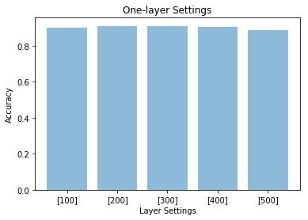

```python
# Create bar graph
plt.clf()
objects = ('[100]', '[200]', '[300]', '[400]', '[500]')
y_pos = np.arange(len(objects))
performance = [0.9,0.91,0.91,0.905,0.885]

plt.bar(y_pos, performance, align='center', alpha=0.5)
plt.xticks(y_pos, objects)
plt.xlabel('Layer Settings')
plt.ylabel('Accuracy')
plt.title('One-layer Settings')

plt.show()
plt.clf()
```

### Different 2-layer structures

```python
# Store accuracies
twolayer_acc = [0, 0, 0, 0, 0, 0, 0, 0]
```

Testing layer_1=100 performance:

**Setting 1 – (100) on 200**

```
hidden_layers_structure=[100, 200]
```

```python
twolayer_acc[0] = deep_belief_net(hidden_layers_structure=[100, 200])
```

```
[START] Pre-training step:
>> Epoch 1 finished 	RBM Reconstruction error 43.735626
>> Epoch 2 finished 	RBM Reconstruction error 69.860291
>> Epoch 3 finished 	RBM Reconstruction error 52.413918
>> Epoch 4 finished 	RBM Reconstruction error 61.957706
>> Epoch 5 finished 	RBM Reconstruction error 58.830509
>> Epoch 6 finished 	RBM Reconstruction error 55.932449
>> Epoch 7 finished 	RBM Reconstruction error 53.635048
>> Epoch 8 finished 	RBM Reconstruction error 79.695244
>> Epoch 9 finished 	RBM Reconstruction error 65.988762
>> Epoch 10 finished 	RBM Reconstruction error 81.554207
>> Epoch 1 finished 	RBM Reconstruction error 360.266235
>> Epoch 2 finished 	RBM Reconstruction error 431.059296
>> Epoch 3 finished 	RBM Reconstruction error 448.964172
>> Epoch 4 finished 	RBM Reconstruction error 555.941589
>> Epoch 5 finished 	RBM Reconstruction error 502.545776
>> Epoch 6 finished 	RBM Reconstruction error 604.778809
>> Epoch 7 finished 	RBM Reconstruction error 668.629089
>> Epoch 8 finished 	RBM Reconstruction error 631.405762
>> Epoch 9 finished 	RBM Reconstruction error 762.210938
>> Epoch 10 finished 	RBM Reconstruction error 780.738342
[END] Pre-training step
[START] Fine tuning step:
>> Epoch 0 finished 	ANN training loss 0.710166
>> Epoch 1 finished 	ANN training loss 0.513591
>> Epoch 2 finished 	ANN training loss 0.398980
>> Epoch 3 finished 	ANN training loss 0.339667
>> Epoch 4 finished 	ANN training loss 0.307840
>> Epoch 5 finished 	ANN training loss 0.261378
>> Epoch 6 finished 	ANN training loss 0.264133
>> Epoch 7 finished 	ANN training loss 0.238512
>> Epoch 8 finished 	ANN training loss 0.195845
>> Epoch 9 finished 	ANN training loss 0.176364
>> Epoch 10 finished 	ANN training loss 0.152304
>> Epoch 11 finished 	ANN training loss 0.137684
>> Epoch 12 finished 	ANN training loss 0.128414
>> Epoch 13 finished 	ANN training loss 0.117642
>> Epoch 14 finished 	ANN training loss 0.105372
>> Epoch 15 finished 	ANN training loss 0.103730
>> Epoch 16 finished 	ANN training loss 0.087785
```

[output cut: 71 more lines]

```
>> Epoch 88 finished 	ANN training loss 0.001671
>> Epoch 89 finished 	ANN training loss 0.002061
>> Epoch 90 finished 	ANN training loss 0.001710
>> Epoch 91 finished 	ANN training loss 0.002201
>> Epoch 92 finished 	ANN training loss 0.001971
>> Epoch 93 finished 	ANN training loss 0.002462
>> Epoch 94 finished 	ANN training loss 0.001763
>> Epoch 95 finished 	ANN training loss 0.001852
>> Epoch 96 finished 	ANN training loss 0.001465
>> Epoch 97 finished 	ANN training loss 0.001718
>> Epoch 98 finished 	ANN training loss 0.001340
>> Epoch 99 finished 	ANN training loss 0.001242
[END] Fine tuning step
Done.
Accuracy: 0.905000
```

```python
print('ACCURACY: ' + str(twolayer_acc[0]))
```

```
ACCURACY: 0.905
```

**Setting 2 – (100) on 500**

```
hidden_layers_structure=[100, 500]
```

```python
twolayer_acc[1] = deep_belief_net(hidden_layers_structure=[100, 500])
```

```
[START] Pre-training step:
>> Epoch 1 finished 	RBM Reconstruction error 77.752686
>> Epoch 2 finished 	RBM Reconstruction error 52.723736
>> Epoch 3 finished 	RBM Reconstruction error 53.163139
>> Epoch 4 finished 	RBM Reconstruction error 52.002865
>> Epoch 5 finished 	RBM Reconstruction error 67.212433
>> Epoch 6 finished 	RBM Reconstruction error 57.364613
>> Epoch 7 finished 	RBM Reconstruction error 70.963165
>> Epoch 8 finished 	RBM Reconstruction error 53.970383
>> Epoch 9 finished 	RBM Reconstruction error 76.276886
>> Epoch 10 finished 	RBM Reconstruction error 66.696815
>> Epoch 1 finished 	RBM Reconstruction error 142.798584
>> Epoch 2 finished 	RBM Reconstruction error 265.637207
>> Epoch 3 finished 	RBM Reconstruction error 189.706680
>> Epoch 4 finished 	RBM Reconstruction error 182.475662
>> Epoch 5 finished 	RBM Reconstruction error 246.715027
>> Epoch 6 finished 	RBM Reconstruction error 322.739990
>> Epoch 7 finished 	RBM Reconstruction error 283.961273
>> Epoch 8 finished 	RBM Reconstruction error 416.864136
>> Epoch 9 finished 	RBM Reconstruction error 503.759216
>> Epoch 10 finished 	RBM Reconstruction error 375.786560
[END] Pre-training step
[START] Fine tuning step:
>> Epoch 0 finished 	ANN training loss 0.725721
>> Epoch 1 finished 	ANN training loss 0.555961
>> Epoch 2 finished 	ANN training loss 0.455945
>> Epoch 3 finished 	ANN training loss 0.362099
>> Epoch 4 finished 	ANN training loss 0.304426
>> Epoch 5 finished 	ANN training loss 0.287528
>> Epoch 6 finished 	ANN training loss 0.266063
>> Epoch 7 finished 	ANN training loss 0.209929
>> Epoch 8 finished 	ANN training loss 0.197395
>> Epoch 9 finished 	ANN training loss 0.192417
>> Epoch 10 finished 	ANN training loss 0.157767
>> Epoch 11 finished 	ANN training loss 0.152469
>> Epoch 12 finished 	ANN training loss 0.123194
>> Epoch 13 finished 	ANN training loss 0.117787
>> Epoch 14 finished 	ANN training loss 0.103535
>> Epoch 15 finished 	ANN training loss 0.099334
>> Epoch 16 finished 	ANN training loss 0.088828
```

[output cut: 71 more lines]

```
>> Epoch 88 finished 	ANN training loss 0.002178
>> Epoch 89 finished 	ANN training loss 0.002332
>> Epoch 90 finished 	ANN training loss 0.002143
>> Epoch 91 finished 	ANN training loss 0.001624
>> Epoch 92 finished 	ANN training loss 0.001732
>> Epoch 93 finished 	ANN training loss 0.001514
>> Epoch 94 finished 	ANN training loss 0.001734
>> Epoch 95 finished 	ANN training loss 0.001677
>> Epoch 96 finished 	ANN training loss 0.001513
>> Epoch 97 finished 	ANN training loss 0.001382
>> Epoch 98 finished 	ANN training loss 0.001374
>> Epoch 99 finished 	ANN training loss 0.001510
[END] Fine tuning step
Done.
Accuracy: 0.920000
```

```python
print('ACCURACY: ' + str(twolayer_acc[1]))
```

```
ACCURACY: 0.92
```

Testing layer_1=500 performance:

**Setting 3 – (500) on 200**

```
hidden_layers_structure=[500, 200]
```

```python
twolayer_acc[2] = deep_belief_net(hidden_layers_structure=[500, 200])
```

```
[START] Pre-training step:
>> Epoch 1 finished 	RBM Reconstruction error 89.590607
>> Epoch 2 finished 	RBM Reconstruction error 37.799076
>> Epoch 3 finished 	RBM Reconstruction error 57.134327
>> Epoch 4 finished 	RBM Reconstruction error 54.106468
>> Epoch 5 finished 	RBM Reconstruction error 41.545689
>> Epoch 6 finished 	RBM Reconstruction error 28.666601
>> Epoch 7 finished 	RBM Reconstruction error 27.435949
>> Epoch 8 finished 	RBM Reconstruction error 40.246414
>> Epoch 9 finished 	RBM Reconstruction error 21.926275
>> Epoch 10 finished 	RBM Reconstruction error 33.239376
>> Epoch 1 finished 	RBM Reconstruction error 98.059181
>> Epoch 2 finished 	RBM Reconstruction error 174.640564
>> Epoch 3 finished 	RBM Reconstruction error 166.056488
>> Epoch 4 finished 	RBM Reconstruction error 173.509491
>> Epoch 5 finished 	RBM Reconstruction error 190.788391
>> Epoch 6 finished 	RBM Reconstruction error 228.330200
>> Epoch 7 finished 	RBM Reconstruction error 243.219604
>> Epoch 8 finished 	RBM Reconstruction error 243.815216
>> Epoch 9 finished 	RBM Reconstruction error 288.703979
>> Epoch 10 finished 	RBM Reconstruction error 325.087891
[END] Pre-training step
[START] Fine tuning step:
>> Epoch 0 finished 	ANN training loss 0.739812
>> Epoch 1 finished 	ANN training loss 0.454461
>> Epoch 2 finished 	ANN training loss 0.383898
>> Epoch 3 finished 	ANN training loss 0.338644
>> Epoch 4 finished 	ANN training loss 0.304319
>> Epoch 5 finished 	ANN training loss 0.244198
>> Epoch 6 finished 	ANN training loss 0.224944
>> Epoch 7 finished 	ANN training loss 0.199082
>> Epoch 8 finished 	ANN training loss 0.182059
>> Epoch 9 finished 	ANN training loss 0.151635
>> Epoch 10 finished 	ANN training loss 0.144171
>> Epoch 11 finished 	ANN training loss 0.115367
>> Epoch 12 finished 	ANN training loss 0.117670
>> Epoch 13 finished 	ANN training loss 0.121261
>> Epoch 14 finished 	ANN training loss 0.085923
>> Epoch 15 finished 	ANN training loss 0.075368
>> Epoch 16 finished 	ANN training loss 0.071203
```

[output cut: 71 more lines]

```
>> Epoch 88 finished 	ANN training loss 0.001089
>> Epoch 89 finished 	ANN training loss 0.001359
>> Epoch 90 finished 	ANN training loss 0.000992
>> Epoch 91 finished 	ANN training loss 0.001130
>> Epoch 92 finished 	ANN training loss 0.000978
>> Epoch 93 finished 	ANN training loss 0.000927
>> Epoch 94 finished 	ANN training loss 0.001100
>> Epoch 95 finished 	ANN training loss 0.000900
>> Epoch 96 finished 	ANN training loss 0.001113
>> Epoch 97 finished 	ANN training loss 0.000988
>> Epoch 98 finished 	ANN training loss 0.001640
>> Epoch 99 finished 	ANN training loss 0.001042
[END] Fine tuning step
Done.
Accuracy: 0.890000
```

```python
print('ACCURACY: ' + str(twolayer_acc[2]))
```

```
ACCURACY: 0.89
```

**Setting 4 – (500) on 500**

```
hidden_layers_structure=[500, 500]
```

```python
twolayer_acc[3] = deep_belief_net(hidden_layers_structure=[500, 500])
```

```
[START] Pre-training step:
>> Epoch 1 finished 	RBM Reconstruction error 46.529064
>> Epoch 2 finished 	RBM Reconstruction error 66.733582
>> Epoch 3 finished 	RBM Reconstruction error 51.008633
>> Epoch 4 finished 	RBM Reconstruction error 34.017078
>> Epoch 5 finished 	RBM Reconstruction error 30.529028
>> Epoch 6 finished 	RBM Reconstruction error 27.276186
>> Epoch 7 finished 	RBM Reconstruction error 28.727407
>> Epoch 8 finished 	RBM Reconstruction error 43.306202
>> Epoch 9 finished 	RBM Reconstruction error 33.214878
>> Epoch 10 finished 	RBM Reconstruction error 35.673023
>> Epoch 1 finished 	RBM Reconstruction error 113.897949
>> Epoch 2 finished 	RBM Reconstruction error 122.613113
>> Epoch 3 finished 	RBM Reconstruction error 76.815407
>> Epoch 4 finished 	RBM Reconstruction error 100.304230
>> Epoch 5 finished 	RBM Reconstruction error 176.164490
>> Epoch 6 finished 	RBM Reconstruction error 117.903763
>> Epoch 7 finished 	RBM Reconstruction error 118.125267
>> Epoch 8 finished 	RBM Reconstruction error 63.958897
>> Epoch 9 finished 	RBM Reconstruction error 135.292709
>> Epoch 10 finished 	RBM Reconstruction error 98.156700
[END] Pre-training step
[START] Fine tuning step:
>> Epoch 0 finished 	ANN training loss 0.678442
>> Epoch 1 finished 	ANN training loss 0.424808
>> Epoch 2 finished 	ANN training loss 0.375037
>> Epoch 3 finished 	ANN training loss 0.296220
>> Epoch 4 finished 	ANN training loss 0.246093
>> Epoch 5 finished 	ANN training loss 0.224821
>> Epoch 6 finished 	ANN training loss 0.198668
>> Epoch 7 finished 	ANN training loss 0.177970
>> Epoch 8 finished 	ANN training loss 0.159623
>> Epoch 9 finished 	ANN training loss 0.133888
>> Epoch 10 finished 	ANN training loss 0.128539
>> Epoch 11 finished 	ANN training loss 0.107228
>> Epoch 12 finished 	ANN training loss 0.100005
>> Epoch 13 finished 	ANN training loss 0.088832
>> Epoch 14 finished 	ANN training loss 0.082100
>> Epoch 15 finished 	ANN training loss 0.067345
>> Epoch 16 finished 	ANN training loss 0.059807
```

[output cut: 71 more lines]

```
>> Epoch 88 finished 	ANN training loss 0.000970
>> Epoch 89 finished 	ANN training loss 0.000958
>> Epoch 90 finished 	ANN training loss 0.001050
>> Epoch 91 finished 	ANN training loss 0.000907
>> Epoch 92 finished 	ANN training loss 0.001002
>> Epoch 93 finished 	ANN training loss 0.000934
>> Epoch 94 finished 	ANN training loss 0.000908
>> Epoch 95 finished 	ANN training loss 0.000919
>> Epoch 96 finished 	ANN training loss 0.000895
>> Epoch 97 finished 	ANN training loss 0.001143
>> Epoch 98 finished 	ANN training loss 0.001023
>> Epoch 99 finished 	ANN training loss 0.000763
[END] Fine tuning step
Done.
Accuracy: 0.890000
```

```python
print('ACCURACY: ' + str(twolayer_acc[3]))
```

```
ACCURACY: 0.89
```

```python
# Collated results
print(twolayer_acc)
print('Most accurate 2-layer setting is Setting ' + str(twolayer_acc.index(max(twolayer_acc)) + 1))
```

```
[0.90500000000000003, 0.92000000000000004, 0.89000000000000001, 0.89000000000000001, 0.90500000000000003, 0.89000000000000001, 0.92000000000000004, 0.89000000000000001]
Most accurate 2-layer setting is Setting 2
```

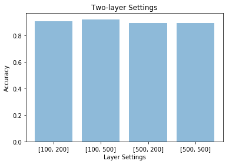

```python
# Create bar graph
plt.clf()
objects = ('[100, 200]', '[100, 500]', '[500, 200]', '[500, 500]')
y_pos = np.arange(len(objects))
performance = [0.905,0.92,0.89,0.89]

plt.bar(y_pos, performance, align='center', alpha=0.5)
plt.xticks(y_pos, objects)
plt.xlabel('Layer Settings')
plt.ylabel('Accuracy')
plt.title('Two-layer Settings')

plt.show()
plt.clf()
```

### Different 3-layer structures

```python
# Store accuracies
threelayer_acc = [0, 0, 0, 0, 0, 0, 0]
```

**Setting 1 – Baseline**

```
hidden_layers_structure=[100, 200, 300]
```

```python
threelayer_acc[0] = deep_belief_net(hidden_layers_structure=[100, 200, 300])
```

```
[START] Pre-training step:
>> Epoch 1 finished 	RBM Reconstruction error 48.776649
>> Epoch 2 finished 	RBM Reconstruction error 77.958260
>> Epoch 3 finished 	RBM Reconstruction error 96.530106
>> Epoch 4 finished 	RBM Reconstruction error 82.910736
>> Epoch 5 finished 	RBM Reconstruction error 116.125664
>> Epoch 6 finished 	RBM Reconstruction error 90.105782
>> Epoch 7 finished 	RBM Reconstruction error 66.176308
>> Epoch 8 finished 	RBM Reconstruction error 96.009384
>> Epoch 9 finished 	RBM Reconstruction error 87.633675
>> Epoch 10 finished 	RBM Reconstruction error 70.791771
>> Epoch 1 finished 	RBM Reconstruction error 247.282806
>> Epoch 2 finished 	RBM Reconstruction error 292.829712
>> Epoch 3 finished 	RBM Reconstruction error 302.180573
>> Epoch 4 finished 	RBM Reconstruction error 377.232025
>> Epoch 5 finished 	RBM Reconstruction error 518.424988
>> Epoch 6 finished 	RBM Reconstruction error 440.123657
>> Epoch 7 finished 	RBM Reconstruction error 448.164154
>> Epoch 8 finished 	RBM Reconstruction error 539.442139
>> Epoch 9 finished 	RBM Reconstruction error 556.956604
>> Epoch 10 finished 	RBM Reconstruction error 612.908630
>> Epoch 1 finished 	RBM Reconstruction error 18618.408203
>> Epoch 2 finished 	RBM Reconstruction error 17771.822266
>> Epoch 3 finished 	RBM Reconstruction error 16998.207031
>> Epoch 4 finished 	RBM Reconstruction error 21979.873047
>> Epoch 5 finished 	RBM Reconstruction error 27382.714844
>> Epoch 6 finished 	RBM Reconstruction error 39169.394531
>> Epoch 7 finished 	RBM Reconstruction error 44458.195312
>> Epoch 8 finished 	RBM Reconstruction error 41281.765625
>> Epoch 9 finished 	RBM Reconstruction error 48748.398438
>> Epoch 10 finished 	RBM Reconstruction error 37989.843750
[END] Pre-training step
[START] Fine tuning step:
>> Epoch 0 finished 	ANN training loss 1.048735
>> Epoch 1 finished 	ANN training loss 0.718359
>> Epoch 2 finished 	ANN training loss 0.557308
>> Epoch 3 finished 	ANN training loss 0.523559
>> Epoch 4 finished 	ANN training loss 0.390225
>> Epoch 5 finished 	ANN training loss 0.318191
>> Epoch 6 finished 	ANN training loss 0.276111
```

[output cut: 81 more lines]

```
>> Epoch 88 finished 	ANN training loss 0.000910
>> Epoch 89 finished 	ANN training loss 0.001506
>> Epoch 90 finished 	ANN training loss 0.001334
>> Epoch 91 finished 	ANN training loss 0.001055
>> Epoch 92 finished 	ANN training loss 0.000998
>> Epoch 93 finished 	ANN training loss 0.001161
>> Epoch 94 finished 	ANN training loss 0.001203
>> Epoch 95 finished 	ANN training loss 0.001659
>> Epoch 96 finished 	ANN training loss 0.000997
>> Epoch 97 finished 	ANN training loss 0.001004
>> Epoch 98 finished 	ANN training loss 0.001538
>> Epoch 99 finished 	ANN training loss 0.000857
[END] Fine tuning step
Done.
Accuracy: 0.900000
```

```python
print('ACCURACY: ' + str(threelayer_acc[0]))
```

```
ACCURACY: 0.9
```

**Setting 2 – 1st Layer = 500**

```
hidden_layers_structure=[500, 200, 300]
```

```python
threelayer_acc[1] = deep_belief_net(hidden_layers_structure=[500, 200, 300])
```

```
[START] Pre-training step:
>> Epoch 1 finished 	RBM Reconstruction error 57.344833
>> Epoch 2 finished 	RBM Reconstruction error 65.222092
>> Epoch 3 finished 	RBM Reconstruction error 36.743771
>> Epoch 4 finished 	RBM Reconstruction error 38.844582
>> Epoch 5 finished 	RBM Reconstruction error 44.889423
>> Epoch 6 finished 	RBM Reconstruction error 23.421108
>> Epoch 7 finished 	RBM Reconstruction error 30.931402
>> Epoch 8 finished 	RBM Reconstruction error 40.723019
>> Epoch 9 finished 	RBM Reconstruction error 30.118111
>> Epoch 10 finished 	RBM Reconstruction error 40.697941
>> Epoch 1 finished 	RBM Reconstruction error 281.745117
>> Epoch 2 finished 	RBM Reconstruction error 238.984146
>> Epoch 3 finished 	RBM Reconstruction error 232.955353
>> Epoch 4 finished 	RBM Reconstruction error 247.143829
>> Epoch 5 finished 	RBM Reconstruction error 279.849365
>> Epoch 6 finished 	RBM Reconstruction error 174.890121
>> Epoch 7 finished 	RBM Reconstruction error 195.232620
>> Epoch 8 finished 	RBM Reconstruction error 218.132187
>> Epoch 9 finished 	RBM Reconstruction error 241.617111
>> Epoch 10 finished 	RBM Reconstruction error 261.642883
>> Epoch 1 finished 	RBM Reconstruction error 2737.657471
>> Epoch 2 finished 	RBM Reconstruction error 3818.996338
>> Epoch 3 finished 	RBM Reconstruction error 5488.172363
>> Epoch 4 finished 	RBM Reconstruction error 5364.857422
>> Epoch 5 finished 	RBM Reconstruction error 7427.385742
>> Epoch 6 finished 	RBM Reconstruction error 8336.666992
>> Epoch 7 finished 	RBM Reconstruction error 10444.168945
>> Epoch 8 finished 	RBM Reconstruction error 11059.750977
>> Epoch 9 finished 	RBM Reconstruction error 9636.936523
>> Epoch 10 finished 	RBM Reconstruction error 11250.191406
[END] Pre-training step
[START] Fine tuning step:
>> Epoch 0 finished 	ANN training loss 0.703324
>> Epoch 1 finished 	ANN training loss 0.478931
>> Epoch 2 finished 	ANN training loss 0.396747
>> Epoch 3 finished 	ANN training loss 0.310771
>> Epoch 4 finished 	ANN training loss 0.271994
>> Epoch 5 finished 	ANN training loss 0.212138
>> Epoch 6 finished 	ANN training loss 0.169806
```

[output cut: 81 more lines]

```
>> Epoch 88 finished 	ANN training loss 0.000710
>> Epoch 89 finished 	ANN training loss 0.000895
>> Epoch 90 finished 	ANN training loss 0.000631
>> Epoch 91 finished 	ANN training loss 0.000354
>> Epoch 92 finished 	ANN training loss 0.000271
>> Epoch 93 finished 	ANN training loss 0.000350
>> Epoch 94 finished 	ANN training loss 0.000304
>> Epoch 95 finished 	ANN training loss 0.000320
>> Epoch 96 finished 	ANN training loss 0.000403
>> Epoch 97 finished 	ANN training loss 0.000309
>> Epoch 98 finished 	ANN training loss 0.000244
>> Epoch 99 finished 	ANN training loss 0.000229
[END] Fine tuning step
Done.
Accuracy: 0.925000
```

```python
print('ACCURACY: ' + str(threelayer_acc[1]))
```

```
ACCURACY: 0.925
```

**Setting 3 – 2nd Layer = 500**

```
hidden_layers_structure=[100, 500, 300]
```

```python
threelayer_acc[2] = deep_belief_net(hidden_layers_structure=[100, 500, 300])
```

```
[START] Pre-training step:
>> Epoch 1 finished 	RBM Reconstruction error 59.564102
>> Epoch 2 finished 	RBM Reconstruction error 59.761078
>> Epoch 3 finished 	RBM Reconstruction error 57.921844
>> Epoch 4 finished 	RBM Reconstruction error 46.745922
>> Epoch 5 finished 	RBM Reconstruction error 65.336388
>> Epoch 6 finished 	RBM Reconstruction error 107.946800
>> Epoch 7 finished 	RBM Reconstruction error 93.640976
>> Epoch 8 finished 	RBM Reconstruction error 101.977051
>> Epoch 9 finished 	RBM Reconstruction error 98.326408
>> Epoch 10 finished 	RBM Reconstruction error 103.741455
>> Epoch 1 finished 	RBM Reconstruction error 329.913818
>> Epoch 2 finished 	RBM Reconstruction error 587.393494
>> Epoch 3 finished 	RBM Reconstruction error 238.993225
>> Epoch 4 finished 	RBM Reconstruction error 555.764648
>> Epoch 5 finished 	RBM Reconstruction error 475.240692
>> Epoch 6 finished 	RBM Reconstruction error 475.708588
>> Epoch 7 finished 	RBM Reconstruction error 442.185699
>> Epoch 8 finished 	RBM Reconstruction error 499.192139
>> Epoch 9 finished 	RBM Reconstruction error 555.016052
>> Epoch 10 finished 	RBM Reconstruction error 750.540283
>> Epoch 1 finished 	RBM Reconstruction error 45197.039062
>> Epoch 2 finished 	RBM Reconstruction error 42511.648438
>> Epoch 3 finished 	RBM Reconstruction error 57938.121094
>> Epoch 4 finished 	RBM Reconstruction error 45343.339844
>> Epoch 5 finished 	RBM Reconstruction error 52561.078125
>> Epoch 6 finished 	RBM Reconstruction error 95396.632812
>> Epoch 7 finished 	RBM Reconstruction error 74806.039062
>> Epoch 8 finished 	RBM Reconstruction error 77988.851562
>> Epoch 9 finished 	RBM Reconstruction error 120865.539062
>> Epoch 10 finished 	RBM Reconstruction error 94011.882812
[END] Pre-training step
[START] Fine tuning step:
>> Epoch 0 finished 	ANN training loss 1.533851
>> Epoch 1 finished 	ANN training loss 1.276689
>> Epoch 2 finished 	ANN training loss 0.949397
>> Epoch 3 finished 	ANN training loss 0.714508
>> Epoch 4 finished 	ANN training loss 0.554281
>> Epoch 5 finished 	ANN training loss 0.477935
>> Epoch 6 finished 	ANN training loss 0.420389
```

[output cut: 81 more lines]

```
>> Epoch 88 finished 	ANN training loss 0.002168
>> Epoch 89 finished 	ANN training loss 0.002966
>> Epoch 90 finished 	ANN training loss 0.004537
>> Epoch 91 finished 	ANN training loss 0.003439
>> Epoch 92 finished 	ANN training loss 0.002118
>> Epoch 93 finished 	ANN training loss 0.002449
>> Epoch 94 finished 	ANN training loss 0.001787
>> Epoch 95 finished 	ANN training loss 0.001540
>> Epoch 96 finished 	ANN training loss 0.002248
>> Epoch 97 finished 	ANN training loss 0.001464
>> Epoch 98 finished 	ANN training loss 0.008587
>> Epoch 99 finished 	ANN training loss 0.004158
[END] Fine tuning step
Done.
Accuracy: 0.895000
```

```python
print('ACCURACY: ' + str(threelayer_acc[2]))
```

```
ACCURACY: 0.895
```

**Setting 4 – 3rd Layer = 500**

```
hidden_layers_structure=[100, 200, 500]
```

```python
threelayer_acc[3] = deep_belief_net(hidden_layers_structure=[100, 200, 500])
```

```
[START] Pre-training step:
>> Epoch 1 finished 	RBM Reconstruction error 75.150208
>> Epoch 2 finished 	RBM Reconstruction error 61.374603
>> Epoch 3 finished 	RBM Reconstruction error 64.751137
>> Epoch 4 finished 	RBM Reconstruction error 63.384277
>> Epoch 5 finished 	RBM Reconstruction error 54.535011
>> Epoch 6 finished 	RBM Reconstruction error 56.678871
>> Epoch 7 finished 	RBM Reconstruction error 75.155716
>> Epoch 8 finished 	RBM Reconstruction error 88.478317
>> Epoch 9 finished 	RBM Reconstruction error 77.702446
>> Epoch 10 finished 	RBM Reconstruction error 84.700813
>> Epoch 1 finished 	RBM Reconstruction error 577.839172
>> Epoch 2 finished 	RBM Reconstruction error 415.941925
>> Epoch 3 finished 	RBM Reconstruction error 600.284607
>> Epoch 4 finished 	RBM Reconstruction error 793.621643
>> Epoch 5 finished 	RBM Reconstruction error 637.713135
>> Epoch 6 finished 	RBM Reconstruction error 843.325439
>> Epoch 7 finished 	RBM Reconstruction error 760.770752
>> Epoch 8 finished 	RBM Reconstruction error 810.339233
>> Epoch 9 finished 	RBM Reconstruction error 955.818298
>> Epoch 10 finished 	RBM Reconstruction error 911.069092
>> Epoch 1 finished 	RBM Reconstruction error 11445.860352
>> Epoch 2 finished 	RBM Reconstruction error 25202.421875
>> Epoch 3 finished 	RBM Reconstruction error 37259.140625
>> Epoch 4 finished 	RBM Reconstruction error 39311.695312
>> Epoch 5 finished 	RBM Reconstruction error 40274.070312
>> Epoch 6 finished 	RBM Reconstruction error 59256.753906
>> Epoch 7 finished 	RBM Reconstruction error 59931.890625
>> Epoch 8 finished 	RBM Reconstruction error 61257.945312
>> Epoch 9 finished 	RBM Reconstruction error 54933.531250
>> Epoch 10 finished 	RBM Reconstruction error 63609.621094
[END] Pre-training step
[START] Fine tuning step:
>> Epoch 0 finished 	ANN training loss 1.258452
>> Epoch 1 finished 	ANN training loss 1.083188
>> Epoch 2 finished 	ANN training loss 0.613726
>> Epoch 3 finished 	ANN training loss 0.504612
>> Epoch 4 finished 	ANN training loss 0.415223
>> Epoch 5 finished 	ANN training loss 0.370487
>> Epoch 6 finished 	ANN training loss 0.348263
```

[output cut: 81 more lines]

```
>> Epoch 88 finished 	ANN training loss 0.001930
>> Epoch 89 finished 	ANN training loss 0.001422
>> Epoch 90 finished 	ANN training loss 0.001669
>> Epoch 91 finished 	ANN training loss 0.001492
>> Epoch 92 finished 	ANN training loss 0.001529
>> Epoch 93 finished 	ANN training loss 0.002800
>> Epoch 94 finished 	ANN training loss 0.002059
>> Epoch 95 finished 	ANN training loss 0.002790
>> Epoch 96 finished 	ANN training loss 0.001995
>> Epoch 97 finished 	ANN training loss 0.001121
>> Epoch 98 finished 	ANN training loss 0.000980
>> Epoch 99 finished 	ANN training loss 0.001216
[END] Fine tuning step
Done.
Accuracy: 0.870000
```

```python
print('ACCURACY: ' + str(threelayer_acc[3]))
```

```
ACCURACY: 0.87
```

**Setting 5 – 1st Layer = 500, 2nd Layer = 500**

```
hidden_layers_structure=[500, 500, 300]
```

```python
threelayer_acc[4] = deep_belief_net(hidden_layers_structure=[500, 500, 300])
```

```
[START] Pre-training step:
>> Epoch 1 finished 	RBM Reconstruction error 68.491608
>> Epoch 2 finished 	RBM Reconstruction error 56.644928
>> Epoch 3 finished 	RBM Reconstruction error 53.951054
>> Epoch 4 finished 	RBM Reconstruction error 44.317753
>> Epoch 5 finished 	RBM Reconstruction error 37.582027
>> Epoch 6 finished 	RBM Reconstruction error 26.515465
>> Epoch 7 finished 	RBM Reconstruction error 31.068565
>> Epoch 8 finished 	RBM Reconstruction error 28.296555
>> Epoch 9 finished 	RBM Reconstruction error 26.028257
>> Epoch 10 finished 	RBM Reconstruction error 25.418171
>> Epoch 1 finished 	RBM Reconstruction error 152.616257
>> Epoch 2 finished 	RBM Reconstruction error 63.525909
>> Epoch 3 finished 	RBM Reconstruction error 43.410030
>> Epoch 4 finished 	RBM Reconstruction error 52.196709
>> Epoch 5 finished 	RBM Reconstruction error 96.214417
>> Epoch 6 finished 	RBM Reconstruction error 58.725548
>> Epoch 7 finished 	RBM Reconstruction error 39.154755
>> Epoch 8 finished 	RBM Reconstruction error 90.772125
>> Epoch 9 finished 	RBM Reconstruction error 41.436943
>> Epoch 10 finished 	RBM Reconstruction error 65.333107
>> Epoch 1 finished 	RBM Reconstruction error 315.171967
>> Epoch 2 finished 	RBM Reconstruction error 704.780334
>> Epoch 3 finished 	RBM Reconstruction error 604.968628
>> Epoch 4 finished 	RBM Reconstruction error 875.380310
>> Epoch 5 finished 	RBM Reconstruction error 853.201416
>> Epoch 6 finished 	RBM Reconstruction error 839.794739
>> Epoch 7 finished 	RBM Reconstruction error 960.186707
>> Epoch 8 finished 	RBM Reconstruction error 959.082336
>> Epoch 9 finished 	RBM Reconstruction error 1235.092163
>> Epoch 10 finished 	RBM Reconstruction error 1277.223877
[END] Pre-training step
[START] Fine tuning step:
>> Epoch 0 finished 	ANN training loss 0.642280
>> Epoch 1 finished 	ANN training loss 0.512841
>> Epoch 2 finished 	ANN training loss 0.311047
>> Epoch 3 finished 	ANN training loss 0.261270
>> Epoch 4 finished 	ANN training loss 0.237309
>> Epoch 5 finished 	ANN training loss 0.194324
>> Epoch 6 finished 	ANN training loss 0.203730
```

[output cut: 81 more lines]

```
>> Epoch 88 finished 	ANN training loss 0.000510
>> Epoch 89 finished 	ANN training loss 0.000390
>> Epoch 90 finished 	ANN training loss 0.000425
>> Epoch 91 finished 	ANN training loss 0.000335
>> Epoch 92 finished 	ANN training loss 0.000317
>> Epoch 93 finished 	ANN training loss 0.000315
>> Epoch 94 finished 	ANN training loss 0.000415
>> Epoch 95 finished 	ANN training loss 0.000503
>> Epoch 96 finished 	ANN training loss 0.000396
>> Epoch 97 finished 	ANN training loss 0.000376
>> Epoch 98 finished 	ANN training loss 0.000273
>> Epoch 99 finished 	ANN training loss 0.000261
[END] Fine tuning step
Done.
Accuracy: 0.910000
```

```python
print('ACCURACY: ' + str(threelayer_acc[4]))
```

```
ACCURACY: 0.91
```

**Setting 6 – 1st Layer = 500, 3rd Layer = 500**

```
hidden_layers_structure=[500, 200, 500]
```

```python
threelayer_acc[5] = deep_belief_net(hidden_layers_structure=[500, 200, 500])
```

```
[START] Pre-training step:
>> Epoch 1 finished 	RBM Reconstruction error 78.036766
>> Epoch 2 finished 	RBM Reconstruction error 52.033066
>> Epoch 3 finished 	RBM Reconstruction error 32.189144
>> Epoch 4 finished 	RBM Reconstruction error 37.730347
>> Epoch 5 finished 	RBM Reconstruction error 38.358086
>> Epoch 6 finished 	RBM Reconstruction error 45.428146
>> Epoch 7 finished 	RBM Reconstruction error 39.048912
>> Epoch 8 finished 	RBM Reconstruction error 56.111622
>> Epoch 9 finished 	RBM Reconstruction error 23.523413
>> Epoch 10 finished 	RBM Reconstruction error 37.212223
>> Epoch 1 finished 	RBM Reconstruction error 123.392220
>> Epoch 2 finished 	RBM Reconstruction error 132.450577
>> Epoch 3 finished 	RBM Reconstruction error 221.457428
>> Epoch 4 finished 	RBM Reconstruction error 173.573120
>> Epoch 5 finished 	RBM Reconstruction error 181.331360
>> Epoch 6 finished 	RBM Reconstruction error 233.512924
>> Epoch 7 finished 	RBM Reconstruction error 192.164215
>> Epoch 8 finished 	RBM Reconstruction error 229.156311
>> Epoch 9 finished 	RBM Reconstruction error 271.157501
>> Epoch 10 finished 	RBM Reconstruction error 276.509216
>> Epoch 1 finished 	RBM Reconstruction error 1931.465210
>> Epoch 2 finished 	RBM Reconstruction error 3652.421631
>> Epoch 3 finished 	RBM Reconstruction error 4494.917969
>> Epoch 4 finished 	RBM Reconstruction error 5545.651855
>> Epoch 5 finished 	RBM Reconstruction error 4545.560547
>> Epoch 6 finished 	RBM Reconstruction error 4857.675781
>> Epoch 7 finished 	RBM Reconstruction error 5941.788574
>> Epoch 8 finished 	RBM Reconstruction error 6031.382324
>> Epoch 9 finished 	RBM Reconstruction error 5178.402344
>> Epoch 10 finished 	RBM Reconstruction error 6309.609863
[END] Pre-training step
[START] Fine tuning step:
>> Epoch 0 finished 	ANN training loss 0.713952
>> Epoch 1 finished 	ANN training loss 0.632705
>> Epoch 2 finished 	ANN training loss 0.366221
>> Epoch 3 finished 	ANN training loss 0.287641
>> Epoch 4 finished 	ANN training loss 0.274968
>> Epoch 5 finished 	ANN training loss 0.207943
>> Epoch 6 finished 	ANN training loss 0.183766
```

[output cut: 81 more lines]

```
>> Epoch 88 finished 	ANN training loss 0.000694
>> Epoch 89 finished 	ANN training loss 0.000495
>> Epoch 90 finished 	ANN training loss 0.000531
>> Epoch 91 finished 	ANN training loss 0.000385
>> Epoch 92 finished 	ANN training loss 0.000477
>> Epoch 93 finished 	ANN training loss 0.000299
>> Epoch 94 finished 	ANN training loss 0.001446
>> Epoch 95 finished 	ANN training loss 0.000973
>> Epoch 96 finished 	ANN training loss 0.000481
>> Epoch 97 finished 	ANN training loss 0.000551
>> Epoch 98 finished 	ANN training loss 0.000467
>> Epoch 99 finished 	ANN training loss 0.000395
[END] Fine tuning step
Done.
Accuracy: 0.875000
```

```python
print('ACCURACY: ' + str(threelayer_acc[5]))
```

```
ACCURACY: 0.875
```

**Setting 7 – 2nd Layer = 500, 3rd Layer = 500**

```
hidden_layers_structure=[100, 500, 500]
```

```python
threelayer_acc[6] = deep_belief_net(hidden_layers_structure=[100, 500, 500])
```

```
[START] Pre-training step:
>> Epoch 1 finished 	RBM Reconstruction error 82.229980
>> Epoch 2 finished 	RBM Reconstruction error 46.168163
>> Epoch 3 finished 	RBM Reconstruction error 51.044132
>> Epoch 4 finished 	RBM Reconstruction error 76.949280
>> Epoch 5 finished 	RBM Reconstruction error 87.207382
>> Epoch 6 finished 	RBM Reconstruction error 85.926399
>> Epoch 7 finished 	RBM Reconstruction error 81.613663
>> Epoch 8 finished 	RBM Reconstruction error 87.550720
>> Epoch 9 finished 	RBM Reconstruction error 112.198029
>> Epoch 10 finished 	RBM Reconstruction error 93.661072
>> Epoch 1 finished 	RBM Reconstruction error 303.795593
>> Epoch 2 finished 	RBM Reconstruction error 469.277771
>> Epoch 3 finished 	RBM Reconstruction error 314.409546
>> Epoch 4 finished 	RBM Reconstruction error 261.004852
>> Epoch 5 finished 	RBM Reconstruction error 333.697815
>> Epoch 6 finished 	RBM Reconstruction error 439.731628
>> Epoch 7 finished 	RBM Reconstruction error 470.187653
>> Epoch 8 finished 	RBM Reconstruction error 351.625122
>> Epoch 9 finished 	RBM Reconstruction error 363.454834
>> Epoch 10 finished 	RBM Reconstruction error 631.564026
>> Epoch 1 finished 	RBM Reconstruction error 28168.574219
>> Epoch 2 finished 	RBM Reconstruction error 18858.269531
>> Epoch 3 finished 	RBM Reconstruction error 21156.072266
>> Epoch 4 finished 	RBM Reconstruction error 24177.750000
>> Epoch 5 finished 	RBM Reconstruction error 40059.156250
>> Epoch 6 finished 	RBM Reconstruction error 48131.300781
>> Epoch 7 finished 	RBM Reconstruction error 62412.929688
>> Epoch 8 finished 	RBM Reconstruction error 79066.500000
>> Epoch 9 finished 	RBM Reconstruction error 71365.078125
>> Epoch 10 finished 	RBM Reconstruction error 86572.859375
[END] Pre-training step
[START] Fine tuning step:
>> Epoch 0 finished 	ANN training loss 1.422574
>> Epoch 1 finished 	ANN training loss 1.026839
>> Epoch 2 finished 	ANN training loss 0.847494
>> Epoch 3 finished 	ANN training loss 0.729024
>> Epoch 4 finished 	ANN training loss 0.589623
>> Epoch 5 finished 	ANN training loss 0.555054
>> Epoch 6 finished 	ANN training loss 0.436554
```

[output cut: 81 more lines]

```
>> Epoch 88 finished 	ANN training loss 0.004184
>> Epoch 89 finished 	ANN training loss 0.004218
>> Epoch 90 finished 	ANN training loss 0.003687
>> Epoch 91 finished 	ANN training loss 0.004417
>> Epoch 92 finished 	ANN training loss 0.004836
>> Epoch 93 finished 	ANN training loss 0.004638
>> Epoch 94 finished 	ANN training loss 0.004646
>> Epoch 95 finished 	ANN training loss 0.003542
>> Epoch 96 finished 	ANN training loss 0.005069
>> Epoch 97 finished 	ANN training loss 0.003526
>> Epoch 98 finished 	ANN training loss 0.003974
>> Epoch 99 finished 	ANN training loss 0.004375
[END] Fine tuning step
Done.
Accuracy: 0.870000
```

```python
print('ACCURACY: ' + str(threelayer_acc[6]))
```

```
ACCURACY: 0.87
```

```python
# Collated results
print(threelayer_acc)
print('Most accurate 3-layer setting is Setting ' + str(threelayer_acc.index(max(threelayer_acc)) + 1))
```

```
[0.90000000000000002, 0.92500000000000004, 0.89500000000000002, 0.87, 0.91000000000000003, 0.875, 0.87]
Most accurate 3-layer setting is Setting 2
```

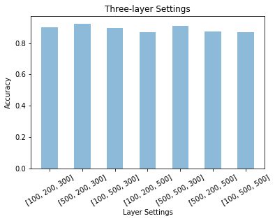

```python
# Create bar graph
plt.clf()
objects = ('[100, 200, 300]', '[500, 200, 300]', '[100, 500, 300]', '[100, 200, 500]', '[500, 500, 300]', '[500, 200, 500]', '[100, 500, 500]')
y_pos = np.arange(len(objects))
performance = [0.9,0.925,0.895,0.87, 0.91, 0.875, 0.87]

plt.bar(y_pos, performance, align='center', alpha=0.5, width=0.5)
plt.xticks(y_pos, objects, rotation=30)
plt.xlabel('Layer Settings')
plt.ylabel('Accuracy')
plt.title('Three-layer Settings')


plt.show()
plt.clf()
```

### Different Pre-training (RBM) Learning Rates:

```python
# Store accuracies
rbm_acc = [0, 0, 0, 0, 0]
```

**Setting 1**

```
learning_rate_rbm=0.01
```

```python
rbm_acc[0] = deep_belief_net(learning_rate_rbm=0.01)
```

```
[START] Pre-training step:
>> Epoch 1 finished 	RBM Reconstruction error 48.429943
>> Epoch 2 finished 	RBM Reconstruction error 44.728573
>> Epoch 3 finished 	RBM Reconstruction error 37.250076
>> Epoch 4 finished 	RBM Reconstruction error 31.907465
>> Epoch 5 finished 	RBM Reconstruction error 28.755913
>> Epoch 6 finished 	RBM Reconstruction error 26.740873
>> Epoch 7 finished 	RBM Reconstruction error 25.324945
>> Epoch 8 finished 	RBM Reconstruction error 23.896397
>> Epoch 9 finished 	RBM Reconstruction error 22.649555
>> Epoch 10 finished 	RBM Reconstruction error 21.804190
>> Epoch 1 finished 	RBM Reconstruction error 25.185154
>> Epoch 2 finished 	RBM Reconstruction error 18.686335
>> Epoch 3 finished 	RBM Reconstruction error 10.709770
>> Epoch 4 finished 	RBM Reconstruction error 7.455266
>> Epoch 5 finished 	RBM Reconstruction error 5.747530
>> Epoch 6 finished 	RBM Reconstruction error 4.696509
>> Epoch 7 finished 	RBM Reconstruction error 3.895706
>> Epoch 8 finished 	RBM Reconstruction error 3.339420
>> Epoch 9 finished 	RBM Reconstruction error 3.075150
>> Epoch 10 finished 	RBM Reconstruction error 2.861675
[END] Pre-training step
[START] Fine tuning step:
>> Epoch 0 finished 	ANN training loss 1.026684
>> Epoch 1 finished 	ANN training loss 0.738023
>> Epoch 2 finished 	ANN training loss 0.599452
>> Epoch 3 finished 	ANN training loss 0.489238
>> Epoch 4 finished 	ANN training loss 0.437557
>> Epoch 5 finished 	ANN training loss 0.374682
>> Epoch 6 finished 	ANN training loss 0.335208
>> Epoch 7 finished 	ANN training loss 0.306487
>> Epoch 8 finished 	ANN training loss 0.257842
>> Epoch 9 finished 	ANN training loss 0.245150
>> Epoch 10 finished 	ANN training loss 0.201488
>> Epoch 11 finished 	ANN training loss 0.204628
>> Epoch 12 finished 	ANN training loss 0.157771
>> Epoch 13 finished 	ANN training loss 0.138897
>> Epoch 14 finished 	ANN training loss 0.129000
>> Epoch 15 finished 	ANN training loss 0.123893
>> Epoch 16 finished 	ANN training loss 0.107592
```

[output cut: 71 more lines]

```
>> Epoch 88 finished 	ANN training loss 0.001290
>> Epoch 89 finished 	ANN training loss 0.001479
>> Epoch 90 finished 	ANN training loss 0.001209
>> Epoch 91 finished 	ANN training loss 0.001558
>> Epoch 92 finished 	ANN training loss 0.001149
>> Epoch 93 finished 	ANN training loss 0.001014
>> Epoch 94 finished 	ANN training loss 0.002997
>> Epoch 95 finished 	ANN training loss 0.001005
>> Epoch 96 finished 	ANN training loss 0.001130
>> Epoch 97 finished 	ANN training loss 0.001200
>> Epoch 98 finished 	ANN training loss 0.000986
>> Epoch 99 finished 	ANN training loss 0.000986
[END] Fine tuning step
Done.
Accuracy: 0.895000
```

```python
print('ACCURACY: ' + str(rbm_acc[0]))
```

```
ACCURACY: 0.895
```

**Setting 2**

```
learning_rate_rbm=0.05
```

```python
rbm_acc[1] = deep_belief_net(learning_rate_rbm=0.05)
```

```
[START] Pre-training step:
>> Epoch 1 finished 	RBM Reconstruction error 49.428436
>> Epoch 2 finished 	RBM Reconstruction error 38.784439
>> Epoch 3 finished 	RBM Reconstruction error 36.508812
>> Epoch 4 finished 	RBM Reconstruction error 32.487255
>> Epoch 5 finished 	RBM Reconstruction error 30.027876
>> Epoch 6 finished 	RBM Reconstruction error 27.512949
>> Epoch 7 finished 	RBM Reconstruction error 28.220713
>> Epoch 8 finished 	RBM Reconstruction error 36.800270
>> Epoch 9 finished 	RBM Reconstruction error 26.080055
>> Epoch 10 finished 	RBM Reconstruction error 27.156790
>> Epoch 1 finished 	RBM Reconstruction error 127.447762
>> Epoch 2 finished 	RBM Reconstruction error 60.762264
>> Epoch 3 finished 	RBM Reconstruction error 132.231400
>> Epoch 4 finished 	RBM Reconstruction error 136.848663
>> Epoch 5 finished 	RBM Reconstruction error 105.110397
>> Epoch 6 finished 	RBM Reconstruction error 122.694519
>> Epoch 7 finished 	RBM Reconstruction error 115.857346
>> Epoch 8 finished 	RBM Reconstruction error 184.296173
>> Epoch 9 finished 	RBM Reconstruction error 178.169037
>> Epoch 10 finished 	RBM Reconstruction error 167.853561
[END] Pre-training step
[START] Fine tuning step:
>> Epoch 0 finished 	ANN training loss 0.635793
>> Epoch 1 finished 	ANN training loss 0.481509
>> Epoch 2 finished 	ANN training loss 0.373607
>> Epoch 3 finished 	ANN training loss 0.311064
>> Epoch 4 finished 	ANN training loss 0.288711
>> Epoch 5 finished 	ANN training loss 0.226046
>> Epoch 6 finished 	ANN training loss 0.197164
>> Epoch 7 finished 	ANN training loss 0.192715
>> Epoch 8 finished 	ANN training loss 0.162547
>> Epoch 9 finished 	ANN training loss 0.137399
>> Epoch 10 finished 	ANN training loss 0.124895
>> Epoch 11 finished 	ANN training loss 0.106781
>> Epoch 12 finished 	ANN training loss 0.095121
>> Epoch 13 finished 	ANN training loss 0.085233
>> Epoch 14 finished 	ANN training loss 0.081535
>> Epoch 15 finished 	ANN training loss 0.063347
>> Epoch 16 finished 	ANN training loss 0.055384
```

[output cut: 71 more lines]

```
>> Epoch 88 finished 	ANN training loss 0.001029
>> Epoch 89 finished 	ANN training loss 0.001252
>> Epoch 90 finished 	ANN training loss 0.001041
>> Epoch 91 finished 	ANN training loss 0.001204
>> Epoch 92 finished 	ANN training loss 0.001129
>> Epoch 93 finished 	ANN training loss 0.001000
>> Epoch 94 finished 	ANN training loss 0.001000
>> Epoch 95 finished 	ANN training loss 0.000882
>> Epoch 96 finished 	ANN training loss 0.000831
>> Epoch 97 finished 	ANN training loss 0.000905
>> Epoch 98 finished 	ANN training loss 0.000854
>> Epoch 99 finished 	ANN training loss 0.000798
[END] Fine tuning step
Done.
Accuracy: 0.910000
```

```python
print('ACCURACY: ' + str(rbm_acc[1]))
```

```
ACCURACY: 0.91
```

**Setting 3**

```
learning_rate_rbm=0.1
```

```python
rbm_acc[2] = deep_belief_net(learning_rate_rbm=0.1)
```

```
[START] Pre-training step:
>> Epoch 1 finished 	RBM Reconstruction error 110.904007
>> Epoch 2 finished 	RBM Reconstruction error 125.835686
>> Epoch 3 finished 	RBM Reconstruction error 164.992279
>> Epoch 4 finished 	RBM Reconstruction error 136.079025
>> Epoch 5 finished 	RBM Reconstruction error 230.743042
>> Epoch 6 finished 	RBM Reconstruction error 214.991425
>> Epoch 7 finished 	RBM Reconstruction error 219.420624
>> Epoch 8 finished 	RBM Reconstruction error 186.010040
>> Epoch 9 finished 	RBM Reconstruction error 267.364807
>> Epoch 10 finished 	RBM Reconstruction error 164.378845
>> Epoch 1 finished 	RBM Reconstruction error 3380.159424
>> Epoch 2 finished 	RBM Reconstruction error 2683.055664
>> Epoch 3 finished 	RBM Reconstruction error 4320.045898
>> Epoch 4 finished 	RBM Reconstruction error 5420.953125
>> Epoch 5 finished 	RBM Reconstruction error 4888.116211
>> Epoch 6 finished 	RBM Reconstruction error 8385.436523
>> Epoch 7 finished 	RBM Reconstruction error 5375.637695
>> Epoch 8 finished 	RBM Reconstruction error 5713.787109
>> Epoch 9 finished 	RBM Reconstruction error 6178.853516
>> Epoch 10 finished 	RBM Reconstruction error 5392.146973
[END] Pre-training step
[START] Fine tuning step:
>> Epoch 0 finished 	ANN training loss 0.974992
>> Epoch 1 finished 	ANN training loss 0.661995
>> Epoch 2 finished 	ANN training loss 0.549957
>> Epoch 3 finished 	ANN training loss 0.470238
>> Epoch 4 finished 	ANN training loss 0.430156
>> Epoch 5 finished 	ANN training loss 0.356329
>> Epoch 6 finished 	ANN training loss 0.332026
>> Epoch 7 finished 	ANN training loss 0.296107
>> Epoch 8 finished 	ANN training loss 0.245873
>> Epoch 9 finished 	ANN training loss 0.238457
>> Epoch 10 finished 	ANN training loss 0.200607
>> Epoch 11 finished 	ANN training loss 0.197177
>> Epoch 12 finished 	ANN training loss 0.182111
>> Epoch 13 finished 	ANN training loss 0.160953
>> Epoch 14 finished 	ANN training loss 0.162905
>> Epoch 15 finished 	ANN training loss 0.161946
>> Epoch 16 finished 	ANN training loss 0.133252
```

[output cut: 71 more lines]

```
>> Epoch 88 finished 	ANN training loss 0.005004
>> Epoch 89 finished 	ANN training loss 0.004507
>> Epoch 90 finished 	ANN training loss 0.004008
>> Epoch 91 finished 	ANN training loss 0.004959
>> Epoch 92 finished 	ANN training loss 0.003502
>> Epoch 93 finished 	ANN training loss 0.003327
>> Epoch 94 finished 	ANN training loss 0.003738
>> Epoch 95 finished 	ANN training loss 0.003221
>> Epoch 96 finished 	ANN training loss 0.002786
>> Epoch 97 finished 	ANN training loss 0.002647
>> Epoch 98 finished 	ANN training loss 0.002955
>> Epoch 99 finished 	ANN training loss 0.002613
[END] Fine tuning step
Done.
Accuracy: 0.885000
```

```python
print('ACCURACY: ' + str(rbm_acc[2]))
```

```
ACCURACY: 0.885
```

**Setting 4**

```
learning_rate_rbm=0.5
```

```python
rbm_acc[3] = deep_belief_net(learning_rate_rbm=0.5)
```

```
[START] Pre-training step:
>> Epoch 1 finished 	RBM Reconstruction error 31779.625000
>> Epoch 2 finished 	RBM Reconstruction error 189873.421875
>> Epoch 3 finished 	RBM Reconstruction error 180143.687500
>> Epoch 4 finished 	RBM Reconstruction error 224904.078125
>> Epoch 5 finished 	RBM Reconstruction error 170434.359375
>> Epoch 6 finished 	RBM Reconstruction error 164641.656250
>> Epoch 7 finished 	RBM Reconstruction error 263771.000000
>> Epoch 8 finished 	RBM Reconstruction error 274975.156250
>> Epoch 9 finished 	RBM Reconstruction error 245861.359375
>> Epoch 10 finished 	RBM Reconstruction error 189474.312500
>> Epoch 1 finished 	RBM Reconstruction error 846481653760.000000
>> Epoch 2 finished 	RBM Reconstruction error 790017802240.000000
>> Epoch 3 finished 	RBM Reconstruction error 3146633969664.000000
>> Epoch 4 finished 	RBM Reconstruction error 2016595542016.000000
>> Epoch 5 finished 	RBM Reconstruction error 1990187155456.000000
>> Epoch 6 finished 	RBM Reconstruction error 983176052736.000000
>> Epoch 7 finished 	RBM Reconstruction error 2778203160576.000000
>> Epoch 8 finished 	RBM Reconstruction error 1564428730368.000000
>> Epoch 9 finished 	RBM Reconstruction error 2989057114112.000000
>> Epoch 10 finished 	RBM Reconstruction error 1582784708608.000000
[END] Pre-training step
[START] Fine tuning step:
>> Epoch 0 finished 	ANN training loss 2.300706
>> Epoch 1 finished 	ANN training loss 2.298146
>> Epoch 2 finished 	ANN training loss 2.293770
>> Epoch 3 finished 	ANN training loss 2.284529
>> Epoch 4 finished 	ANN training loss 2.262846
>> Epoch 5 finished 	ANN training loss 2.232202
>> Epoch 6 finished 	ANN training loss 2.208014
>> Epoch 7 finished 	ANN training loss 2.189869
>> Epoch 8 finished 	ANN training loss 2.179913
>> Epoch 9 finished 	ANN training loss 2.171853
>> Epoch 10 finished 	ANN training loss 2.166882
>> Epoch 11 finished 	ANN training loss 2.160546
>> Epoch 12 finished 	ANN training loss 2.154613
>> Epoch 13 finished 	ANN training loss 2.150535
>> Epoch 14 finished 	ANN training loss 2.142323
>> Epoch 15 finished 	ANN training loss 2.138678
>> Epoch 16 finished 	ANN training loss 2.133862
```

[output cut: 71 more lines]

```
>> Epoch 88 finished 	ANN training loss 0.871358
>> Epoch 89 finished 	ANN training loss 0.841526
>> Epoch 90 finished 	ANN training loss 0.862323
>> Epoch 91 finished 	ANN training loss 0.847701
>> Epoch 92 finished 	ANN training loss 0.840739
>> Epoch 93 finished 	ANN training loss 0.871223
>> Epoch 94 finished 	ANN training loss 0.849284
>> Epoch 95 finished 	ANN training loss 0.854567
>> Epoch 96 finished 	ANN training loss 0.837644
>> Epoch 97 finished 	ANN training loss 0.807640
>> Epoch 98 finished 	ANN training loss 0.855461
>> Epoch 99 finished 	ANN training loss 0.807312
[END] Fine tuning step
Done.
Accuracy: 0.595000
```

```python
print('ACCURACY: ' + str(rbm_acc[3]))
```

```
ACCURACY: 0.595
```

**Setting 5**

```
learning_rate_rbm=1.0
```

```python
rbm_acc[4] = deep_belief_net(learning_rate_rbm=1.0)
```

```
[START] Pre-training step:
>> Epoch 1 finished 	RBM Reconstruction error 22193574.000000
>> Epoch 2 finished 	RBM Reconstruction error 34716188.000000
>> Epoch 3 finished 	RBM Reconstruction error 30751990.000000
>> Epoch 4 finished 	RBM Reconstruction error 29281052.000000
>> Epoch 5 finished 	RBM Reconstruction error 18426390.000000
>> Epoch 6 finished 	RBM Reconstruction error 17048326.000000
>> Epoch 7 finished 	RBM Reconstruction error 24133926.000000
>> Epoch 8 finished 	RBM Reconstruction error 26676414.000000
>> Epoch 9 finished 	RBM Reconstruction error 26827366.000000
>> Epoch 10 finished 	RBM Reconstruction error 27220286.000000
>> Epoch 1 finished 	RBM Reconstruction error 2080750301580623872.000000
>> Epoch 2 finished 	RBM Reconstruction error 811598117131517952.000000
>> Epoch 3 finished 	RBM Reconstruction error 1798525045622964224.000000
>> Epoch 4 finished 	RBM Reconstruction error 3235358044707618816.000000
>> Epoch 5 finished 	RBM Reconstruction error 2510459099485831168.000000
>> Epoch 6 finished 	RBM Reconstruction error 2100549757217800192.000000
>> Epoch 7 finished 	RBM Reconstruction error 2453775701661188096.000000
>> Epoch 8 finished 	RBM Reconstruction error 3079025633179729920.000000
>> Epoch 9 finished 	RBM Reconstruction error 4631429398971547648.000000
>> Epoch 10 finished 	RBM Reconstruction error 2737053877441396736.000000
[END] Pre-training step
[START] Fine tuning step:
>> Epoch 0 finished 	ANN training loss 2.297242
>> Epoch 1 finished 	ANN training loss 2.274268
>> Epoch 2 finished 	ANN training loss 2.262210
>> Epoch 3 finished 	ANN training loss 2.240759
>> Epoch 4 finished 	ANN training loss 2.202708
>> Epoch 5 finished 	ANN training loss 2.157465
>> Epoch 6 finished 	ANN training loss 2.086788
>> Epoch 7 finished 	ANN training loss 2.038932
>> Epoch 8 finished 	ANN training loss 2.001882
>> Epoch 9 finished 	ANN training loss 1.974601
>> Epoch 10 finished 	ANN training loss 1.962472
>> Epoch 11 finished 	ANN training loss 1.934985
>> Epoch 12 finished 	ANN training loss 1.925109
>> Epoch 13 finished 	ANN training loss 1.917198
>> Epoch 14 finished 	ANN training loss 1.889538
>> Epoch 15 finished 	ANN training loss 1.873553
>> Epoch 16 finished 	ANN training loss 1.865580
```

[output cut: 71 more lines]

```
>> Epoch 88 finished 	ANN training loss 1.753308
>> Epoch 89 finished 	ANN training loss 1.743749
>> Epoch 90 finished 	ANN training loss 1.797779
>> Epoch 91 finished 	ANN training loss 1.681832
>> Epoch 92 finished 	ANN training loss 1.715062
>> Epoch 93 finished 	ANN training loss 1.711773
>> Epoch 94 finished 	ANN training loss 1.648828
>> Epoch 95 finished 	ANN training loss 1.763949
>> Epoch 96 finished 	ANN training loss 1.747831
>> Epoch 97 finished 	ANN training loss 1.678146
>> Epoch 98 finished 	ANN training loss 1.671631
>> Epoch 99 finished 	ANN training loss 1.641885
[END] Fine tuning step
Done.
Accuracy: 0.215000
```

```python
print('ACCURACY: ' + str(rbm_acc[4]))
```

```
ACCURACY: 0.215
```

```python
# Collated results
print(rbm_acc)
print('Most accurate rbm learning_rate setting is Setting ' + str(rbm_acc.index(max(rbm_acc)) + 1))
```

```
[0.89500000000000002, 0.91000000000000003, 0.88500000000000001, 0.59499999999999997, 0.215]
Most accurate rbm learning_rate setting is Setting 2
```

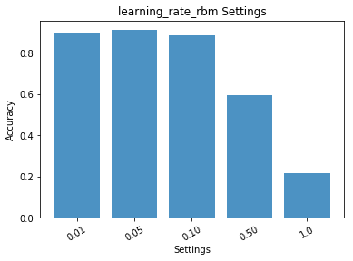

```python
# Create bar graph
plt.clf()
objects = ('0.01', '0.05', '0.10', '0.50', '1.0')
y_pos = np.arange(len(objects))
performance = [0.895,0.91,0.885,0.595, 0.215]

plt.bar(y_pos, performance, align='center', alpha=0.8)
plt.xticks(y_pos, objects, rotation=30)
plt.xlabel('Settings')
plt.ylabel('Accuracy')
plt.title('learning_rate_rbm Settings')

plt.show()
plt.clf()
```

### Different Learning Rates:

```python
# Store accuracies
learning_rate_acc = [0, 0, 0, 0, 0]
```

**Setting 1**

```
learning_rate=0.01
```

```python
learning_rate_acc[0] = deep_belief_net(learning_rate=0.01)
```

```
[START] Pre-training step:
>> Epoch 1 finished 	RBM Reconstruction error 80.508308
>> Epoch 2 finished 	RBM Reconstruction error 56.202160
>> Epoch 3 finished 	RBM Reconstruction error 76.771797
>> Epoch 4 finished 	RBM Reconstruction error 61.637432
>> Epoch 5 finished 	RBM Reconstruction error 73.832054
>> Epoch 6 finished 	RBM Reconstruction error 68.935799
>> Epoch 7 finished 	RBM Reconstruction error 89.181679
>> Epoch 8 finished 	RBM Reconstruction error 76.366074
>> Epoch 9 finished 	RBM Reconstruction error 89.140671
>> Epoch 10 finished 	RBM Reconstruction error 61.519100
>> Epoch 1 finished 	RBM Reconstruction error 143.703171
>> Epoch 2 finished 	RBM Reconstruction error 171.010208
>> Epoch 3 finished 	RBM Reconstruction error 214.397614
>> Epoch 4 finished 	RBM Reconstruction error 192.322067
>> Epoch 5 finished 	RBM Reconstruction error 199.107819
>> Epoch 6 finished 	RBM Reconstruction error 192.237610
>> Epoch 7 finished 	RBM Reconstruction error 207.964966
>> Epoch 8 finished 	RBM Reconstruction error 225.997635
>> Epoch 9 finished 	RBM Reconstruction error 222.943314
>> Epoch 10 finished 	RBM Reconstruction error 298.965149
[END] Pre-training step
[START] Fine tuning step:
>> Epoch 0 finished 	ANN training loss 1.605582
>> Epoch 1 finished 	ANN training loss 1.256691
>> Epoch 2 finished 	ANN training loss 1.041892
>> Epoch 3 finished 	ANN training loss 0.908176
>> Epoch 4 finished 	ANN training loss 0.817185
>> Epoch 5 finished 	ANN training loss 0.746655
>> Epoch 6 finished 	ANN training loss 0.692895
>> Epoch 7 finished 	ANN training loss 0.651748
>> Epoch 8 finished 	ANN training loss 0.615956
>> Epoch 9 finished 	ANN training loss 0.591655
>> Epoch 10 finished 	ANN training loss 0.563548
>> Epoch 11 finished 	ANN training loss 0.540059
>> Epoch 12 finished 	ANN training loss 0.524468
>> Epoch 13 finished 	ANN training loss 0.504133
>> Epoch 14 finished 	ANN training loss 0.490128
>> Epoch 15 finished 	ANN training loss 0.474626
>> Epoch 16 finished 	ANN training loss 0.467938
```

[output cut: 71 more lines]

```
>> Epoch 88 finished 	ANN training loss 0.165527
>> Epoch 89 finished 	ANN training loss 0.164152
>> Epoch 90 finished 	ANN training loss 0.163154
>> Epoch 91 finished 	ANN training loss 0.163119
>> Epoch 92 finished 	ANN training loss 0.159858
>> Epoch 93 finished 	ANN training loss 0.159550
>> Epoch 94 finished 	ANN training loss 0.156982
>> Epoch 95 finished 	ANN training loss 0.155653
>> Epoch 96 finished 	ANN training loss 0.154482
>> Epoch 97 finished 	ANN training loss 0.151421
>> Epoch 98 finished 	ANN training loss 0.148886
>> Epoch 99 finished 	ANN training loss 0.148983
[END] Fine tuning step
Done.
Accuracy: 0.885000
```

```python
print('ACCURACY: ' + str(learning_rate_acc[0]))
```

```
ACCURACY: 0.885
```

**Setting 2**

```
learning_rate=0.05
```

```python
learning_rate_acc[1] = deep_belief_net(learning_rate=0.05)
```

```
[START] Pre-training step:
>> Epoch 1 finished 	RBM Reconstruction error 81.708733
>> Epoch 2 finished 	RBM Reconstruction error 55.849056
>> Epoch 3 finished 	RBM Reconstruction error 48.589561
>> Epoch 4 finished 	RBM Reconstruction error 45.749756
>> Epoch 5 finished 	RBM Reconstruction error 44.211746
>> Epoch 6 finished 	RBM Reconstruction error 54.903095
>> Epoch 7 finished 	RBM Reconstruction error 42.353642
>> Epoch 8 finished 	RBM Reconstruction error 43.882450
>> Epoch 9 finished 	RBM Reconstruction error 59.503819
>> Epoch 10 finished 	RBM Reconstruction error 50.491993
>> Epoch 1 finished 	RBM Reconstruction error 222.933167
>> Epoch 2 finished 	RBM Reconstruction error 371.112885
>> Epoch 3 finished 	RBM Reconstruction error 420.357605
>> Epoch 4 finished 	RBM Reconstruction error 200.313187
>> Epoch 5 finished 	RBM Reconstruction error 319.664520
>> Epoch 6 finished 	RBM Reconstruction error 271.096985
>> Epoch 7 finished 	RBM Reconstruction error 297.548096
>> Epoch 8 finished 	RBM Reconstruction error 308.967896
>> Epoch 9 finished 	RBM Reconstruction error 279.965790
>> Epoch 10 finished 	RBM Reconstruction error 336.806732
[END] Pre-training step
[START] Fine tuning step:
>> Epoch 0 finished 	ANN training loss 0.832086
>> Epoch 1 finished 	ANN training loss 0.631094
>> Epoch 2 finished 	ANN training loss 0.499987
>> Epoch 3 finished 	ANN training loss 0.446935
>> Epoch 4 finished 	ANN training loss 0.380466
>> Epoch 5 finished 	ANN training loss 0.343083
>> Epoch 6 finished 	ANN training loss 0.327225
>> Epoch 7 finished 	ANN training loss 0.308603
>> Epoch 8 finished 	ANN training loss 0.269831
>> Epoch 9 finished 	ANN training loss 0.279059
>> Epoch 10 finished 	ANN training loss 0.245699
>> Epoch 11 finished 	ANN training loss 0.228884
>> Epoch 12 finished 	ANN training loss 0.221781
>> Epoch 13 finished 	ANN training loss 0.202035
>> Epoch 14 finished 	ANN training loss 0.191175
>> Epoch 15 finished 	ANN training loss 0.173313
>> Epoch 16 finished 	ANN training loss 0.170683
```

[output cut: 71 more lines]

```
>> Epoch 88 finished 	ANN training loss 0.007047
>> Epoch 89 finished 	ANN training loss 0.006941
>> Epoch 90 finished 	ANN training loss 0.006881
>> Epoch 91 finished 	ANN training loss 0.006879
>> Epoch 92 finished 	ANN training loss 0.006168
>> Epoch 93 finished 	ANN training loss 0.006342
>> Epoch 94 finished 	ANN training loss 0.006365
>> Epoch 95 finished 	ANN training loss 0.005720
>> Epoch 96 finished 	ANN training loss 0.005604
>> Epoch 97 finished 	ANN training loss 0.005754
>> Epoch 98 finished 	ANN training loss 0.005939
>> Epoch 99 finished 	ANN training loss 0.005114
[END] Fine tuning step
Done.
Accuracy: 0.895000
```

```python
print('ACCURACY: ' + str(learning_rate_acc[1]))
```

```
ACCURACY: 0.895
```

**Setting 3**

```
learning_rate=0.1
```

```python
learning_rate_acc[2] = deep_belief_net(learning_rate=0.1)
```

```
[START] Pre-training step:
>> Epoch 1 finished 	RBM Reconstruction error 69.982780
>> Epoch 2 finished 	RBM Reconstruction error 36.274624
>> Epoch 3 finished 	RBM Reconstruction error 28.071461
>> Epoch 4 finished 	RBM Reconstruction error 46.687866
>> Epoch 5 finished 	RBM Reconstruction error 21.562672
>> Epoch 6 finished 	RBM Reconstruction error 54.380157
>> Epoch 7 finished 	RBM Reconstruction error 31.012707
>> Epoch 8 finished 	RBM Reconstruction error 36.234512
>> Epoch 9 finished 	RBM Reconstruction error 40.408497
>> Epoch 10 finished 	RBM Reconstruction error 34.521046
>> Epoch 1 finished 	RBM Reconstruction error 232.677383
>> Epoch 2 finished 	RBM Reconstruction error 128.166565
>> Epoch 3 finished 	RBM Reconstruction error 133.991409
>> Epoch 4 finished 	RBM Reconstruction error 131.393631
>> Epoch 5 finished 	RBM Reconstruction error 141.272736
>> Epoch 6 finished 	RBM Reconstruction error 180.160980
>> Epoch 7 finished 	RBM Reconstruction error 186.990906
>> Epoch 8 finished 	RBM Reconstruction error 69.389183
>> Epoch 9 finished 	RBM Reconstruction error 124.187363
>> Epoch 10 finished 	RBM Reconstruction error 177.669907
[END] Pre-training step
[START] Fine tuning step:
>> Epoch 0 finished 	ANN training loss 0.635615
>> Epoch 1 finished 	ANN training loss 0.444051
>> Epoch 2 finished 	ANN training loss 0.358084
>> Epoch 3 finished 	ANN training loss 0.313933
>> Epoch 4 finished 	ANN training loss 0.280643
>> Epoch 5 finished 	ANN training loss 0.218436
>> Epoch 6 finished 	ANN training loss 0.206894
>> Epoch 7 finished 	ANN training loss 0.173023
>> Epoch 8 finished 	ANN training loss 0.158146
>> Epoch 9 finished 	ANN training loss 0.136123
>> Epoch 10 finished 	ANN training loss 0.120227
>> Epoch 11 finished 	ANN training loss 0.113445
>> Epoch 12 finished 	ANN training loss 0.105395
>> Epoch 13 finished 	ANN training loss 0.080144
>> Epoch 14 finished 	ANN training loss 0.076876
>> Epoch 15 finished 	ANN training loss 0.070847
>> Epoch 16 finished 	ANN training loss 0.060769
```

[output cut: 71 more lines]

```
>> Epoch 88 finished 	ANN training loss 0.001109
>> Epoch 89 finished 	ANN training loss 0.001122
>> Epoch 90 finished 	ANN training loss 0.000959
>> Epoch 91 finished 	ANN training loss 0.000929
>> Epoch 92 finished 	ANN training loss 0.000905
>> Epoch 93 finished 	ANN training loss 0.000796
>> Epoch 94 finished 	ANN training loss 0.000740
>> Epoch 95 finished 	ANN training loss 0.000660
>> Epoch 96 finished 	ANN training loss 0.000747
>> Epoch 97 finished 	ANN training loss 0.000708
>> Epoch 98 finished 	ANN training loss 0.000778
>> Epoch 99 finished 	ANN training loss 0.000611
[END] Fine tuning step
Done.
Accuracy: 0.915000
```

```python
print('ACCURACY: ' + str(learning_rate_acc[2]))
```

```
ACCURACY: 0.915
```

**Setting 4**

```
learning_rate=0.5
```

```python
learning_rate_acc[3] = deep_belief_net(learning_rate=0.5)
```

```
[START] Pre-training step:
>> Epoch 1 finished 	RBM Reconstruction error 79.112305
>> Epoch 2 finished 	RBM Reconstruction error 96.725349
>> Epoch 3 finished 	RBM Reconstruction error 51.052197
>> Epoch 4 finished 	RBM Reconstruction error 37.876381
>> Epoch 5 finished 	RBM Reconstruction error 47.518787
>> Epoch 6 finished 	RBM Reconstruction error 33.752762
>> Epoch 7 finished 	RBM Reconstruction error 48.474228
>> Epoch 8 finished 	RBM Reconstruction error 44.482853
>> Epoch 9 finished 	RBM Reconstruction error 37.027935
>> Epoch 10 finished 	RBM Reconstruction error 42.175068
>> Epoch 1 finished 	RBM Reconstruction error 133.939896
>> Epoch 2 finished 	RBM Reconstruction error 197.219604
>> Epoch 3 finished 	RBM Reconstruction error 240.424820
>> Epoch 4 finished 	RBM Reconstruction error 256.749054
>> Epoch 5 finished 	RBM Reconstruction error 258.981415
>> Epoch 6 finished 	RBM Reconstruction error 168.490448
>> Epoch 7 finished 	RBM Reconstruction error 153.094330
>> Epoch 8 finished 	RBM Reconstruction error 211.722504
>> Epoch 9 finished 	RBM Reconstruction error 189.015991
>> Epoch 10 finished 	RBM Reconstruction error 214.493042
[END] Pre-training step
[START] Fine tuning step:
>> Epoch 0 finished 	ANN training loss 0.592979
>> Epoch 1 finished 	ANN training loss 0.919712
>> Epoch 2 finished 	ANN training loss 0.269604
>> Epoch 3 finished 	ANN training loss 0.243406
>> Epoch 4 finished 	ANN training loss 0.144731
>> Epoch 5 finished 	ANN training loss 0.106821
>> Epoch 6 finished 	ANN training loss 0.155397
>> Epoch 7 finished 	ANN training loss 0.118717
>> Epoch 8 finished 	ANN training loss 0.066168
>> Epoch 9 finished 	ANN training loss 0.050119
>> Epoch 10 finished 	ANN training loss 0.055784
>> Epoch 11 finished 	ANN training loss 0.116684
>> Epoch 12 finished 	ANN training loss 0.018682
>> Epoch 13 finished 	ANN training loss 0.027114
>> Epoch 14 finished 	ANN training loss 0.038821
>> Epoch 15 finished 	ANN training loss 0.019516
>> Epoch 16 finished 	ANN training loss 0.043683
```

[output cut: 71 more lines]

```
>> Epoch 88 finished 	ANN training loss 0.000088
>> Epoch 89 finished 	ANN training loss 0.000945
>> Epoch 90 finished 	ANN training loss 0.000660
>> Epoch 91 finished 	ANN training loss 0.000056
>> Epoch 92 finished 	ANN training loss 0.000073
>> Epoch 93 finished 	ANN training loss 0.000320
>> Epoch 94 finished 	ANN training loss 0.000045
>> Epoch 95 finished 	ANN training loss 0.000358
>> Epoch 96 finished 	ANN training loss 0.000064
>> Epoch 97 finished 	ANN training loss 0.000205
>> Epoch 98 finished 	ANN training loss 0.000103
>> Epoch 99 finished 	ANN training loss 0.000056
[END] Fine tuning step
Done.
Accuracy: 0.895000
```

```python
print('ACCURACY: ' + str(learning_rate_acc[3]))
```

```
ACCURACY: 0.895
```

**Setting 5**

```
learning_rate=1.0
```

```python
learning_rate_acc[4] = deep_belief_net(learning_rate=1.0)
```

```
[START] Pre-training step:
>> Epoch 1 finished 	RBM Reconstruction error 76.779762
>> Epoch 2 finished 	RBM Reconstruction error 47.087139
>> Epoch 3 finished 	RBM Reconstruction error 59.271000
>> Epoch 4 finished 	RBM Reconstruction error 54.856850
>> Epoch 5 finished 	RBM Reconstruction error 72.953751
>> Epoch 6 finished 	RBM Reconstruction error 34.348270
>> Epoch 7 finished 	RBM Reconstruction error 50.360817
>> Epoch 8 finished 	RBM Reconstruction error 35.676952
>> Epoch 9 finished 	RBM Reconstruction error 40.834705
>> Epoch 10 finished 	RBM Reconstruction error 47.222740
>> Epoch 1 finished 	RBM Reconstruction error 266.484985
>> Epoch 2 finished 	RBM Reconstruction error 177.374817
>> Epoch 3 finished 	RBM Reconstruction error 254.176849
>> Epoch 4 finished 	RBM Reconstruction error 316.424438
>> Epoch 5 finished 	RBM Reconstruction error 188.242752
>> Epoch 6 finished 	RBM Reconstruction error 231.718887
>> Epoch 7 finished 	RBM Reconstruction error 162.049530
>> Epoch 8 finished 	RBM Reconstruction error 193.549850
>> Epoch 9 finished 	RBM Reconstruction error 268.331512
>> Epoch 10 finished 	RBM Reconstruction error 206.428787
[END] Pre-training step
[START] Fine tuning step:
>> Epoch 0 finished 	ANN training loss 1.864518
>> Epoch 1 finished 	ANN training loss 2.007123
>> Epoch 2 finished 	ANN training loss 1.281737
>> Epoch 3 finished 	ANN training loss 1.052272
>> Epoch 4 finished 	ANN training loss 0.871565
>> Epoch 5 finished 	ANN training loss 0.983157
>> Epoch 6 finished 	ANN training loss 0.714842
>> Epoch 7 finished 	ANN training loss 1.038296
>> Epoch 8 finished 	ANN training loss 1.266252
>> Epoch 9 finished 	ANN training loss 0.776818
>> Epoch 10 finished 	ANN training loss 0.741439
>> Epoch 11 finished 	ANN training loss 0.486001
>> Epoch 12 finished 	ANN training loss 0.419827
>> Epoch 13 finished 	ANN training loss 0.361042
>> Epoch 14 finished 	ANN training loss 0.367671
>> Epoch 15 finished 	ANN training loss 0.268364
>> Epoch 16 finished 	ANN training loss 0.405128
```

[output cut: 71 more lines]

```
>> Epoch 88 finished 	ANN training loss 0.025603
>> Epoch 89 finished 	ANN training loss 0.021756
>> Epoch 90 finished 	ANN training loss 0.021983
>> Epoch 91 finished 	ANN training loss 0.028638
>> Epoch 92 finished 	ANN training loss 0.026257
>> Epoch 93 finished 	ANN training loss 0.020985
>> Epoch 94 finished 	ANN training loss 0.024991
>> Epoch 95 finished 	ANN training loss 0.020566
>> Epoch 96 finished 	ANN training loss 0.032148
>> Epoch 97 finished 	ANN training loss 0.019458
>> Epoch 98 finished 	ANN training loss 0.029209
>> Epoch 99 finished 	ANN training loss 0.022101
[END] Fine tuning step
Done.
Accuracy: 0.875000
```

```python
print('ACCURACY: ' + str(learning_rate_acc[4]))
```

```
ACCURACY: 0.875
```

```python
# Collated results
print(learning_rate_acc)
print('Most accurate learning_rate setting is Setting ' + str(learning_rate_acc.index(max(learning_rate_acc)) + 1))
```

```
[0.88500000000000001, 0.89500000000000002, 0.91500000000000004, 0.89500000000000002, 0.875]
Most accurate learning_rate setting is Setting 3
```

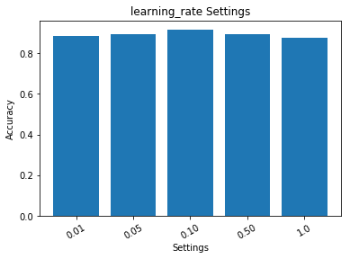

```python
# Create bar graph
plt.clf()
objects = ('0.01', '0.05', '0.10', '0.50', '1.0')
y_pos = np.arange(len(objects))
performance = [0.885,0.895,0.915,0.895, 0.875]

plt.bar(y_pos, performance, align='center', alpha=1.)
plt.xticks(y_pos, objects, rotation=30)
plt.xlabel('Settings')
plt.ylabel('Accuracy')
plt.title('learning_rate Settings')

plt.show()
plt.clf()
```

### Different Pre-training Lengths:

```python
# Store accuracies
epoch_rbm_acc = [0, 0, 0, 0, 0, 0, 0, 0, 0, 0]
```

**Setting 1**

```
n_epochs_rbm=1
```

```python
epoch_rbm_acc[0] = deep_belief_net(n_epochs_rbm=1)
```

```
[START] Pre-training step:
>> Epoch 1 finished 	RBM Reconstruction error 58.882492
>> Epoch 1 finished 	RBM Reconstruction error 278.842926
[END] Pre-training step
[START] Fine tuning step:
>> Epoch 0 finished 	ANN training loss 2.223761
>> Epoch 1 finished 	ANN training loss 2.037116
>> Epoch 2 finished 	ANN training loss 1.761922
>> Epoch 3 finished 	ANN training loss 1.454467
>> Epoch 4 finished 	ANN training loss 1.263631
>> Epoch 5 finished 	ANN training loss 1.113083
>> Epoch 6 finished 	ANN training loss 0.964771
>> Epoch 7 finished 	ANN training loss 0.840998
>> Epoch 8 finished 	ANN training loss 0.768864
>> Epoch 9 finished 	ANN training loss 0.729350
>> Epoch 10 finished 	ANN training loss 0.596092
>> Epoch 11 finished 	ANN training loss 0.531411
>> Epoch 12 finished 	ANN training loss 0.463428
>> Epoch 13 finished 	ANN training loss 0.412320
>> Epoch 14 finished 	ANN training loss 0.361198
>> Epoch 15 finished 	ANN training loss 0.324128
>> Epoch 16 finished 	ANN training loss 0.300418
>> Epoch 17 finished 	ANN training loss 0.270532
>> Epoch 18 finished 	ANN training loss 0.237967
>> Epoch 19 finished 	ANN training loss 0.242986
>> Epoch 20 finished 	ANN training loss 0.193844
>> Epoch 21 finished 	ANN training loss 0.189994
>> Epoch 22 finished 	ANN training loss 0.164269
>> Epoch 23 finished 	ANN training loss 0.170173
>> Epoch 24 finished 	ANN training loss 0.146996
>> Epoch 25 finished 	ANN training loss 0.128791
>> Epoch 26 finished 	ANN training loss 0.124010
>> Epoch 27 finished 	ANN training loss 0.115098
>> Epoch 28 finished 	ANN training loss 0.101233
>> Epoch 29 finished 	ANN training loss 0.084624
>> Epoch 30 finished 	ANN training loss 0.089629
>> Epoch 31 finished 	ANN training loss 0.079986
>> Epoch 32 finished 	ANN training loss 0.072556
>> Epoch 33 finished 	ANN training loss 0.071409
>> Epoch 34 finished 	ANN training loss 0.056656
```

[output cut: 53 more lines]

```
>> Epoch 88 finished 	ANN training loss 0.003155
>> Epoch 89 finished 	ANN training loss 0.003054
>> Epoch 90 finished 	ANN training loss 0.003835
>> Epoch 91 finished 	ANN training loss 0.003231
>> Epoch 92 finished 	ANN training loss 0.004185
>> Epoch 93 finished 	ANN training loss 0.002709
>> Epoch 94 finished 	ANN training loss 0.002217
>> Epoch 95 finished 	ANN training loss 0.002616
>> Epoch 96 finished 	ANN training loss 0.002371
>> Epoch 97 finished 	ANN training loss 0.002233
>> Epoch 98 finished 	ANN training loss 0.002299
>> Epoch 99 finished 	ANN training loss 0.002585
[END] Fine tuning step
Done.
Accuracy: 0.880000
```

```python
print('ACCURACY: ' + str(epoch_rbm_acc[0]))
```

```
ACCURACY: 0.88
```

**Setting 2**

```
n_epochs_rbm=2
```

```python
epoch_rbm_acc[1] = deep_belief_net(n_epochs_rbm=2)
```

```
[START] Pre-training step:
>> Epoch 1 finished 	RBM Reconstruction error 64.689949
>> Epoch 2 finished 	RBM Reconstruction error 59.904064
>> Epoch 1 finished 	RBM Reconstruction error 411.289185
>> Epoch 2 finished 	RBM Reconstruction error 575.223877
[END] Pre-training step
[START] Fine tuning step:
>> Epoch 0 finished 	ANN training loss 1.419303
>> Epoch 1 finished 	ANN training loss 1.063062
>> Epoch 2 finished 	ANN training loss 0.856164
>> Epoch 3 finished 	ANN training loss 0.754857
>> Epoch 4 finished 	ANN training loss 0.681133
>> Epoch 5 finished 	ANN training loss 0.563045
>> Epoch 6 finished 	ANN training loss 0.497078
>> Epoch 7 finished 	ANN training loss 0.439034
>> Epoch 8 finished 	ANN training loss 0.410330
>> Epoch 9 finished 	ANN training loss 0.372165
>> Epoch 10 finished 	ANN training loss 0.331818
>> Epoch 11 finished 	ANN training loss 0.277258
>> Epoch 12 finished 	ANN training loss 0.247271
>> Epoch 13 finished 	ANN training loss 0.233883
>> Epoch 14 finished 	ANN training loss 0.213489
>> Epoch 15 finished 	ANN training loss 0.200255
>> Epoch 16 finished 	ANN training loss 0.187413
>> Epoch 17 finished 	ANN training loss 0.151062
>> Epoch 18 finished 	ANN training loss 0.147466
>> Epoch 19 finished 	ANN training loss 0.132926
>> Epoch 20 finished 	ANN training loss 0.111680
>> Epoch 21 finished 	ANN training loss 0.102049
>> Epoch 22 finished 	ANN training loss 0.107214
>> Epoch 23 finished 	ANN training loss 0.087160
>> Epoch 24 finished 	ANN training loss 0.079395
>> Epoch 25 finished 	ANN training loss 0.067591
>> Epoch 26 finished 	ANN training loss 0.060134
>> Epoch 27 finished 	ANN training loss 0.060750
>> Epoch 28 finished 	ANN training loss 0.048710
>> Epoch 29 finished 	ANN training loss 0.043150
>> Epoch 30 finished 	ANN training loss 0.047188
>> Epoch 31 finished 	ANN training loss 0.040832
>> Epoch 32 finished 	ANN training loss 0.036856
```

[output cut: 55 more lines]

```
>> Epoch 88 finished 	ANN training loss 0.002292
>> Epoch 89 finished 	ANN training loss 0.002280
>> Epoch 90 finished 	ANN training loss 0.001784
>> Epoch 91 finished 	ANN training loss 0.001722
>> Epoch 92 finished 	ANN training loss 0.002249
>> Epoch 93 finished 	ANN training loss 0.001568
>> Epoch 94 finished 	ANN training loss 0.001680
>> Epoch 95 finished 	ANN training loss 0.001634
>> Epoch 96 finished 	ANN training loss 0.001589
>> Epoch 97 finished 	ANN training loss 0.002590
>> Epoch 98 finished 	ANN training loss 0.001645
>> Epoch 99 finished 	ANN training loss 0.001494
[END] Fine tuning step
Done.
Accuracy: 0.880000
```

```python
print('ACCURACY: ' + str(epoch_rbm_acc[1]))
```

```
ACCURACY: 0.88
```

**Setting 3**

```
n_epochs_rbm=5
```

```python
epoch_rbm_acc[2] = deep_belief_net(n_epochs_rbm=5)
```

```
[START] Pre-training step:
>> Epoch 1 finished 	RBM Reconstruction error 56.931183
>> Epoch 2 finished 	RBM Reconstruction error 77.546394
>> Epoch 3 finished 	RBM Reconstruction error 65.859505
>> Epoch 4 finished 	RBM Reconstruction error 51.727715
>> Epoch 5 finished 	RBM Reconstruction error 30.440014
>> Epoch 1 finished 	RBM Reconstruction error 59.351768
>> Epoch 2 finished 	RBM Reconstruction error 79.193237
>> Epoch 3 finished 	RBM Reconstruction error 44.656254
>> Epoch 4 finished 	RBM Reconstruction error 90.029076
>> Epoch 5 finished 	RBM Reconstruction error 60.892635
[END] Pre-training step
[START] Fine tuning step:
>> Epoch 0 finished 	ANN training loss 0.755383
>> Epoch 1 finished 	ANN training loss 0.544380
>> Epoch 2 finished 	ANN training loss 0.465932
>> Epoch 3 finished 	ANN training loss 0.375281
>> Epoch 4 finished 	ANN training loss 0.321060
>> Epoch 5 finished 	ANN training loss 0.283924
>> Epoch 6 finished 	ANN training loss 0.263247
>> Epoch 7 finished 	ANN training loss 0.250553
>> Epoch 8 finished 	ANN training loss 0.237075
>> Epoch 9 finished 	ANN training loss 0.180646
>> Epoch 10 finished 	ANN training loss 0.170824
>> Epoch 11 finished 	ANN training loss 0.146446
>> Epoch 12 finished 	ANN training loss 0.148486
>> Epoch 13 finished 	ANN training loss 0.121909
>> Epoch 14 finished 	ANN training loss 0.130320
>> Epoch 15 finished 	ANN training loss 0.101270
>> Epoch 16 finished 	ANN training loss 0.095869
>> Epoch 17 finished 	ANN training loss 0.081758
>> Epoch 18 finished 	ANN training loss 0.072612
>> Epoch 19 finished 	ANN training loss 0.066798
>> Epoch 20 finished 	ANN training loss 0.060896
>> Epoch 21 finished 	ANN training loss 0.052189
>> Epoch 22 finished 	ANN training loss 0.049018
>> Epoch 23 finished 	ANN training loss 0.047216
>> Epoch 24 finished 	ANN training loss 0.043193
>> Epoch 25 finished 	ANN training loss 0.037723
>> Epoch 26 finished 	ANN training loss 0.035975
```

[output cut: 61 more lines]

```
>> Epoch 88 finished 	ANN training loss 0.001813
>> Epoch 89 finished 	ANN training loss 0.001701
>> Epoch 90 finished 	ANN training loss 0.001782
>> Epoch 91 finished 	ANN training loss 0.001362
>> Epoch 92 finished 	ANN training loss 0.001288
>> Epoch 93 finished 	ANN training loss 0.001483
>> Epoch 94 finished 	ANN training loss 0.001155
>> Epoch 95 finished 	ANN training loss 0.001198
>> Epoch 96 finished 	ANN training loss 0.001290
>> Epoch 97 finished 	ANN training loss 0.001352
>> Epoch 98 finished 	ANN training loss 0.001136
>> Epoch 99 finished 	ANN training loss 0.001038
[END] Fine tuning step
Done.
Accuracy: 0.910000
```

```python
print('ACCURACY: ' + str(epoch_rbm_acc[2]))
```

```
ACCURACY: 0.91
```

**Setting 4 (Default)**

```
n_epochs_rbm=10
```

```python
epoch_rbm_acc[3] = default_acc
print('ACCURACY: ' + str(default_acc))
```

```
ACCURACY: 0.91
```

**Setting 5**

```
n_epochs_rbm=20
```

```python
epoch_rbm_acc[4] = deep_belief_net(n_epochs_rbm=20)
```

```
[START] Pre-training step:
>> Epoch 1 finished 	RBM Reconstruction error 56.427452
>> Epoch 2 finished 	RBM Reconstruction error 71.606277
>> Epoch 3 finished 	RBM Reconstruction error 55.203838
>> Epoch 4 finished 	RBM Reconstruction error 49.950108
>> Epoch 5 finished 	RBM Reconstruction error 43.959949
>> Epoch 6 finished 	RBM Reconstruction error 35.955669
>> Epoch 7 finished 	RBM Reconstruction error 31.652964
>> Epoch 8 finished 	RBM Reconstruction error 46.792759
>> Epoch 9 finished 	RBM Reconstruction error 32.297512
>> Epoch 10 finished 	RBM Reconstruction error 37.488388
>> Epoch 11 finished 	RBM Reconstruction error 35.783787
>> Epoch 12 finished 	RBM Reconstruction error 33.071846
>> Epoch 13 finished 	RBM Reconstruction error 42.293262
>> Epoch 14 finished 	RBM Reconstruction error 42.861328
>> Epoch 15 finished 	RBM Reconstruction error 44.246651
>> Epoch 16 finished 	RBM Reconstruction error 42.367062
>> Epoch 17 finished 	RBM Reconstruction error 45.918037
>> Epoch 18 finished 	RBM Reconstruction error 36.767139
>> Epoch 19 finished 	RBM Reconstruction error 39.103394
>> Epoch 20 finished 	RBM Reconstruction error 42.151669
>> Epoch 1 finished 	RBM Reconstruction error 187.944672
>> Epoch 2 finished 	RBM Reconstruction error 178.430161
>> Epoch 3 finished 	RBM Reconstruction error 161.261093
>> Epoch 4 finished 	RBM Reconstruction error 86.875801
>> Epoch 5 finished 	RBM Reconstruction error 153.360779
>> Epoch 6 finished 	RBM Reconstruction error 205.123718
>> Epoch 7 finished 	RBM Reconstruction error 179.342361
>> Epoch 8 finished 	RBM Reconstruction error 149.012955
>> Epoch 9 finished 	RBM Reconstruction error 172.777756
>> Epoch 10 finished 	RBM Reconstruction error 163.147797
>> Epoch 11 finished 	RBM Reconstruction error 161.883987
>> Epoch 12 finished 	RBM Reconstruction error 159.376404
>> Epoch 13 finished 	RBM Reconstruction error 194.027191
>> Epoch 14 finished 	RBM Reconstruction error 163.270905
>> Epoch 15 finished 	RBM Reconstruction error 144.504623
>> Epoch 16 finished 	RBM Reconstruction error 158.026321
>> Epoch 17 finished 	RBM Reconstruction error 147.669937
>> Epoch 18 finished 	RBM Reconstruction error 140.680222
>> Epoch 19 finished 	RBM Reconstruction error 137.220871
```

[output cut: 91 more lines]

```
>> Epoch 88 finished 	ANN training loss 0.001028
>> Epoch 89 finished 	ANN training loss 0.001123
>> Epoch 90 finished 	ANN training loss 0.001113
>> Epoch 91 finished 	ANN training loss 0.001308
>> Epoch 92 finished 	ANN training loss 0.001027
>> Epoch 93 finished 	ANN training loss 0.000953
>> Epoch 94 finished 	ANN training loss 0.000967
>> Epoch 95 finished 	ANN training loss 0.000763
>> Epoch 96 finished 	ANN training loss 0.000894
>> Epoch 97 finished 	ANN training loss 0.001017
>> Epoch 98 finished 	ANN training loss 0.000718
>> Epoch 99 finished 	ANN training loss 0.000792
[END] Fine tuning step
Done.
Accuracy: 0.905000
```

```python
print('ACCURACY: ' + str(epoch_rbm_acc[4]))
```

```
ACCURACY: 0.905
```

**Setting 6**

```
n_epochs_rbm=30
```

```python
epoch_rbm_acc[5] = deep_belief_net(n_epochs_rbm=30)
```

```
[START] Pre-training step:
>> Epoch 1 finished 	RBM Reconstruction error 92.470978
>> Epoch 2 finished 	RBM Reconstruction error 85.301331
>> Epoch 3 finished 	RBM Reconstruction error 42.295254
>> Epoch 4 finished 	RBM Reconstruction error 49.635422
>> Epoch 5 finished 	RBM Reconstruction error 35.004749
>> Epoch 6 finished 	RBM Reconstruction error 54.408066
>> Epoch 7 finished 	RBM Reconstruction error 28.305761
>> Epoch 8 finished 	RBM Reconstruction error 34.892990
>> Epoch 9 finished 	RBM Reconstruction error 29.667559
>> Epoch 10 finished 	RBM Reconstruction error 45.455029
>> Epoch 11 finished 	RBM Reconstruction error 37.146450
>> Epoch 12 finished 	RBM Reconstruction error 38.424442
>> Epoch 13 finished 	RBM Reconstruction error 23.905962
>> Epoch 14 finished 	RBM Reconstruction error 27.231716
>> Epoch 15 finished 	RBM Reconstruction error 36.267136
>> Epoch 16 finished 	RBM Reconstruction error 36.911022
>> Epoch 17 finished 	RBM Reconstruction error 29.398628
>> Epoch 18 finished 	RBM Reconstruction error 29.262503
>> Epoch 19 finished 	RBM Reconstruction error 60.107067
>> Epoch 20 finished 	RBM Reconstruction error 31.638620
>> Epoch 21 finished 	RBM Reconstruction error 47.515308
>> Epoch 22 finished 	RBM Reconstruction error 26.997276
>> Epoch 23 finished 	RBM Reconstruction error 41.345928
>> Epoch 24 finished 	RBM Reconstruction error 31.000488
>> Epoch 25 finished 	RBM Reconstruction error 28.862558
>> Epoch 26 finished 	RBM Reconstruction error 48.974628
>> Epoch 27 finished 	RBM Reconstruction error 26.598774
>> Epoch 28 finished 	RBM Reconstruction error 38.259293
>> Epoch 29 finished 	RBM Reconstruction error 32.167492
>> Epoch 30 finished 	RBM Reconstruction error 38.163063
>> Epoch 1 finished 	RBM Reconstruction error 156.527618
>> Epoch 2 finished 	RBM Reconstruction error 170.634262
>> Epoch 3 finished 	RBM Reconstruction error 131.709961
>> Epoch 4 finished 	RBM Reconstruction error 84.261086
>> Epoch 5 finished 	RBM Reconstruction error 110.089180
>> Epoch 6 finished 	RBM Reconstruction error 133.341827
>> Epoch 7 finished 	RBM Reconstruction error 149.274155
>> Epoch 8 finished 	RBM Reconstruction error 169.515671
>> Epoch 9 finished 	RBM Reconstruction error 162.134476
```

[output cut: 111 more lines]

```
>> Epoch 88 finished 	ANN training loss 0.001084
>> Epoch 89 finished 	ANN training loss 0.001132
>> Epoch 90 finished 	ANN training loss 0.001036
>> Epoch 91 finished 	ANN training loss 0.000937
>> Epoch 92 finished 	ANN training loss 0.000908
>> Epoch 93 finished 	ANN training loss 0.000818
>> Epoch 94 finished 	ANN training loss 0.000884
>> Epoch 95 finished 	ANN training loss 0.000947
>> Epoch 96 finished 	ANN training loss 0.000796
>> Epoch 97 finished 	ANN training loss 0.000713
>> Epoch 98 finished 	ANN training loss 0.001003
>> Epoch 99 finished 	ANN training loss 0.000714
[END] Fine tuning step
Done.
Accuracy: 0.920000
```

```python
print('ACCURACY: ' + str(epoch_rbm_acc[5]))
```

```
ACCURACY: 0.92
```

**Setting 7**

```
n_epochs_rbm=40
```

```python
epoch_rbm_acc[6] = deep_belief_net(n_epochs_rbm=40)
```

```
[START] Pre-training step:
>> Epoch 1 finished 	RBM Reconstruction error 43.358288
>> Epoch 2 finished 	RBM Reconstruction error 56.363575
>> Epoch 3 finished 	RBM Reconstruction error 53.744125
>> Epoch 4 finished 	RBM Reconstruction error 51.788158
>> Epoch 5 finished 	RBM Reconstruction error 38.050350
>> Epoch 6 finished 	RBM Reconstruction error 33.176849
>> Epoch 7 finished 	RBM Reconstruction error 34.224003
>> Epoch 8 finished 	RBM Reconstruction error 21.834377
>> Epoch 9 finished 	RBM Reconstruction error 45.354679
>> Epoch 10 finished 	RBM Reconstruction error 22.315962
>> Epoch 11 finished 	RBM Reconstruction error 35.863102
>> Epoch 12 finished 	RBM Reconstruction error 29.260483
>> Epoch 13 finished 	RBM Reconstruction error 27.823875
>> Epoch 14 finished 	RBM Reconstruction error 29.280943
>> Epoch 15 finished 	RBM Reconstruction error 21.086147
>> Epoch 16 finished 	RBM Reconstruction error 20.398621
>> Epoch 17 finished 	RBM Reconstruction error 48.363113
>> Epoch 18 finished 	RBM Reconstruction error 36.256248
>> Epoch 19 finished 	RBM Reconstruction error 23.029125
>> Epoch 20 finished 	RBM Reconstruction error 36.814152
>> Epoch 21 finished 	RBM Reconstruction error 28.656294
>> Epoch 22 finished 	RBM Reconstruction error 33.848091
>> Epoch 23 finished 	RBM Reconstruction error 23.485928
>> Epoch 24 finished 	RBM Reconstruction error 36.647797
>> Epoch 25 finished 	RBM Reconstruction error 40.407646
>> Epoch 26 finished 	RBM Reconstruction error 34.541111
>> Epoch 27 finished 	RBM Reconstruction error 41.327587
>> Epoch 28 finished 	RBM Reconstruction error 40.208481
>> Epoch 29 finished 	RBM Reconstruction error 28.690596
>> Epoch 30 finished 	RBM Reconstruction error 40.044468
>> Epoch 31 finished 	RBM Reconstruction error 34.405594
>> Epoch 32 finished 	RBM Reconstruction error 30.950840
>> Epoch 33 finished 	RBM Reconstruction error 33.167236
>> Epoch 34 finished 	RBM Reconstruction error 38.003414
>> Epoch 35 finished 	RBM Reconstruction error 42.338654
>> Epoch 36 finished 	RBM Reconstruction error 40.864254
>> Epoch 37 finished 	RBM Reconstruction error 41.628902
>> Epoch 38 finished 	RBM Reconstruction error 27.510088
>> Epoch 39 finished 	RBM Reconstruction error 30.467539
```

[output cut: 131 more lines]

```
>> Epoch 88 finished 	ANN training loss 0.000796
>> Epoch 89 finished 	ANN training loss 0.000785
>> Epoch 90 finished 	ANN training loss 0.000735
>> Epoch 91 finished 	ANN training loss 0.000766
>> Epoch 92 finished 	ANN training loss 0.000729
>> Epoch 93 finished 	ANN training loss 0.000678
>> Epoch 94 finished 	ANN training loss 0.000698
>> Epoch 95 finished 	ANN training loss 0.000730
>> Epoch 96 finished 	ANN training loss 0.000700
>> Epoch 97 finished 	ANN training loss 0.000633
>> Epoch 98 finished 	ANN training loss 0.000574
>> Epoch 99 finished 	ANN training loss 0.000587
[END] Fine tuning step
Done.
Accuracy: 0.930000
```

```python
print('ACCURACY: ' + str(epoch_rbm_acc[6]))
```

```
ACCURACY: 0.93
```

**Setting 8**

```
n_epochs_rbm=50
```

```python
epoch_rbm_acc[7] = deep_belief_net(n_epochs_rbm=50)
```

```
[START] Pre-training step:
>> Epoch 1 finished 	RBM Reconstruction error 54.985214
>> Epoch 2 finished 	RBM Reconstruction error 62.096172
>> Epoch 3 finished 	RBM Reconstruction error 45.251816
>> Epoch 4 finished 	RBM Reconstruction error 43.081493
>> Epoch 5 finished 	RBM Reconstruction error 29.928345
>> Epoch 6 finished 	RBM Reconstruction error 28.466885
>> Epoch 7 finished 	RBM Reconstruction error 36.912857
>> Epoch 8 finished 	RBM Reconstruction error 45.177746
>> Epoch 9 finished 	RBM Reconstruction error 49.283730
>> Epoch 10 finished 	RBM Reconstruction error 46.618320
>> Epoch 11 finished 	RBM Reconstruction error 35.642426
>> Epoch 12 finished 	RBM Reconstruction error 30.457457
>> Epoch 13 finished 	RBM Reconstruction error 31.268808
>> Epoch 14 finished 	RBM Reconstruction error 45.809601
>> Epoch 15 finished 	RBM Reconstruction error 44.016468
>> Epoch 16 finished 	RBM Reconstruction error 31.719570
>> Epoch 17 finished 	RBM Reconstruction error 33.370472
>> Epoch 18 finished 	RBM Reconstruction error 40.761951
>> Epoch 19 finished 	RBM Reconstruction error 31.600405
>> Epoch 20 finished 	RBM Reconstruction error 32.468315
>> Epoch 21 finished 	RBM Reconstruction error 31.679224
>> Epoch 22 finished 	RBM Reconstruction error 32.492111
>> Epoch 23 finished 	RBM Reconstruction error 35.449799
>> Epoch 24 finished 	RBM Reconstruction error 43.675613
>> Epoch 25 finished 	RBM Reconstruction error 33.906666
>> Epoch 26 finished 	RBM Reconstruction error 40.161636
>> Epoch 27 finished 	RBM Reconstruction error 28.779116
>> Epoch 28 finished 	RBM Reconstruction error 34.979935
>> Epoch 29 finished 	RBM Reconstruction error 28.730215
>> Epoch 30 finished 	RBM Reconstruction error 31.814503
>> Epoch 31 finished 	RBM Reconstruction error 42.189648
>> Epoch 32 finished 	RBM Reconstruction error 35.736607
>> Epoch 33 finished 	RBM Reconstruction error 36.740726
>> Epoch 34 finished 	RBM Reconstruction error 30.774963
>> Epoch 35 finished 	RBM Reconstruction error 38.731300
>> Epoch 36 finished 	RBM Reconstruction error 36.828842
>> Epoch 37 finished 	RBM Reconstruction error 40.284721
>> Epoch 38 finished 	RBM Reconstruction error 33.431606
>> Epoch 39 finished 	RBM Reconstruction error 53.262314
```

[output cut: 151 more lines]

```
>> Epoch 88 finished 	ANN training loss 0.000949
>> Epoch 89 finished 	ANN training loss 0.000939
>> Epoch 90 finished 	ANN training loss 0.000887
>> Epoch 91 finished 	ANN training loss 0.000964
>> Epoch 92 finished 	ANN training loss 0.000898
>> Epoch 93 finished 	ANN training loss 0.000889
>> Epoch 94 finished 	ANN training loss 0.000803
>> Epoch 95 finished 	ANN training loss 0.000858
>> Epoch 96 finished 	ANN training loss 0.000817
>> Epoch 97 finished 	ANN training loss 0.000752
>> Epoch 98 finished 	ANN training loss 0.000755
>> Epoch 99 finished 	ANN training loss 0.000734
[END] Fine tuning step
Done.
Accuracy: 0.900000
```

```python
print('ACCURACY: ' + str(epoch_rbm_acc[7]))
```

```
ACCURACY: 0.9
```

**Setting 9**

```
n_epochs_rbm=100
```

```python
epoch_rbm_acc[8] = deep_belief_net(n_epochs_rbm=100)
```

```
[START] Pre-training step:
>> Epoch 1 finished 	RBM Reconstruction error 102.369392
>> Epoch 2 finished 	RBM Reconstruction error 39.580040
>> Epoch 3 finished 	RBM Reconstruction error 58.195435
>> Epoch 4 finished 	RBM Reconstruction error 42.953144
>> Epoch 5 finished 	RBM Reconstruction error 30.074026
>> Epoch 6 finished 	RBM Reconstruction error 25.546534
>> Epoch 7 finished 	RBM Reconstruction error 32.715004
>> Epoch 8 finished 	RBM Reconstruction error 28.658079
>> Epoch 9 finished 	RBM Reconstruction error 27.248291
>> Epoch 10 finished 	RBM Reconstruction error 21.905323
>> Epoch 11 finished 	RBM Reconstruction error 20.972374
>> Epoch 12 finished 	RBM Reconstruction error 30.766115
>> Epoch 13 finished 	RBM Reconstruction error 43.735683
>> Epoch 14 finished 	RBM Reconstruction error 27.307983
>> Epoch 15 finished 	RBM Reconstruction error 33.528534
>> Epoch 16 finished 	RBM Reconstruction error 18.731007
>> Epoch 17 finished 	RBM Reconstruction error 27.331324
>> Epoch 18 finished 	RBM Reconstruction error 38.402706
>> Epoch 19 finished 	RBM Reconstruction error 29.862865
>> Epoch 20 finished 	RBM Reconstruction error 40.268932
>> Epoch 21 finished 	RBM Reconstruction error 32.184887
>> Epoch 22 finished 	RBM Reconstruction error 39.825115
>> Epoch 23 finished 	RBM Reconstruction error 26.806177
>> Epoch 24 finished 	RBM Reconstruction error 29.430204
>> Epoch 25 finished 	RBM Reconstruction error 23.967192
>> Epoch 26 finished 	RBM Reconstruction error 23.805079
>> Epoch 27 finished 	RBM Reconstruction error 34.138329
>> Epoch 28 finished 	RBM Reconstruction error 36.367519
>> Epoch 29 finished 	RBM Reconstruction error 32.880257
>> Epoch 30 finished 	RBM Reconstruction error 43.483456
>> Epoch 31 finished 	RBM Reconstruction error 27.266542
>> Epoch 32 finished 	RBM Reconstruction error 29.320518
>> Epoch 33 finished 	RBM Reconstruction error 37.196865
>> Epoch 34 finished 	RBM Reconstruction error 27.303625
>> Epoch 35 finished 	RBM Reconstruction error 26.077913
>> Epoch 36 finished 	RBM Reconstruction error 50.016006
>> Epoch 37 finished 	RBM Reconstruction error 27.148087
>> Epoch 38 finished 	RBM Reconstruction error 23.290499
>> Epoch 39 finished 	RBM Reconstruction error 32.554523
```

[output cut: 251 more lines]

```
>> Epoch 88 finished 	ANN training loss 0.000686
>> Epoch 89 finished 	ANN training loss 0.000714
>> Epoch 90 finished 	ANN training loss 0.000649
>> Epoch 91 finished 	ANN training loss 0.000681
>> Epoch 92 finished 	ANN training loss 0.000651
>> Epoch 93 finished 	ANN training loss 0.000573
>> Epoch 94 finished 	ANN training loss 0.000613
>> Epoch 95 finished 	ANN training loss 0.000744
>> Epoch 96 finished 	ANN training loss 0.000732
>> Epoch 97 finished 	ANN training loss 0.000748
>> Epoch 98 finished 	ANN training loss 0.000601
>> Epoch 99 finished 	ANN training loss 0.000600
[END] Fine tuning step
Done.
Accuracy: 0.900000
```

```python
print('ACCURACY: ' + str(epoch_rbm_acc[8]))
```

```
ACCURACY: 0.9
```

**Setting 10**

```
n_epochs_rbm=200
```

```python
epoch_rbm_acc[9] = deep_belief_net(n_epochs_rbm=200)
```

```
[START] Pre-training step:
>> Epoch 1 finished 	RBM Reconstruction error 57.116241
>> Epoch 2 finished 	RBM Reconstruction error 58.623379
>> Epoch 3 finished 	RBM Reconstruction error 47.995167
>> Epoch 4 finished 	RBM Reconstruction error 46.244217
>> Epoch 5 finished 	RBM Reconstruction error 58.939911
>> Epoch 6 finished 	RBM Reconstruction error 44.408817
>> Epoch 7 finished 	RBM Reconstruction error 42.027470
>> Epoch 8 finished 	RBM Reconstruction error 43.308262
>> Epoch 9 finished 	RBM Reconstruction error 32.640736
>> Epoch 10 finished 	RBM Reconstruction error 24.688789
>> Epoch 11 finished 	RBM Reconstruction error 36.358410
>> Epoch 12 finished 	RBM Reconstruction error 29.182411
>> Epoch 13 finished 	RBM Reconstruction error 33.299675
>> Epoch 14 finished 	RBM Reconstruction error 27.233667
>> Epoch 15 finished 	RBM Reconstruction error 53.459248
>> Epoch 16 finished 	RBM Reconstruction error 37.537029
>> Epoch 17 finished 	RBM Reconstruction error 31.129135
>> Epoch 18 finished 	RBM Reconstruction error 30.803146
>> Epoch 19 finished 	RBM Reconstruction error 38.337326
>> Epoch 20 finished 	RBM Reconstruction error 38.912827
>> Epoch 21 finished 	RBM Reconstruction error 31.926487
>> Epoch 22 finished 	RBM Reconstruction error 45.075577
>> Epoch 23 finished 	RBM Reconstruction error 36.450039
>> Epoch 24 finished 	RBM Reconstruction error 45.967323
>> Epoch 25 finished 	RBM Reconstruction error 40.121899
>> Epoch 26 finished 	RBM Reconstruction error 45.008419
>> Epoch 27 finished 	RBM Reconstruction error 44.445240
>> Epoch 28 finished 	RBM Reconstruction error 41.197735
>> Epoch 29 finished 	RBM Reconstruction error 38.312874
>> Epoch 30 finished 	RBM Reconstruction error 32.829533
>> Epoch 31 finished 	RBM Reconstruction error 30.037983
>> Epoch 32 finished 	RBM Reconstruction error 37.973209
>> Epoch 33 finished 	RBM Reconstruction error 40.791405
>> Epoch 34 finished 	RBM Reconstruction error 35.718197
>> Epoch 35 finished 	RBM Reconstruction error 25.079138
>> Epoch 36 finished 	RBM Reconstruction error 50.273823
>> Epoch 37 finished 	RBM Reconstruction error 33.513794
>> Epoch 38 finished 	RBM Reconstruction error 37.381702
>> Epoch 39 finished 	RBM Reconstruction error 39.995655
```

[output cut: 451 more lines]

```
>> Epoch 88 finished 	ANN training loss 0.001001
>> Epoch 89 finished 	ANN training loss 0.000905
>> Epoch 90 finished 	ANN training loss 0.000852
>> Epoch 91 finished 	ANN training loss 0.000830
>> Epoch 92 finished 	ANN training loss 0.000839
>> Epoch 93 finished 	ANN training loss 0.000802
>> Epoch 94 finished 	ANN training loss 0.000783
>> Epoch 95 finished 	ANN training loss 0.000803
>> Epoch 96 finished 	ANN training loss 0.000765
>> Epoch 97 finished 	ANN training loss 0.000748
>> Epoch 98 finished 	ANN training loss 0.000769
>> Epoch 99 finished 	ANN training loss 0.000660
[END] Fine tuning step
Done.
Accuracy: 0.890000
```

```python
print('ACCURACY: ' + str(epoch_rbm_acc[9]))
```

```
ACCURACY: 0.89
```

```python
# Collated results
print(epoch_rbm_acc)
print('Most accurate n_epochs_rbm setting is Setting ' + str(epoch_rbm_acc.index(max(epoch_rbm_acc)) + 1))
```

```
[0.88, 0.88, 0.91000000000000003, 0.91000000000000003, 0.90500000000000003, 0.92000000000000004, 0.93000000000000005, 0.90000000000000002, 0.90000000000000002, 0.89000000000000001]
Most accurate n_epochs_rbm setting is Setting 7
```

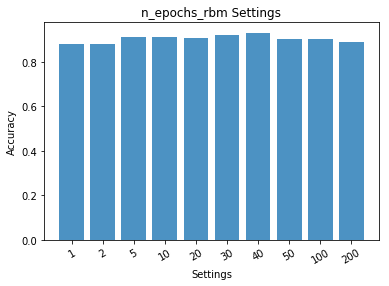

```python
# Create bar graph
plt.clf()
objects = ('1', '2', '5', '10', '20', '30', '40', '50', '100', '200')
y_pos = np.arange(len(objects))
performance = [0.88, 0.88, 0.91000000000000003, 0.91000000000000003, 0.90500000000000003, 0.92000000000000004, 0.93000000000000005, 0.90000000000000002, 0.90000000000000002, 0.89000000000000001]

plt.bar(y_pos, performance, align='center', alpha=0.8)
plt.xticks(y_pos, objects, rotation=30)
plt.xlabel('Settings')
plt.ylabel('Accuracy')
plt.title('n_epochs_rbm Settings')

plt.show()
plt.clf()
```

### Different Fine-tuning / Backprop Lengths:

```python
# Store accuracies
backprop_acc = [0, 0, 0, 0, 0, 0, 0]
```

**Setting 1**

```
n_iter_backprop=1
```

```python
backprop_acc[0] = deep_belief_net(n_iter_backprop=1)
```

```
[START] Pre-training step:
>> Epoch 1 finished 	RBM Reconstruction error 55.817745
>> Epoch 2 finished 	RBM Reconstruction error 69.508820
>> Epoch 3 finished 	RBM Reconstruction error 48.128082
>> Epoch 4 finished 	RBM Reconstruction error 46.322353
>> Epoch 5 finished 	RBM Reconstruction error 39.850433
>> Epoch 6 finished 	RBM Reconstruction error 27.097710
>> Epoch 7 finished 	RBM Reconstruction error 33.053356
>> Epoch 8 finished 	RBM Reconstruction error 35.346004
>> Epoch 9 finished 	RBM Reconstruction error 35.167938
>> Epoch 10 finished 	RBM Reconstruction error 33.056343
>> Epoch 1 finished 	RBM Reconstruction error 145.429611
>> Epoch 2 finished 	RBM Reconstruction error 134.780823
>> Epoch 3 finished 	RBM Reconstruction error 96.752975
>> Epoch 4 finished 	RBM Reconstruction error 97.752327
>> Epoch 5 finished 	RBM Reconstruction error 124.652870
>> Epoch 6 finished 	RBM Reconstruction error 62.641727
>> Epoch 7 finished 	RBM Reconstruction error 132.078110
>> Epoch 8 finished 	RBM Reconstruction error 139.843246
>> Epoch 9 finished 	RBM Reconstruction error 149.523788
>> Epoch 10 finished 	RBM Reconstruction error 71.515213
[END] Pre-training step
[START] Fine tuning step:
>> Epoch 0 finished 	ANN training loss 0.670907
[END] Fine tuning step
Done.
Accuracy: 0.785000
```

```python
print('ACCURACY: ' + str(backprop_acc[0]))
```

```
ACCURACY: 0.785
```

**Setting 2**

```
n_iter_backprop=5
```

```python
backprop_acc[1] = deep_belief_net(n_iter_backprop=5)
```

```
[START] Pre-training step:
>> Epoch 1 finished 	RBM Reconstruction error 56.174522
>> Epoch 2 finished 	RBM Reconstruction error 37.896420
>> Epoch 3 finished 	RBM Reconstruction error 32.486263
>> Epoch 4 finished 	RBM Reconstruction error 55.078617
>> Epoch 5 finished 	RBM Reconstruction error 31.739643
>> Epoch 6 finished 	RBM Reconstruction error 52.946396
>> Epoch 7 finished 	RBM Reconstruction error 27.569790
>> Epoch 8 finished 	RBM Reconstruction error 30.449902
>> Epoch 9 finished 	RBM Reconstruction error 37.940350
>> Epoch 10 finished 	RBM Reconstruction error 36.021034
>> Epoch 1 finished 	RBM Reconstruction error 165.765762
>> Epoch 2 finished 	RBM Reconstruction error 148.581039
>> Epoch 3 finished 	RBM Reconstruction error 89.941345
>> Epoch 4 finished 	RBM Reconstruction error 126.390038
>> Epoch 5 finished 	RBM Reconstruction error 106.427254
>> Epoch 6 finished 	RBM Reconstruction error 142.782364
>> Epoch 7 finished 	RBM Reconstruction error 102.480690
>> Epoch 8 finished 	RBM Reconstruction error 145.183884
>> Epoch 9 finished 	RBM Reconstruction error 92.604729
>> Epoch 10 finished 	RBM Reconstruction error 141.417679
[END] Pre-training step
[START] Fine tuning step:
>> Epoch 0 finished 	ANN training loss 0.702097
>> Epoch 1 finished 	ANN training loss 0.569819
>> Epoch 2 finished 	ANN training loss 0.361315
>> Epoch 3 finished 	ANN training loss 0.324648
>> Epoch 4 finished 	ANN training loss 0.272950
[END] Fine tuning step
Done.
Accuracy: 0.845000
```

```python
print('ACCURACY: ' + str(backprop_acc[1]))
```

```
ACCURACY: 0.845
```

**Setting 3**

```
n_iter_backprop=10
```

```python
backprop_acc[2] = deep_belief_net(n_iter_backprop=10)
```

```
[START] Pre-training step:
>> Epoch 1 finished 	RBM Reconstruction error 65.974220
>> Epoch 2 finished 	RBM Reconstruction error 53.847179
>> Epoch 3 finished 	RBM Reconstruction error 51.343510
>> Epoch 4 finished 	RBM Reconstruction error 65.502045
>> Epoch 5 finished 	RBM Reconstruction error 50.545322
>> Epoch 6 finished 	RBM Reconstruction error 37.524105
>> Epoch 7 finished 	RBM Reconstruction error 39.445473
>> Epoch 8 finished 	RBM Reconstruction error 43.069767
>> Epoch 9 finished 	RBM Reconstruction error 35.095516
>> Epoch 10 finished 	RBM Reconstruction error 60.808556
>> Epoch 1 finished 	RBM Reconstruction error 86.329010
>> Epoch 2 finished 	RBM Reconstruction error 210.858826
>> Epoch 3 finished 	RBM Reconstruction error 214.150864
>> Epoch 4 finished 	RBM Reconstruction error 200.452820
>> Epoch 5 finished 	RBM Reconstruction error 238.501770
>> Epoch 6 finished 	RBM Reconstruction error 236.603210
>> Epoch 7 finished 	RBM Reconstruction error 200.314056
>> Epoch 8 finished 	RBM Reconstruction error 373.685852
>> Epoch 9 finished 	RBM Reconstruction error 199.616257
>> Epoch 10 finished 	RBM Reconstruction error 157.811234
[END] Pre-training step
[START] Fine tuning step:
>> Epoch 0 finished 	ANN training loss 0.648157
>> Epoch 1 finished 	ANN training loss 0.503972
>> Epoch 2 finished 	ANN training loss 0.361671
>> Epoch 3 finished 	ANN training loss 0.321565
>> Epoch 4 finished 	ANN training loss 0.304847
>> Epoch 5 finished 	ANN training loss 0.242860
>> Epoch 6 finished 	ANN training loss 0.212873
>> Epoch 7 finished 	ANN training loss 0.192529
>> Epoch 8 finished 	ANN training loss 0.169078
>> Epoch 9 finished 	ANN training loss 0.159680
[END] Fine tuning step
Done.
Accuracy: 0.870000
```

```python
print('ACCURACY: ' + str(backprop_acc[2]))
```

```
ACCURACY: 0.87
```

**Setting 4**

```
n_iter_backprop=20
```

```python
backprop_acc[3] = deep_belief_net(n_iter_backprop=20)
```

```
[START] Pre-training step:
>> Epoch 1 finished 	RBM Reconstruction error 79.951347
>> Epoch 2 finished 	RBM Reconstruction error 64.819191
>> Epoch 3 finished 	RBM Reconstruction error 60.852627
>> Epoch 4 finished 	RBM Reconstruction error 63.349876
>> Epoch 5 finished 	RBM Reconstruction error 34.447636
>> Epoch 6 finished 	RBM Reconstruction error 43.758175
>> Epoch 7 finished 	RBM Reconstruction error 39.598602
>> Epoch 8 finished 	RBM Reconstruction error 24.591450
>> Epoch 9 finished 	RBM Reconstruction error 48.674816
>> Epoch 10 finished 	RBM Reconstruction error 24.759068
>> Epoch 1 finished 	RBM Reconstruction error 77.523529
>> Epoch 2 finished 	RBM Reconstruction error 91.118660
>> Epoch 3 finished 	RBM Reconstruction error 84.581970
>> Epoch 4 finished 	RBM Reconstruction error 61.938057
>> Epoch 5 finished 	RBM Reconstruction error 86.447746
>> Epoch 6 finished 	RBM Reconstruction error 92.810883
>> Epoch 7 finished 	RBM Reconstruction error 89.089783
>> Epoch 8 finished 	RBM Reconstruction error 89.824196
>> Epoch 9 finished 	RBM Reconstruction error 96.242249
>> Epoch 10 finished 	RBM Reconstruction error 90.174896
[END] Pre-training step
[START] Fine tuning step:
>> Epoch 0 finished 	ANN training loss 0.670005
>> Epoch 1 finished 	ANN training loss 0.455668
>> Epoch 2 finished 	ANN training loss 0.385733
>> Epoch 3 finished 	ANN training loss 0.316249
>> Epoch 4 finished 	ANN training loss 0.298953
>> Epoch 5 finished 	ANN training loss 0.232435
>> Epoch 6 finished 	ANN training loss 0.205809
>> Epoch 7 finished 	ANN training loss 0.185147
>> Epoch 8 finished 	ANN training loss 0.172254
>> Epoch 9 finished 	ANN training loss 0.174326
>> Epoch 10 finished 	ANN training loss 0.118040
>> Epoch 11 finished 	ANN training loss 0.121350
>> Epoch 12 finished 	ANN training loss 0.097296
>> Epoch 13 finished 	ANN training loss 0.098613
>> Epoch 14 finished 	ANN training loss 0.080863
>> Epoch 15 finished 	ANN training loss 0.079201
>> Epoch 16 finished 	ANN training loss 0.065509
>> Epoch 17 finished 	ANN training loss 0.060506
>> Epoch 18 finished 	ANN training loss 0.050646
>> Epoch 19 finished 	ANN training loss 0.044502
[END] Fine tuning step
Done.
Accuracy: 0.890000
```

```python
print('ACCURACY: ' + str(backprop_acc[3]))
```

```
ACCURACY: 0.89
```

**Setting 5**

```
n_iter_backprop=50
```

```python
backprop_acc[4] = deep_belief_net(n_iter_backprop=50)
```

```
[START] Pre-training step:
>> Epoch 1 finished 	RBM Reconstruction error 47.966709
>> Epoch 2 finished 	RBM Reconstruction error 45.884468
>> Epoch 3 finished 	RBM Reconstruction error 41.949032
>> Epoch 4 finished 	RBM Reconstruction error 51.684757
>> Epoch 5 finished 	RBM Reconstruction error 54.949287
>> Epoch 6 finished 	RBM Reconstruction error 35.029099
>> Epoch 7 finished 	RBM Reconstruction error 47.786827
>> Epoch 8 finished 	RBM Reconstruction error 47.673374
>> Epoch 9 finished 	RBM Reconstruction error 51.909813
>> Epoch 10 finished 	RBM Reconstruction error 39.520073
>> Epoch 1 finished 	RBM Reconstruction error 224.726135
>> Epoch 2 finished 	RBM Reconstruction error 144.034760
>> Epoch 3 finished 	RBM Reconstruction error 202.503006
>> Epoch 4 finished 	RBM Reconstruction error 146.634048
>> Epoch 5 finished 	RBM Reconstruction error 132.441116
>> Epoch 6 finished 	RBM Reconstruction error 153.882095
>> Epoch 7 finished 	RBM Reconstruction error 146.382202
>> Epoch 8 finished 	RBM Reconstruction error 122.807571
>> Epoch 9 finished 	RBM Reconstruction error 128.477036
>> Epoch 10 finished 	RBM Reconstruction error 153.221161
[END] Pre-training step
[START] Fine tuning step:
>> Epoch 0 finished 	ANN training loss 0.656392
>> Epoch 1 finished 	ANN training loss 0.511056
>> Epoch 2 finished 	ANN training loss 0.419523
>> Epoch 3 finished 	ANN training loss 0.345274
>> Epoch 4 finished 	ANN training loss 0.291805
>> Epoch 5 finished 	ANN training loss 0.234449
>> Epoch 6 finished 	ANN training loss 0.202438
>> Epoch 7 finished 	ANN training loss 0.189213
>> Epoch 8 finished 	ANN training loss 0.161982
>> Epoch 9 finished 	ANN training loss 0.142671
>> Epoch 10 finished 	ANN training loss 0.125817
>> Epoch 11 finished 	ANN training loss 0.116951
>> Epoch 12 finished 	ANN training loss 0.118129
>> Epoch 13 finished 	ANN training loss 0.094424
>> Epoch 14 finished 	ANN training loss 0.100267
>> Epoch 15 finished 	ANN training loss 0.081743
>> Epoch 16 finished 	ANN training loss 0.087958
```

[output cut: 21 more lines]

```
>> Epoch 38 finished 	ANN training loss 0.011150
>> Epoch 39 finished 	ANN training loss 0.009588
>> Epoch 40 finished 	ANN training loss 0.010154
>> Epoch 41 finished 	ANN training loss 0.008799
>> Epoch 42 finished 	ANN training loss 0.008715
>> Epoch 43 finished 	ANN training loss 0.008538
>> Epoch 44 finished 	ANN training loss 0.007858
>> Epoch 45 finished 	ANN training loss 0.007424
>> Epoch 46 finished 	ANN training loss 0.006622
>> Epoch 47 finished 	ANN training loss 0.006787
>> Epoch 48 finished 	ANN training loss 0.006269
>> Epoch 49 finished 	ANN training loss 0.006362
[END] Fine tuning step
Done.
Accuracy: 0.920000
```

```python
print('ACCURACY: ' + str(backprop_acc[4]))
```

```
ACCURACY: 0.92
```

**Setting 6 (Default)**

```
n_iter_backprop=100
```

```python
backprop_acc[5] = default_acc
```

```python
print('ACCURACY: ' + str(backprop_acc[5]))
```

```
ACCURACY: 0.91
```

**Setting 7**

```
n_iter_backprop=200
```

```python
backprop_acc[6] = deep_belief_net(n_iter_backprop=200)
```

```
[START] Pre-training step:
>> Epoch 1 finished 	RBM Reconstruction error 55.013329
>> Epoch 2 finished 	RBM Reconstruction error 48.502865
>> Epoch 3 finished 	RBM Reconstruction error 59.771660
>> Epoch 4 finished 	RBM Reconstruction error 53.611660
>> Epoch 5 finished 	RBM Reconstruction error 41.888935
>> Epoch 6 finished 	RBM Reconstruction error 33.063171
>> Epoch 7 finished 	RBM Reconstruction error 39.538239
>> Epoch 8 finished 	RBM Reconstruction error 65.689186
>> Epoch 9 finished 	RBM Reconstruction error 32.433292
>> Epoch 10 finished 	RBM Reconstruction error 32.080685
>> Epoch 1 finished 	RBM Reconstruction error 82.105980
>> Epoch 2 finished 	RBM Reconstruction error 51.835796
>> Epoch 3 finished 	RBM Reconstruction error 61.509434
>> Epoch 4 finished 	RBM Reconstruction error 72.298897
>> Epoch 5 finished 	RBM Reconstruction error 93.334030
>> Epoch 6 finished 	RBM Reconstruction error 126.274864
>> Epoch 7 finished 	RBM Reconstruction error 145.872345
>> Epoch 8 finished 	RBM Reconstruction error 99.858513
>> Epoch 9 finished 	RBM Reconstruction error 124.187401
>> Epoch 10 finished 	RBM Reconstruction error 147.684265
[END] Pre-training step
[START] Fine tuning step:
>> Epoch 0 finished 	ANN training loss 0.664079
>> Epoch 1 finished 	ANN training loss 0.479317
>> Epoch 2 finished 	ANN training loss 0.408934
>> Epoch 3 finished 	ANN training loss 0.317145
>> Epoch 4 finished 	ANN training loss 0.277289
>> Epoch 5 finished 	ANN training loss 0.272827
>> Epoch 6 finished 	ANN training loss 0.227836
>> Epoch 7 finished 	ANN training loss 0.199976
>> Epoch 8 finished 	ANN training loss 0.185234
>> Epoch 9 finished 	ANN training loss 0.158111
>> Epoch 10 finished 	ANN training loss 0.134525
>> Epoch 11 finished 	ANN training loss 0.122839
>> Epoch 12 finished 	ANN training loss 0.117652
>> Epoch 13 finished 	ANN training loss 0.104176
>> Epoch 14 finished 	ANN training loss 0.091423
>> Epoch 15 finished 	ANN training loss 0.095539
>> Epoch 16 finished 	ANN training loss 0.072739
```

[output cut: 171 more lines]

```
>> Epoch 188 finished 	ANN training loss 0.000182
>> Epoch 189 finished 	ANN training loss 0.000161
>> Epoch 190 finished 	ANN training loss 0.000156
>> Epoch 191 finished 	ANN training loss 0.000153
>> Epoch 192 finished 	ANN training loss 0.000147
>> Epoch 193 finished 	ANN training loss 0.000182
>> Epoch 194 finished 	ANN training loss 0.000158
>> Epoch 195 finished 	ANN training loss 0.000146
>> Epoch 196 finished 	ANN training loss 0.000180
>> Epoch 197 finished 	ANN training loss 0.000152
>> Epoch 198 finished 	ANN training loss 0.000146
>> Epoch 199 finished 	ANN training loss 0.000159
[END] Fine tuning step
Done.
Accuracy: 0.930000
```

```python
print('ACCURACY: ' + str(backprop_acc[6]))
```

```
ACCURACY: 0.93
```

```python
# Collated results
print(backprop_acc)
print('Most accurate backprop iteration setting is Setting ' + str(backprop_acc.index(max(backprop_acc)) + 1))
```

```
[0.78500000000000003, 0.84499999999999997, 0.87, 0.89000000000000001, 0.92000000000000004, 0.91000000000000003, 0.93000000000000005]
Most accurate backprop iteration setting is Setting 7
```

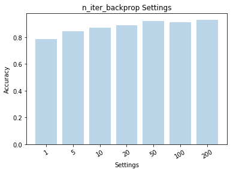

```python
# Create bar graph
plt.clf()
objects = ('1', '5', '10', '20', '50', '100', '200')
y_pos = np.arange(len(objects))
performance = [0.78500000000000003, 0.84499999999999997, 0.87, 0.89000000000000001, 0.92000000000000004, 0.91000000000000003, 0.93000000000000005]

plt.bar(y_pos, performance, align='center', alpha=0.3)
plt.xticks(y_pos, objects, rotation=30)
plt.xlabel('Settings')
plt.ylabel('Accuracy')
plt.title('n_iter_backprop Settings')

plt.show()
plt.clf()
```

### Benchmark 1:

Take the best setting for each n-layer setup and use the best performing parameters.

```python
# 1-layer
acc1 = deep_belief_net(hidden_layers_structure=[200],
                       learning_rate_rbm=0.05,
                       learning_rate=0.1,
                       n_epochs_rbm=40,
                       n_iter_backprop=200,
                       batch_size=32,
                       activation_function='relu',
                       dropout_p=0.2)
```

```
[START] Pre-training step:
>> Epoch 1 finished 	RBM Reconstruction error 48.168800
>> Epoch 2 finished 	RBM Reconstruction error 60.400215
>> Epoch 3 finished 	RBM Reconstruction error 63.935898
>> Epoch 4 finished 	RBM Reconstruction error 39.533291
>> Epoch 5 finished 	RBM Reconstruction error 32.563824
>> Epoch 6 finished 	RBM Reconstruction error 37.166458
>> Epoch 7 finished 	RBM Reconstruction error 26.511868
>> Epoch 8 finished 	RBM Reconstruction error 39.058151
>> Epoch 9 finished 	RBM Reconstruction error 37.210552
>> Epoch 10 finished 	RBM Reconstruction error 43.879555
>> Epoch 11 finished 	RBM Reconstruction error 55.275127
>> Epoch 12 finished 	RBM Reconstruction error 37.254604
>> Epoch 13 finished 	RBM Reconstruction error 37.860001
>> Epoch 14 finished 	RBM Reconstruction error 37.345356
>> Epoch 15 finished 	RBM Reconstruction error 34.719990
>> Epoch 16 finished 	RBM Reconstruction error 36.081120
>> Epoch 17 finished 	RBM Reconstruction error 32.172657
>> Epoch 18 finished 	RBM Reconstruction error 33.625538
>> Epoch 19 finished 	RBM Reconstruction error 34.060772
>> Epoch 20 finished 	RBM Reconstruction error 33.108856
>> Epoch 21 finished 	RBM Reconstruction error 35.387943
>> Epoch 22 finished 	RBM Reconstruction error 36.899574
>> Epoch 23 finished 	RBM Reconstruction error 43.065262
>> Epoch 24 finished 	RBM Reconstruction error 49.713409
>> Epoch 25 finished 	RBM Reconstruction error 30.912466
>> Epoch 26 finished 	RBM Reconstruction error 39.174515
>> Epoch 27 finished 	RBM Reconstruction error 37.267910
>> Epoch 28 finished 	RBM Reconstruction error 39.332657
>> Epoch 29 finished 	RBM Reconstruction error 36.845791
>> Epoch 30 finished 	RBM Reconstruction error 38.480324
>> Epoch 31 finished 	RBM Reconstruction error 29.171761
>> Epoch 32 finished 	RBM Reconstruction error 40.481262
>> Epoch 33 finished 	RBM Reconstruction error 51.669361
>> Epoch 34 finished 	RBM Reconstruction error 58.144600
>> Epoch 35 finished 	RBM Reconstruction error 43.789810
>> Epoch 36 finished 	RBM Reconstruction error 37.336426
>> Epoch 37 finished 	RBM Reconstruction error 37.533741
>> Epoch 38 finished 	RBM Reconstruction error 50.071625
>> Epoch 39 finished 	RBM Reconstruction error 52.193783
```

[output cut: 191 more lines]

```
>> Epoch 188 finished 	ANN training loss 0.001189
>> Epoch 189 finished 	ANN training loss 0.001081
>> Epoch 190 finished 	ANN training loss 0.001003
>> Epoch 191 finished 	ANN training loss 0.001001
>> Epoch 192 finished 	ANN training loss 0.000973
>> Epoch 193 finished 	ANN training loss 0.000970
>> Epoch 194 finished 	ANN training loss 0.000913
>> Epoch 195 finished 	ANN training loss 0.000908
>> Epoch 196 finished 	ANN training loss 0.000873
>> Epoch 197 finished 	ANN training loss 0.000865
>> Epoch 198 finished 	ANN training loss 0.000858
>> Epoch 199 finished 	ANN training loss 0.000947
[END] Fine tuning step
Done.
Accuracy: 0.900000
```

```python
print('ACCURACY: ' + str(acc1))
```

```
ACCURACY: 0.9
```

```python
# 1-layer (2nd one tied)
acc2 = deep_belief_net(hidden_layers_structure=[300],
                       learning_rate_rbm=0.05,
                       learning_rate=0.1,
                       n_epochs_rbm=40,
                       n_iter_backprop=200,
                       batch_size=32,
                       activation_function='relu',
                       dropout_p=0.2)
```

```
[START] Pre-training step:
>> Epoch 1 finished 	RBM Reconstruction error 52.362724
>> Epoch 2 finished 	RBM Reconstruction error 67.402321
>> Epoch 3 finished 	RBM Reconstruction error 55.501465
>> Epoch 4 finished 	RBM Reconstruction error 55.674171
>> Epoch 5 finished 	RBM Reconstruction error 51.376099
>> Epoch 6 finished 	RBM Reconstruction error 39.820408
>> Epoch 7 finished 	RBM Reconstruction error 49.372471
>> Epoch 8 finished 	RBM Reconstruction error 42.299225
>> Epoch 9 finished 	RBM Reconstruction error 43.152420
>> Epoch 10 finished 	RBM Reconstruction error 44.879902
>> Epoch 11 finished 	RBM Reconstruction error 44.187225
>> Epoch 12 finished 	RBM Reconstruction error 38.721596
>> Epoch 13 finished 	RBM Reconstruction error 44.987022
>> Epoch 14 finished 	RBM Reconstruction error 34.595253
>> Epoch 15 finished 	RBM Reconstruction error 38.884151
>> Epoch 16 finished 	RBM Reconstruction error 45.426708
>> Epoch 17 finished 	RBM Reconstruction error 42.453545
>> Epoch 18 finished 	RBM Reconstruction error 39.000511
>> Epoch 19 finished 	RBM Reconstruction error 39.822796
>> Epoch 20 finished 	RBM Reconstruction error 44.699356
>> Epoch 21 finished 	RBM Reconstruction error 42.462193
>> Epoch 22 finished 	RBM Reconstruction error 51.749691
>> Epoch 23 finished 	RBM Reconstruction error 54.024845
>> Epoch 24 finished 	RBM Reconstruction error 36.917061
>> Epoch 25 finished 	RBM Reconstruction error 35.519672
>> Epoch 26 finished 	RBM Reconstruction error 57.290401
>> Epoch 27 finished 	RBM Reconstruction error 47.573944
>> Epoch 28 finished 	RBM Reconstruction error 46.187237
>> Epoch 29 finished 	RBM Reconstruction error 37.448875
>> Epoch 30 finished 	RBM Reconstruction error 43.712196
>> Epoch 31 finished 	RBM Reconstruction error 35.429165
>> Epoch 32 finished 	RBM Reconstruction error 59.610336
>> Epoch 33 finished 	RBM Reconstruction error 40.510052
>> Epoch 34 finished 	RBM Reconstruction error 41.287785
>> Epoch 35 finished 	RBM Reconstruction error 39.892479
>> Epoch 36 finished 	RBM Reconstruction error 44.331387
>> Epoch 37 finished 	RBM Reconstruction error 41.451927
>> Epoch 38 finished 	RBM Reconstruction error 33.561676
>> Epoch 39 finished 	RBM Reconstruction error 51.854393
```

[output cut: 191 more lines]

```
>> Epoch 188 finished 	ANN training loss 0.000946
>> Epoch 189 finished 	ANN training loss 0.000926
>> Epoch 190 finished 	ANN training loss 0.000878
>> Epoch 191 finished 	ANN training loss 0.000943
>> Epoch 192 finished 	ANN training loss 0.000918
>> Epoch 193 finished 	ANN training loss 0.000912
>> Epoch 194 finished 	ANN training loss 0.000890
>> Epoch 195 finished 	ANN training loss 0.000913
>> Epoch 196 finished 	ANN training loss 0.000890
>> Epoch 197 finished 	ANN training loss 0.000882
>> Epoch 198 finished 	ANN training loss 0.000913
>> Epoch 199 finished 	ANN training loss 0.000929
[END] Fine tuning step
Done.
Accuracy: 0.920000
```

```python
print('ACCURACY: ' + str(acc2))
```

```
ACCURACY: 0.92
```

```python
# 2-layer
acc3 = deep_belief_net(hidden_layers_structure=[100, 500],
                       learning_rate_rbm=0.05,
                       learning_rate=0.1,
                       n_epochs_rbm=40,
                       n_iter_backprop=200,
                       batch_size=32,
                       activation_function='relu',
                       dropout_p=0.2)
```

```
[START] Pre-training step:
>> Epoch 1 finished 	RBM Reconstruction error 61.901642
>> Epoch 2 finished 	RBM Reconstruction error 60.275616
>> Epoch 3 finished 	RBM Reconstruction error 87.619865
>> Epoch 4 finished 	RBM Reconstruction error 56.597225
>> Epoch 5 finished 	RBM Reconstruction error 45.425381
>> Epoch 6 finished 	RBM Reconstruction error 46.222080
>> Epoch 7 finished 	RBM Reconstruction error 69.010742
>> Epoch 8 finished 	RBM Reconstruction error 45.242207
>> Epoch 9 finished 	RBM Reconstruction error 50.292126
>> Epoch 10 finished 	RBM Reconstruction error 57.479366
>> Epoch 11 finished 	RBM Reconstruction error 73.998779
>> Epoch 12 finished 	RBM Reconstruction error 68.098679
>> Epoch 13 finished 	RBM Reconstruction error 83.567871
>> Epoch 14 finished 	RBM Reconstruction error 75.080116
>> Epoch 15 finished 	RBM Reconstruction error 100.359024
>> Epoch 16 finished 	RBM Reconstruction error 72.527649
>> Epoch 17 finished 	RBM Reconstruction error 80.413300
>> Epoch 18 finished 	RBM Reconstruction error 85.674294
>> Epoch 19 finished 	RBM Reconstruction error 79.484909
>> Epoch 20 finished 	RBM Reconstruction error 107.319412
>> Epoch 21 finished 	RBM Reconstruction error 85.888161
>> Epoch 22 finished 	RBM Reconstruction error 84.266258
>> Epoch 23 finished 	RBM Reconstruction error 78.896393
>> Epoch 24 finished 	RBM Reconstruction error 78.359489
>> Epoch 25 finished 	RBM Reconstruction error 114.280861
>> Epoch 26 finished 	RBM Reconstruction error 104.662018
>> Epoch 27 finished 	RBM Reconstruction error 96.259026
>> Epoch 28 finished 	RBM Reconstruction error 88.241425
>> Epoch 29 finished 	RBM Reconstruction error 92.975906
>> Epoch 30 finished 	RBM Reconstruction error 99.582123
>> Epoch 31 finished 	RBM Reconstruction error 92.787491
>> Epoch 32 finished 	RBM Reconstruction error 99.423019
>> Epoch 33 finished 	RBM Reconstruction error 105.046349
>> Epoch 34 finished 	RBM Reconstruction error 104.780960
>> Epoch 35 finished 	RBM Reconstruction error 99.292625
>> Epoch 36 finished 	RBM Reconstruction error 115.861115
>> Epoch 37 finished 	RBM Reconstruction error 105.354256
>> Epoch 38 finished 	RBM Reconstruction error 112.433105
>> Epoch 39 finished 	RBM Reconstruction error 118.529953
```

[output cut: 231 more lines]

```
>> Epoch 188 finished 	ANN training loss 0.000282
>> Epoch 189 finished 	ANN training loss 0.000311
>> Epoch 190 finished 	ANN training loss 0.000273
>> Epoch 191 finished 	ANN training loss 0.000215
>> Epoch 192 finished 	ANN training loss 0.000232
>> Epoch 193 finished 	ANN training loss 0.000232
>> Epoch 194 finished 	ANN training loss 0.000214
>> Epoch 195 finished 	ANN training loss 0.000209
>> Epoch 196 finished 	ANN training loss 0.000210
>> Epoch 197 finished 	ANN training loss 0.000193
>> Epoch 198 finished 	ANN training loss 0.000199
>> Epoch 199 finished 	ANN training loss 0.000174
[END] Fine tuning step
Done.
Accuracy: 0.905000
```

```python
print('ACCURACY: ' + str(acc3))
```

```
ACCURACY: 0.905
```

```python
# 3-layer
acc4 = deep_belief_net(hidden_layers_structure=[500, 200, 300],
                       learning_rate_rbm=0.05,
                       learning_rate=0.1,
                       n_epochs_rbm=40,
                       n_iter_backprop=200,
                       batch_size=32,
                       activation_function='relu',
                       dropout_p=0.2)
```

```
[START] Pre-training step:
>> Epoch 1 finished 	RBM Reconstruction error 44.434200
>> Epoch 2 finished 	RBM Reconstruction error 36.059303
>> Epoch 3 finished 	RBM Reconstruction error 27.978998
>> Epoch 4 finished 	RBM Reconstruction error 43.884365
>> Epoch 5 finished 	RBM Reconstruction error 27.703917
>> Epoch 6 finished 	RBM Reconstruction error 40.638386
>> Epoch 7 finished 	RBM Reconstruction error 22.463474
>> Epoch 8 finished 	RBM Reconstruction error 20.800531
>> Epoch 9 finished 	RBM Reconstruction error 28.822454
>> Epoch 10 finished 	RBM Reconstruction error 32.591835
>> Epoch 11 finished 	RBM Reconstruction error 41.460468
>> Epoch 12 finished 	RBM Reconstruction error 29.742527
>> Epoch 13 finished 	RBM Reconstruction error 37.216793
>> Epoch 14 finished 	RBM Reconstruction error 27.116709
>> Epoch 15 finished 	RBM Reconstruction error 34.042049
>> Epoch 16 finished 	RBM Reconstruction error 17.215670
>> Epoch 17 finished 	RBM Reconstruction error 29.130920
>> Epoch 18 finished 	RBM Reconstruction error 28.987253
>> Epoch 19 finished 	RBM Reconstruction error 40.967419
>> Epoch 20 finished 	RBM Reconstruction error 19.373569
>> Epoch 21 finished 	RBM Reconstruction error 39.018585
>> Epoch 22 finished 	RBM Reconstruction error 21.660276
>> Epoch 23 finished 	RBM Reconstruction error 26.941730
>> Epoch 24 finished 	RBM Reconstruction error 25.511240
>> Epoch 25 finished 	RBM Reconstruction error 25.745319
>> Epoch 26 finished 	RBM Reconstruction error 22.503906
>> Epoch 27 finished 	RBM Reconstruction error 26.412804
>> Epoch 28 finished 	RBM Reconstruction error 22.252998
>> Epoch 29 finished 	RBM Reconstruction error 28.351004
>> Epoch 30 finished 	RBM Reconstruction error 31.632248
>> Epoch 31 finished 	RBM Reconstruction error 25.962896
>> Epoch 32 finished 	RBM Reconstruction error 17.551035
>> Epoch 33 finished 	RBM Reconstruction error 26.432123
>> Epoch 34 finished 	RBM Reconstruction error 26.573092
>> Epoch 35 finished 	RBM Reconstruction error 22.466236
>> Epoch 36 finished 	RBM Reconstruction error 25.236826
>> Epoch 37 finished 	RBM Reconstruction error 24.970171
>> Epoch 38 finished 	RBM Reconstruction error 29.371695
>> Epoch 39 finished 	RBM Reconstruction error 25.026304
```

[output cut: 271 more lines]

```
>> Epoch 188 finished 	ANN training loss 0.000053
>> Epoch 189 finished 	ANN training loss 0.000039
>> Epoch 190 finished 	ANN training loss 0.000032
>> Epoch 191 finished 	ANN training loss 0.000029
>> Epoch 192 finished 	ANN training loss 0.000027
>> Epoch 193 finished 	ANN training loss 0.000025
>> Epoch 194 finished 	ANN training loss 0.000025
>> Epoch 195 finished 	ANN training loss 0.000021
>> Epoch 196 finished 	ANN training loss 0.000019
>> Epoch 197 finished 	ANN training loss 0.000022
>> Epoch 198 finished 	ANN training loss 0.000020
>> Epoch 199 finished 	ANN training loss 0.000027
[END] Fine tuning step
Done.
Accuracy: 0.905000
```

```python
print('ACCURACY: ' + str(acc4))
```

```
ACCURACY: 0.905
```

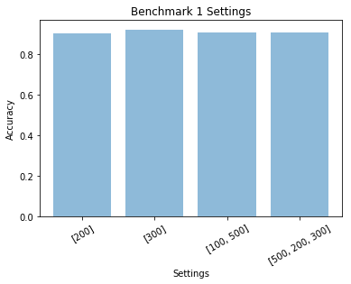

```python
# Create bar graph
plt.clf()
objects = ('[200]', '[300]', '[100, 500]', '[500, 200, 300]')
y_pos = np.arange(len(objects))
performance = [0.9, 0.92, 0.905, 0.905]
plt.bar(y_pos, performance, align='center', alpha=0.5)
plt.xticks(y_pos, objects, rotation=30)
plt.xlabel('Settings')
plt.ylabel('Accuracy')
plt.title('Benchmark 1 Settings')

plt.show()
plt.clf()
```

### Benchmark 2:

Take the best performing one from benchmark 1 and test with the sigmoidal activation function and various dropouts.

```python
# Sigmoidal activation, dropout = 0
acc1 = deep_belief_net(hidden_layers_structure=[300],
                       learning_rate_rbm=0.05,
                       learning_rate=0.1,
                       n_epochs_rbm=40,
                       n_iter_backprop=200,
                       batch_size=32,
                       activation_function='sigmoid',
                       dropout_p=0.)
```

```
[START] Pre-training step:
>> Epoch 1 finished 	RBM Reconstruction error 44.978886
>> Epoch 2 finished 	RBM Reconstruction error 35.064987
>> Epoch 3 finished 	RBM Reconstruction error 29.802525
>> Epoch 4 finished 	RBM Reconstruction error 26.875952
>> Epoch 5 finished 	RBM Reconstruction error 24.820986
>> Epoch 6 finished 	RBM Reconstruction error 23.147341
>> Epoch 7 finished 	RBM Reconstruction error 21.914331
>> Epoch 8 finished 	RBM Reconstruction error 20.743584
>> Epoch 9 finished 	RBM Reconstruction error 19.739283
>> Epoch 10 finished 	RBM Reconstruction error 18.733677
>> Epoch 11 finished 	RBM Reconstruction error 18.087568
>> Epoch 12 finished 	RBM Reconstruction error 17.153889
>> Epoch 13 finished 	RBM Reconstruction error 16.515764
>> Epoch 14 finished 	RBM Reconstruction error 15.871891
>> Epoch 15 finished 	RBM Reconstruction error 15.334622
>> Epoch 16 finished 	RBM Reconstruction error 14.836199
>> Epoch 17 finished 	RBM Reconstruction error 14.399968
>> Epoch 18 finished 	RBM Reconstruction error 13.953169
>> Epoch 19 finished 	RBM Reconstruction error 13.539706
>> Epoch 20 finished 	RBM Reconstruction error 13.197330
>> Epoch 21 finished 	RBM Reconstruction error 12.844109
>> Epoch 22 finished 	RBM Reconstruction error 12.559888
>> Epoch 23 finished 	RBM Reconstruction error 12.235383
>> Epoch 24 finished 	RBM Reconstruction error 11.954041
>> Epoch 25 finished 	RBM Reconstruction error 11.678492
>> Epoch 26 finished 	RBM Reconstruction error 11.447932
>> Epoch 27 finished 	RBM Reconstruction error 11.173759
>> Epoch 28 finished 	RBM Reconstruction error 10.916043
>> Epoch 29 finished 	RBM Reconstruction error 10.677363
>> Epoch 30 finished 	RBM Reconstruction error 10.474979
>> Epoch 31 finished 	RBM Reconstruction error 10.296218
>> Epoch 32 finished 	RBM Reconstruction error 10.132094
>> Epoch 33 finished 	RBM Reconstruction error 9.909482
>> Epoch 34 finished 	RBM Reconstruction error 9.733149
>> Epoch 35 finished 	RBM Reconstruction error 9.567850
>> Epoch 36 finished 	RBM Reconstruction error 9.448261
>> Epoch 37 finished 	RBM Reconstruction error 9.236425
>> Epoch 38 finished 	RBM Reconstruction error 9.135662
>> Epoch 39 finished 	RBM Reconstruction error 8.978279
```

[output cut: 191 more lines]

```
>> Epoch 188 finished 	ANN training loss 0.018511
>> Epoch 189 finished 	ANN training loss 0.018385
>> Epoch 190 finished 	ANN training loss 0.018245
>> Epoch 191 finished 	ANN training loss 0.018110
>> Epoch 192 finished 	ANN training loss 0.017983
>> Epoch 193 finished 	ANN training loss 0.017857
>> Epoch 194 finished 	ANN training loss 0.017730
>> Epoch 195 finished 	ANN training loss 0.017604
>> Epoch 196 finished 	ANN training loss 0.017482
>> Epoch 197 finished 	ANN training loss 0.017361
>> Epoch 198 finished 	ANN training loss 0.017240
>> Epoch 199 finished 	ANN training loss 0.017121
[END] Fine tuning step
Done.
Accuracy: 0.885000
```

```python
print('ACCURACY: ' + str(acc1))
```

```
ACCURACY: 0.885
```

```python
# Sigmoidal activation, dropout = 0.1
acc2 = deep_belief_net(hidden_layers_structure=[300],
                       learning_rate_rbm=0.05,
                       learning_rate=0.1,
                       n_epochs_rbm=40,
                       n_iter_backprop=200,
                       batch_size=32,
                       activation_function='sigmoid',
                       dropout_p=0.1)
```

```
[START] Pre-training step:
>> Epoch 1 finished 	RBM Reconstruction error 44.260117
>> Epoch 2 finished 	RBM Reconstruction error 35.192554
>> Epoch 3 finished 	RBM Reconstruction error 29.961706
>> Epoch 4 finished 	RBM Reconstruction error 26.800102
>> Epoch 5 finished 	RBM Reconstruction error 24.817398
>> Epoch 6 finished 	RBM Reconstruction error 23.394810
>> Epoch 7 finished 	RBM Reconstruction error 22.047796
>> Epoch 8 finished 	RBM Reconstruction error 20.963203
>> Epoch 9 finished 	RBM Reconstruction error 19.795736
>> Epoch 10 finished 	RBM Reconstruction error 18.846254
>> Epoch 11 finished 	RBM Reconstruction error 17.976402
>> Epoch 12 finished 	RBM Reconstruction error 17.134426
>> Epoch 13 finished 	RBM Reconstruction error 16.498646
>> Epoch 14 finished 	RBM Reconstruction error 15.851318
>> Epoch 15 finished 	RBM Reconstruction error 15.397351
>> Epoch 16 finished 	RBM Reconstruction error 14.870476
>> Epoch 17 finished 	RBM Reconstruction error 14.406140
>> Epoch 18 finished 	RBM Reconstruction error 13.980465
>> Epoch 19 finished 	RBM Reconstruction error 13.518435
>> Epoch 20 finished 	RBM Reconstruction error 13.194644
>> Epoch 21 finished 	RBM Reconstruction error 12.848903
>> Epoch 22 finished 	RBM Reconstruction error 12.519985
>> Epoch 23 finished 	RBM Reconstruction error 12.247717
>> Epoch 24 finished 	RBM Reconstruction error 11.962986
>> Epoch 25 finished 	RBM Reconstruction error 11.697039
>> Epoch 26 finished 	RBM Reconstruction error 11.470684
>> Epoch 27 finished 	RBM Reconstruction error 11.205069
>> Epoch 28 finished 	RBM Reconstruction error 10.994288
>> Epoch 29 finished 	RBM Reconstruction error 10.739779
>> Epoch 30 finished 	RBM Reconstruction error 10.553040
>> Epoch 31 finished 	RBM Reconstruction error 10.393013
>> Epoch 32 finished 	RBM Reconstruction error 10.134296
>> Epoch 33 finished 	RBM Reconstruction error 9.982868
>> Epoch 34 finished 	RBM Reconstruction error 9.832887
>> Epoch 35 finished 	RBM Reconstruction error 9.677349
>> Epoch 36 finished 	RBM Reconstruction error 9.445460
>> Epoch 37 finished 	RBM Reconstruction error 9.336734
>> Epoch 38 finished 	RBM Reconstruction error 9.187797
>> Epoch 39 finished 	RBM Reconstruction error 9.029409
```

[output cut: 191 more lines]

```
>> Epoch 188 finished 	ANN training loss 0.015330
>> Epoch 189 finished 	ANN training loss 0.015262
>> Epoch 190 finished 	ANN training loss 0.015225
>> Epoch 191 finished 	ANN training loss 0.015007
>> Epoch 192 finished 	ANN training loss 0.014917
>> Epoch 193 finished 	ANN training loss 0.014645
>> Epoch 194 finished 	ANN training loss 0.014746
>> Epoch 195 finished 	ANN training loss 0.014429
>> Epoch 196 finished 	ANN training loss 0.014312
>> Epoch 197 finished 	ANN training loss 0.014340
>> Epoch 198 finished 	ANN training loss 0.014098
>> Epoch 199 finished 	ANN training loss 0.014554
[END] Fine tuning step
Done.
Accuracy: 0.920000
```

```python
print('ACCURACY: ' + str(acc2))
```

```
ACCURACY: 0.92
```

```python
# Sigmoidal activation, dropout = 0.2
acc3 = deep_belief_net(hidden_layers_structure=[300],
                       learning_rate_rbm=0.05,
                       learning_rate=0.1,
                       n_epochs_rbm=40,
                       n_iter_backprop=200,
                       batch_size=32,
                       activation_function='sigmoid',
                       dropout_p=0.2)
```

```
[START] Pre-training step:
>> Epoch 1 finished 	RBM Reconstruction error 43.777512
>> Epoch 2 finished 	RBM Reconstruction error 34.819828
>> Epoch 3 finished 	RBM Reconstruction error 29.929005
>> Epoch 4 finished 	RBM Reconstruction error 26.783167
>> Epoch 5 finished 	RBM Reconstruction error 24.906950
>> Epoch 6 finished 	RBM Reconstruction error 23.168297
>> Epoch 7 finished 	RBM Reconstruction error 21.832165
>> Epoch 8 finished 	RBM Reconstruction error 20.717415
>> Epoch 9 finished 	RBM Reconstruction error 19.738537
>> Epoch 10 finished 	RBM Reconstruction error 18.720924
>> Epoch 11 finished 	RBM Reconstruction error 17.846592
>> Epoch 12 finished 	RBM Reconstruction error 17.117878
>> Epoch 13 finished 	RBM Reconstruction error 16.533508
>> Epoch 14 finished 	RBM Reconstruction error 15.922471
>> Epoch 15 finished 	RBM Reconstruction error 15.373255
>> Epoch 16 finished 	RBM Reconstruction error 14.934807
>> Epoch 17 finished 	RBM Reconstruction error 14.433249
>> Epoch 18 finished 	RBM Reconstruction error 13.970982
>> Epoch 19 finished 	RBM Reconstruction error 13.633357
>> Epoch 20 finished 	RBM Reconstruction error 13.290371
>> Epoch 21 finished 	RBM Reconstruction error 12.880840
>> Epoch 22 finished 	RBM Reconstruction error 12.614532
>> Epoch 23 finished 	RBM Reconstruction error 12.266057
>> Epoch 24 finished 	RBM Reconstruction error 11.948356
>> Epoch 25 finished 	RBM Reconstruction error 11.696796
>> Epoch 26 finished 	RBM Reconstruction error 11.445100
>> Epoch 27 finished 	RBM Reconstruction error 11.176467
>> Epoch 28 finished 	RBM Reconstruction error 11.006009
>> Epoch 29 finished 	RBM Reconstruction error 10.782668
>> Epoch 30 finished 	RBM Reconstruction error 10.539347
>> Epoch 31 finished 	RBM Reconstruction error 10.344507
>> Epoch 32 finished 	RBM Reconstruction error 10.168985
>> Epoch 33 finished 	RBM Reconstruction error 9.972208
>> Epoch 34 finished 	RBM Reconstruction error 9.822224
>> Epoch 35 finished 	RBM Reconstruction error 9.626230
>> Epoch 36 finished 	RBM Reconstruction error 9.475251
>> Epoch 37 finished 	RBM Reconstruction error 9.329857
>> Epoch 38 finished 	RBM Reconstruction error 9.136558
>> Epoch 39 finished 	RBM Reconstruction error 9.002902
```

[output cut: 191 more lines]

```
>> Epoch 188 finished 	ANN training loss 0.015258
>> Epoch 189 finished 	ANN training loss 0.015330
>> Epoch 190 finished 	ANN training loss 0.014973
>> Epoch 191 finished 	ANN training loss 0.014862
>> Epoch 192 finished 	ANN training loss 0.014803
>> Epoch 193 finished 	ANN training loss 0.014689
>> Epoch 194 finished 	ANN training loss 0.014628
>> Epoch 195 finished 	ANN training loss 0.014397
>> Epoch 196 finished 	ANN training loss 0.014091
>> Epoch 197 finished 	ANN training loss 0.013958
>> Epoch 198 finished 	ANN training loss 0.014125
>> Epoch 199 finished 	ANN training loss 0.014154
[END] Fine tuning step
Done.
Accuracy: 0.895000
```

```python
print('ACCURACY: ' + str(acc3))
```

```
ACCURACY: 0.895
```

```python
# Sigmoidal activation, dropout=0.3
acc4 = deep_belief_net(hidden_layers_structure=[300],
                       learning_rate_rbm=0.05,
                       learning_rate=0.1,
                       n_epochs_rbm=40,
                       n_iter_backprop=200,
                       batch_size=32,
                       activation_function='sigmoid',
                       dropout_p=0.3)
```

```
[START] Pre-training step:
>> Epoch 1 finished 	RBM Reconstruction error 44.225895
>> Epoch 2 finished 	RBM Reconstruction error 34.718281
>> Epoch 3 finished 	RBM Reconstruction error 29.788921
>> Epoch 4 finished 	RBM Reconstruction error 26.949614
>> Epoch 5 finished 	RBM Reconstruction error 24.911928
>> Epoch 6 finished 	RBM Reconstruction error 23.260574
>> Epoch 7 finished 	RBM Reconstruction error 21.936123
>> Epoch 8 finished 	RBM Reconstruction error 20.846138
>> Epoch 9 finished 	RBM Reconstruction error 19.758648
>> Epoch 10 finished 	RBM Reconstruction error 18.762615
>> Epoch 11 finished 	RBM Reconstruction error 17.996824
>> Epoch 12 finished 	RBM Reconstruction error 17.189198
>> Epoch 13 finished 	RBM Reconstruction error 16.503515
>> Epoch 14 finished 	RBM Reconstruction error 15.971636
>> Epoch 15 finished 	RBM Reconstruction error 15.345450
>> Epoch 16 finished 	RBM Reconstruction error 14.842959
>> Epoch 17 finished 	RBM Reconstruction error 14.420224
>> Epoch 18 finished 	RBM Reconstruction error 14.055085
>> Epoch 19 finished 	RBM Reconstruction error 13.568018
>> Epoch 20 finished 	RBM Reconstruction error 13.243212
>> Epoch 21 finished 	RBM Reconstruction error 12.880724
>> Epoch 22 finished 	RBM Reconstruction error 12.603806
>> Epoch 23 finished 	RBM Reconstruction error 12.256539
>> Epoch 24 finished 	RBM Reconstruction error 12.033975
>> Epoch 25 finished 	RBM Reconstruction error 11.768235
>> Epoch 26 finished 	RBM Reconstruction error 11.515949
>> Epoch 27 finished 	RBM Reconstruction error 11.250635
>> Epoch 28 finished 	RBM Reconstruction error 11.042171
>> Epoch 29 finished 	RBM Reconstruction error 10.783718
>> Epoch 30 finished 	RBM Reconstruction error 10.576234
>> Epoch 31 finished 	RBM Reconstruction error 10.382644
>> Epoch 32 finished 	RBM Reconstruction error 10.254204
>> Epoch 33 finished 	RBM Reconstruction error 10.007308
>> Epoch 34 finished 	RBM Reconstruction error 9.881972
>> Epoch 35 finished 	RBM Reconstruction error 9.700727
>> Epoch 36 finished 	RBM Reconstruction error 9.511007
>> Epoch 37 finished 	RBM Reconstruction error 9.342621
>> Epoch 38 finished 	RBM Reconstruction error 9.188943
>> Epoch 39 finished 	RBM Reconstruction error 9.156702
```

[output cut: 191 more lines]

```
>> Epoch 188 finished 	ANN training loss 0.021840
>> Epoch 189 finished 	ANN training loss 0.021442
>> Epoch 190 finished 	ANN training loss 0.021317
>> Epoch 191 finished 	ANN training loss 0.020864
>> Epoch 192 finished 	ANN training loss 0.021455
>> Epoch 193 finished 	ANN training loss 0.020897
>> Epoch 194 finished 	ANN training loss 0.020465
>> Epoch 195 finished 	ANN training loss 0.020478
>> Epoch 196 finished 	ANN training loss 0.020300
>> Epoch 197 finished 	ANN training loss 0.019588
>> Epoch 198 finished 	ANN training loss 0.020095
>> Epoch 199 finished 	ANN training loss 0.020331
[END] Fine tuning step
Done.
Accuracy: 0.885000
```

```python
print('ACCURACY: ' + str(acc4))
```

```
ACCURACY: 0.885
```

```python
# Sigmoidal activation, dropout=0.4
acc5 = deep_belief_net(hidden_layers_structure=[300],
                       learning_rate_rbm=0.05,
                       learning_rate=0.1,
                       n_epochs_rbm=40,
                       n_iter_backprop=200,
                       batch_size=32,
                       activation_function='sigmoid',
                       dropout_p=0.4)
```

```
[START] Pre-training step:
>> Epoch 1 finished 	RBM Reconstruction error 44.140255
>> Epoch 2 finished 	RBM Reconstruction error 34.516369
>> Epoch 3 finished 	RBM Reconstruction error 29.879543
>> Epoch 4 finished 	RBM Reconstruction error 26.920717
>> Epoch 5 finished 	RBM Reconstruction error 24.939825
>> Epoch 6 finished 	RBM Reconstruction error 23.316221
>> Epoch 7 finished 	RBM Reconstruction error 21.916279
>> Epoch 8 finished 	RBM Reconstruction error 20.817162
>> Epoch 9 finished 	RBM Reconstruction error 19.809341
>> Epoch 10 finished 	RBM Reconstruction error 18.751474
>> Epoch 11 finished 	RBM Reconstruction error 17.958969
>> Epoch 12 finished 	RBM Reconstruction error 17.174906
>> Epoch 13 finished 	RBM Reconstruction error 16.434946
>> Epoch 14 finished 	RBM Reconstruction error 15.872507
>> Epoch 15 finished 	RBM Reconstruction error 15.349248
>> Epoch 16 finished 	RBM Reconstruction error 14.827047
>> Epoch 17 finished 	RBM Reconstruction error 14.338945
>> Epoch 18 finished 	RBM Reconstruction error 13.959961
>> Epoch 19 finished 	RBM Reconstruction error 13.526467
>> Epoch 20 finished 	RBM Reconstruction error 13.282947
>> Epoch 21 finished 	RBM Reconstruction error 12.865698
>> Epoch 22 finished 	RBM Reconstruction error 12.565104
>> Epoch 23 finished 	RBM Reconstruction error 12.277325
>> Epoch 24 finished 	RBM Reconstruction error 12.016171
>> Epoch 25 finished 	RBM Reconstruction error 11.813180
>> Epoch 26 finished 	RBM Reconstruction error 11.481167
>> Epoch 27 finished 	RBM Reconstruction error 11.220469
>> Epoch 28 finished 	RBM Reconstruction error 11.012957
>> Epoch 29 finished 	RBM Reconstruction error 10.753363
>> Epoch 30 finished 	RBM Reconstruction error 10.548894
>> Epoch 31 finished 	RBM Reconstruction error 10.340069
>> Epoch 32 finished 	RBM Reconstruction error 10.136040
>> Epoch 33 finished 	RBM Reconstruction error 10.000112
>> Epoch 34 finished 	RBM Reconstruction error 9.816780
>> Epoch 35 finished 	RBM Reconstruction error 9.689515
>> Epoch 36 finished 	RBM Reconstruction error 9.468905
>> Epoch 37 finished 	RBM Reconstruction error 9.430795
>> Epoch 38 finished 	RBM Reconstruction error 9.228283
>> Epoch 39 finished 	RBM Reconstruction error 9.073233
```

[output cut: 191 more lines]

```
>> Epoch 188 finished 	ANN training loss 0.029761
>> Epoch 189 finished 	ANN training loss 0.029402
>> Epoch 190 finished 	ANN training loss 0.028540
>> Epoch 191 finished 	ANN training loss 0.028611
>> Epoch 192 finished 	ANN training loss 0.028487
>> Epoch 193 finished 	ANN training loss 0.027111
>> Epoch 194 finished 	ANN training loss 0.027326
>> Epoch 195 finished 	ANN training loss 0.027370
>> Epoch 196 finished 	ANN training loss 0.027969
>> Epoch 197 finished 	ANN training loss 0.027641
>> Epoch 198 finished 	ANN training loss 0.027018
>> Epoch 199 finished 	ANN training loss 0.025903
[END] Fine tuning step
Done.
Accuracy: 0.885000
```

```python
print('ACCURACY: ' + str(acc5))
```

```
ACCURACY: 0.885
```

```python
# Sigmoidal activation, dropout=0.5
acc6 = deep_belief_net(hidden_layers_structure=[300],
                       learning_rate_rbm=0.05,
                       learning_rate=0.1,
                       n_epochs_rbm=40,
                       n_iter_backprop=200,
                       batch_size=32,
                       activation_function='sigmoid',
                       dropout_p=0.5)
```

```
[START] Pre-training step:
>> Epoch 1 finished 	RBM Reconstruction error 44.573238
>> Epoch 2 finished 	RBM Reconstruction error 34.630795
>> Epoch 3 finished 	RBM Reconstruction error 30.121592
>> Epoch 4 finished 	RBM Reconstruction error 26.837561
>> Epoch 5 finished 	RBM Reconstruction error 24.935493
>> Epoch 6 finished 	RBM Reconstruction error 23.162682
>> Epoch 7 finished 	RBM Reconstruction error 21.974854
>> Epoch 8 finished 	RBM Reconstruction error 20.764902
>> Epoch 9 finished 	RBM Reconstruction error 19.719866
>> Epoch 10 finished 	RBM Reconstruction error 18.765295
>> Epoch 11 finished 	RBM Reconstruction error 17.900713
>> Epoch 12 finished 	RBM Reconstruction error 17.103657
>> Epoch 13 finished 	RBM Reconstruction error 16.434870
>> Epoch 14 finished 	RBM Reconstruction error 15.841487
>> Epoch 15 finished 	RBM Reconstruction error 15.312390
>> Epoch 16 finished 	RBM Reconstruction error 14.815372
>> Epoch 17 finished 	RBM Reconstruction error 14.355344
>> Epoch 18 finished 	RBM Reconstruction error 13.964416
>> Epoch 19 finished 	RBM Reconstruction error 13.502627
>> Epoch 20 finished 	RBM Reconstruction error 13.164868
>> Epoch 21 finished 	RBM Reconstruction error 12.808501
>> Epoch 22 finished 	RBM Reconstruction error 12.508628
>> Epoch 23 finished 	RBM Reconstruction error 12.175906
>> Epoch 24 finished 	RBM Reconstruction error 11.939978
>> Epoch 25 finished 	RBM Reconstruction error 11.676118
>> Epoch 26 finished 	RBM Reconstruction error 11.405881
>> Epoch 27 finished 	RBM Reconstruction error 11.143344
>> Epoch 28 finished 	RBM Reconstruction error 10.943728
>> Epoch 29 finished 	RBM Reconstruction error 10.718337
>> Epoch 30 finished 	RBM Reconstruction error 10.472020
>> Epoch 31 finished 	RBM Reconstruction error 10.317543
>> Epoch 32 finished 	RBM Reconstruction error 10.093082
>> Epoch 33 finished 	RBM Reconstruction error 9.895876
>> Epoch 34 finished 	RBM Reconstruction error 9.735769
>> Epoch 35 finished 	RBM Reconstruction error 9.620356
>> Epoch 36 finished 	RBM Reconstruction error 9.389066
>> Epoch 37 finished 	RBM Reconstruction error 9.231999
>> Epoch 38 finished 	RBM Reconstruction error 9.104783
>> Epoch 39 finished 	RBM Reconstruction error 8.953965
```

[output cut: 191 more lines]

```
>> Epoch 188 finished 	ANN training loss 0.050607
>> Epoch 189 finished 	ANN training loss 0.049316
>> Epoch 190 finished 	ANN training loss 0.050565
>> Epoch 191 finished 	ANN training loss 0.050284
>> Epoch 192 finished 	ANN training loss 0.049247
>> Epoch 193 finished 	ANN training loss 0.048176
>> Epoch 194 finished 	ANN training loss 0.048126
>> Epoch 195 finished 	ANN training loss 0.047812
>> Epoch 196 finished 	ANN training loss 0.046406
>> Epoch 197 finished 	ANN training loss 0.047042
>> Epoch 198 finished 	ANN training loss 0.048685
>> Epoch 199 finished 	ANN training loss 0.048325
[END] Fine tuning step
Done.
Accuracy: 0.875000
```

```python
print('ACCURACY: ' + str(acc6))
```

```
ACCURACY: 0.875
```

```python
# Sigmoidal activation, dropout=0.6
acc7 = deep_belief_net(hidden_layers_structure=[300],
                       learning_rate_rbm=0.05,
                       learning_rate=0.1,
                       n_epochs_rbm=40,
                       n_iter_backprop=200,
                       batch_size=32,
                       activation_function='sigmoid',
                       dropout_p=0.6)
```

```
[START] Pre-training step:
>> Epoch 1 finished 	RBM Reconstruction error 43.978573
>> Epoch 2 finished 	RBM Reconstruction error 34.663868
>> Epoch 3 finished 	RBM Reconstruction error 29.835709
>> Epoch 4 finished 	RBM Reconstruction error 26.734238
>> Epoch 5 finished 	RBM Reconstruction error 24.634024
>> Epoch 6 finished 	RBM Reconstruction error 23.120874
>> Epoch 7 finished 	RBM Reconstruction error 21.792395
>> Epoch 8 finished 	RBM Reconstruction error 20.564890
>> Epoch 9 finished 	RBM Reconstruction error 19.499239
>> Epoch 10 finished 	RBM Reconstruction error 18.631668
>> Epoch 11 finished 	RBM Reconstruction error 17.790821
>> Epoch 12 finished 	RBM Reconstruction error 17.104307
>> Epoch 13 finished 	RBM Reconstruction error 16.414818
>> Epoch 14 finished 	RBM Reconstruction error 15.772669
>> Epoch 15 finished 	RBM Reconstruction error 15.287756
>> Epoch 16 finished 	RBM Reconstruction error 14.800046
>> Epoch 17 finished 	RBM Reconstruction error 14.310347
>> Epoch 18 finished 	RBM Reconstruction error 13.852696
>> Epoch 19 finished 	RBM Reconstruction error 13.496503
>> Epoch 20 finished 	RBM Reconstruction error 13.173393
>> Epoch 21 finished 	RBM Reconstruction error 12.813791
>> Epoch 22 finished 	RBM Reconstruction error 12.492845
>> Epoch 23 finished 	RBM Reconstruction error 12.198965
>> Epoch 24 finished 	RBM Reconstruction error 11.911744
>> Epoch 25 finished 	RBM Reconstruction error 11.605242
>> Epoch 26 finished 	RBM Reconstruction error 11.385957
>> Epoch 27 finished 	RBM Reconstruction error 11.180469
>> Epoch 28 finished 	RBM Reconstruction error 10.864896
>> Epoch 29 finished 	RBM Reconstruction error 10.740730
>> Epoch 30 finished 	RBM Reconstruction error 10.482827
>> Epoch 31 finished 	RBM Reconstruction error 10.279586
>> Epoch 32 finished 	RBM Reconstruction error 10.076273
>> Epoch 33 finished 	RBM Reconstruction error 9.907208
>> Epoch 34 finished 	RBM Reconstruction error 9.734780
>> Epoch 35 finished 	RBM Reconstruction error 9.549190
>> Epoch 36 finished 	RBM Reconstruction error 9.444825
>> Epoch 37 finished 	RBM Reconstruction error 9.257287
>> Epoch 38 finished 	RBM Reconstruction error 9.102218
>> Epoch 39 finished 	RBM Reconstruction error 8.930707
```

[output cut: 191 more lines]

```
>> Epoch 188 finished 	ANN training loss 0.091968
>> Epoch 189 finished 	ANN training loss 0.090693
>> Epoch 190 finished 	ANN training loss 0.092100
>> Epoch 191 finished 	ANN training loss 0.087732
>> Epoch 192 finished 	ANN training loss 0.093978
>> Epoch 193 finished 	ANN training loss 0.089193
>> Epoch 194 finished 	ANN training loss 0.088208
>> Epoch 195 finished 	ANN training loss 0.086890
>> Epoch 196 finished 	ANN training loss 0.086318
>> Epoch 197 finished 	ANN training loss 0.083534
>> Epoch 198 finished 	ANN training loss 0.087466
>> Epoch 199 finished 	ANN training loss 0.086072
[END] Fine tuning step
Done.
Accuracy: 0.880000
```

```python
print('ACCURACY: ' + str(acc7))
```

```
ACCURACY: 0.88
```

```python
# Sigmoidal activation, dropout=0.7
acc8 = deep_belief_net(hidden_layers_structure=[300],
                       learning_rate_rbm=0.05,
                       learning_rate=0.1,
                       n_epochs_rbm=40,
                       n_iter_backprop=200,
                       batch_size=32,
                       activation_function='sigmoid',
                       dropout_p=0.7)
```

```
[START] Pre-training step:
>> Epoch 1 finished 	RBM Reconstruction error 45.129498
>> Epoch 2 finished 	RBM Reconstruction error 35.027809
>> Epoch 3 finished 	RBM Reconstruction error 30.016743
>> Epoch 4 finished 	RBM Reconstruction error 27.039062
>> Epoch 5 finished 	RBM Reconstruction error 24.958534
>> Epoch 6 finished 	RBM Reconstruction error 23.295965
>> Epoch 7 finished 	RBM Reconstruction error 22.010513
>> Epoch 8 finished 	RBM Reconstruction error 20.783161
>> Epoch 9 finished 	RBM Reconstruction error 19.772827
>> Epoch 10 finished 	RBM Reconstruction error 18.897926
>> Epoch 11 finished 	RBM Reconstruction error 18.084539
>> Epoch 12 finished 	RBM Reconstruction error 17.287664
>> Epoch 13 finished 	RBM Reconstruction error 16.526663
>> Epoch 14 finished 	RBM Reconstruction error 15.959409
>> Epoch 15 finished 	RBM Reconstruction error 15.371964
>> Epoch 16 finished 	RBM Reconstruction error 14.881211
>> Epoch 17 finished 	RBM Reconstruction error 14.398421
>> Epoch 18 finished 	RBM Reconstruction error 13.998322
>> Epoch 19 finished 	RBM Reconstruction error 13.635403
>> Epoch 20 finished 	RBM Reconstruction error 13.256783
>> Epoch 21 finished 	RBM Reconstruction error 12.907571
>> Epoch 22 finished 	RBM Reconstruction error 12.537066
>> Epoch 23 finished 	RBM Reconstruction error 12.248904
>> Epoch 24 finished 	RBM Reconstruction error 11.962505
>> Epoch 25 finished 	RBM Reconstruction error 11.719161
>> Epoch 26 finished 	RBM Reconstruction error 11.460996
>> Epoch 27 finished 	RBM Reconstruction error 11.195226
>> Epoch 28 finished 	RBM Reconstruction error 10.997808
>> Epoch 29 finished 	RBM Reconstruction error 10.800192
>> Epoch 30 finished 	RBM Reconstruction error 10.568363
>> Epoch 31 finished 	RBM Reconstruction error 10.428193
>> Epoch 32 finished 	RBM Reconstruction error 10.189788
>> Epoch 33 finished 	RBM Reconstruction error 10.028370
>> Epoch 34 finished 	RBM Reconstruction error 9.871050
>> Epoch 35 finished 	RBM Reconstruction error 9.679565
>> Epoch 36 finished 	RBM Reconstruction error 9.528945
>> Epoch 37 finished 	RBM Reconstruction error 9.363136
>> Epoch 38 finished 	RBM Reconstruction error 9.186206
>> Epoch 39 finished 	RBM Reconstruction error 9.027005
```

[output cut: 191 more lines]

```
>> Epoch 188 finished 	ANN training loss 0.173310
>> Epoch 189 finished 	ANN training loss 0.169985
>> Epoch 190 finished 	ANN training loss 0.166613
>> Epoch 191 finished 	ANN training loss 0.165692
>> Epoch 192 finished 	ANN training loss 0.165352
>> Epoch 193 finished 	ANN training loss 0.165666
>> Epoch 194 finished 	ANN training loss 0.165380
>> Epoch 195 finished 	ANN training loss 0.162680
>> Epoch 196 finished 	ANN training loss 0.162424
>> Epoch 197 finished 	ANN training loss 0.163724
>> Epoch 198 finished 	ANN training loss 0.159991
>> Epoch 199 finished 	ANN training loss 0.159692
[END] Fine tuning step
Done.
Accuracy: 0.850000
```

```python
print('ACCURACY: ' + str(acc8))
```

```
ACCURACY: 0.85
```

```python
# Sigmoidal activation, dropout=0.8
acc9 = deep_belief_net(hidden_layers_structure=[300],
                       learning_rate_rbm=0.05,
                       learning_rate=0.1,
                       n_epochs_rbm=40,
                       n_iter_backprop=200,
                       batch_size=32,
                       activation_function='sigmoid',
                       dropout_p=0.8)
```

```
[START] Pre-training step:
>> Epoch 1 finished 	RBM Reconstruction error 44.051876
>> Epoch 2 finished 	RBM Reconstruction error 35.091831
>> Epoch 3 finished 	RBM Reconstruction error 30.071026
>> Epoch 4 finished 	RBM Reconstruction error 26.948423
>> Epoch 5 finished 	RBM Reconstruction error 24.779713
>> Epoch 6 finished 	RBM Reconstruction error 23.062523
>> Epoch 7 finished 	RBM Reconstruction error 21.873995
>> Epoch 8 finished 	RBM Reconstruction error 20.669756
>> Epoch 9 finished 	RBM Reconstruction error 19.651505
>> Epoch 10 finished 	RBM Reconstruction error 18.680679
>> Epoch 11 finished 	RBM Reconstruction error 17.984848
>> Epoch 12 finished 	RBM Reconstruction error 17.155359
>> Epoch 13 finished 	RBM Reconstruction error 16.523981
>> Epoch 14 finished 	RBM Reconstruction error 15.846703
>> Epoch 15 finished 	RBM Reconstruction error 15.326969
>> Epoch 16 finished 	RBM Reconstruction error 14.814431
>> Epoch 17 finished 	RBM Reconstruction error 14.364479
>> Epoch 18 finished 	RBM Reconstruction error 13.926455
>> Epoch 19 finished 	RBM Reconstruction error 13.601260
>> Epoch 20 finished 	RBM Reconstruction error 13.149766
>> Epoch 21 finished 	RBM Reconstruction error 12.794353
>> Epoch 22 finished 	RBM Reconstruction error 12.522580
>> Epoch 23 finished 	RBM Reconstruction error 12.163539
>> Epoch 24 finished 	RBM Reconstruction error 11.921522
>> Epoch 25 finished 	RBM Reconstruction error 11.649753
>> Epoch 26 finished 	RBM Reconstruction error 11.368609
>> Epoch 27 finished 	RBM Reconstruction error 11.125876
>> Epoch 28 finished 	RBM Reconstruction error 10.889465
>> Epoch 29 finished 	RBM Reconstruction error 10.717951
>> Epoch 30 finished 	RBM Reconstruction error 10.532270
>> Epoch 31 finished 	RBM Reconstruction error 10.301174
>> Epoch 32 finished 	RBM Reconstruction error 10.070171
>> Epoch 33 finished 	RBM Reconstruction error 9.890275
>> Epoch 34 finished 	RBM Reconstruction error 9.736781
>> Epoch 35 finished 	RBM Reconstruction error 9.579923
>> Epoch 36 finished 	RBM Reconstruction error 9.400433
>> Epoch 37 finished 	RBM Reconstruction error 9.264004
>> Epoch 38 finished 	RBM Reconstruction error 9.137755
>> Epoch 39 finished 	RBM Reconstruction error 8.970227
```

[output cut: 191 more lines]

```
>> Epoch 188 finished 	ANN training loss 0.345793
>> Epoch 189 finished 	ANN training loss 0.349371
>> Epoch 190 finished 	ANN training loss 0.348608
>> Epoch 191 finished 	ANN training loss 0.343179
>> Epoch 192 finished 	ANN training loss 0.351237
>> Epoch 193 finished 	ANN training loss 0.345751
>> Epoch 194 finished 	ANN training loss 0.348666
>> Epoch 195 finished 	ANN training loss 0.337579
>> Epoch 196 finished 	ANN training loss 0.340430
>> Epoch 197 finished 	ANN training loss 0.344151
>> Epoch 198 finished 	ANN training loss 0.335697
>> Epoch 199 finished 	ANN training loss 0.338536
[END] Fine tuning step
Done.
Accuracy: 0.845000
```

```python
print('ACCURACY: ' + str(acc9))
```

```
ACCURACY: 0.845
```

```python
# Sigmoidal activation, dropout=0.9
acc10 = deep_belief_net(hidden_layers_structure=[300],
                       learning_rate_rbm=0.05,
                       learning_rate=0.1,
                       n_epochs_rbm=40,
                       n_iter_backprop=200,
                       batch_size=32,
                       activation_function='sigmoid',
                       dropout_p=0.9)
```

```
[START] Pre-training step:
>> Epoch 1 finished 	RBM Reconstruction error 44.711769
>> Epoch 2 finished 	RBM Reconstruction error 34.974682
>> Epoch 3 finished 	RBM Reconstruction error 30.115257
>> Epoch 4 finished 	RBM Reconstruction error 26.901627
>> Epoch 5 finished 	RBM Reconstruction error 24.820967
>> Epoch 6 finished 	RBM Reconstruction error 23.321211
>> Epoch 7 finished 	RBM Reconstruction error 21.972878
>> Epoch 8 finished 	RBM Reconstruction error 20.911711
>> Epoch 9 finished 	RBM Reconstruction error 19.807693
>> Epoch 10 finished 	RBM Reconstruction error 18.874910
>> Epoch 11 finished 	RBM Reconstruction error 17.981621
>> Epoch 12 finished 	RBM Reconstruction error 17.216724
>> Epoch 13 finished 	RBM Reconstruction error 16.589233
>> Epoch 14 finished 	RBM Reconstruction error 15.975595
>> Epoch 15 finished 	RBM Reconstruction error 15.418973
>> Epoch 16 finished 	RBM Reconstruction error 14.935682
>> Epoch 17 finished 	RBM Reconstruction error 14.402187
>> Epoch 18 finished 	RBM Reconstruction error 14.054141
>> Epoch 19 finished 	RBM Reconstruction error 13.662756
>> Epoch 20 finished 	RBM Reconstruction error 13.378401
>> Epoch 21 finished 	RBM Reconstruction error 12.954887
>> Epoch 22 finished 	RBM Reconstruction error 12.631792
>> Epoch 23 finished 	RBM Reconstruction error 12.329613
>> Epoch 24 finished 	RBM Reconstruction error 12.060605
>> Epoch 25 finished 	RBM Reconstruction error 11.800629
>> Epoch 26 finished 	RBM Reconstruction error 11.531872
>> Epoch 27 finished 	RBM Reconstruction error 11.342194
>> Epoch 28 finished 	RBM Reconstruction error 11.117928
>> Epoch 29 finished 	RBM Reconstruction error 10.846569
>> Epoch 30 finished 	RBM Reconstruction error 10.632398
>> Epoch 31 finished 	RBM Reconstruction error 10.447753
>> Epoch 32 finished 	RBM Reconstruction error 10.231464
>> Epoch 33 finished 	RBM Reconstruction error 10.074735
>> Epoch 34 finished 	RBM Reconstruction error 9.834185
>> Epoch 35 finished 	RBM Reconstruction error 9.672203
>> Epoch 36 finished 	RBM Reconstruction error 9.502356
>> Epoch 37 finished 	RBM Reconstruction error 9.373305
>> Epoch 38 finished 	RBM Reconstruction error 9.212821
>> Epoch 39 finished 	RBM Reconstruction error 9.033991
```

[output cut: 191 more lines]

```
>> Epoch 188 finished 	ANN training loss 1.120240
>> Epoch 189 finished 	ANN training loss 1.129315
>> Epoch 190 finished 	ANN training loss 1.127424
>> Epoch 191 finished 	ANN training loss 1.127233
>> Epoch 192 finished 	ANN training loss 1.121810
>> Epoch 193 finished 	ANN training loss 1.115196
>> Epoch 194 finished 	ANN training loss 1.121475
>> Epoch 195 finished 	ANN training loss 1.122354
>> Epoch 196 finished 	ANN training loss 1.115823
>> Epoch 197 finished 	ANN training loss 1.119198
>> Epoch 198 finished 	ANN training loss 1.111917
>> Epoch 199 finished 	ANN training loss 1.113940
[END] Fine tuning step
Done.
Accuracy: 0.700000
```

```python
print('ACCURACY: ' + str(acc10))
```

```
ACCURACY: 0.7
```

```python
# Sigmoidal activation, dropout=1
acc11 = deep_belief_net(hidden_layers_structure=[300],
                       learning_rate_rbm=0.05,
                       learning_rate=0.1,
                       n_epochs_rbm=40,
                       n_iter_backprop=200,
                       batch_size=32,
                       activation_function='sigmoid',
                       dropout_p=1.)
```

```
[START] Pre-training step:
>> Epoch 1 finished 	RBM Reconstruction error 44.149258
>> Epoch 2 finished 	RBM Reconstruction error 34.662308
>> Epoch 3 finished 	RBM Reconstruction error 29.567949
>> Epoch 4 finished 	RBM Reconstruction error 26.718691
>> Epoch 5 finished 	RBM Reconstruction error 24.708843
>> Epoch 6 finished 	RBM Reconstruction error 23.210997
>> Epoch 7 finished 	RBM Reconstruction error 21.998230
>> Epoch 8 finished 	RBM Reconstruction error 20.819212
>> Epoch 9 finished 	RBM Reconstruction error 19.719660
>> Epoch 10 finished 	RBM Reconstruction error 18.906761
>> Epoch 11 finished 	RBM Reconstruction error 17.922014
>> Epoch 12 finished 	RBM Reconstruction error 17.175596
>> Epoch 13 finished 	RBM Reconstruction error 16.521608
>> Epoch 14 finished 	RBM Reconstruction error 15.899694
>> Epoch 15 finished 	RBM Reconstruction error 15.352788
>> Epoch 16 finished 	RBM Reconstruction error 14.864987
>> Epoch 17 finished 	RBM Reconstruction error 14.368469
>> Epoch 18 finished 	RBM Reconstruction error 13.940740
>> Epoch 19 finished 	RBM Reconstruction error 13.611406
>> Epoch 20 finished 	RBM Reconstruction error 13.196278
>> Epoch 21 finished 	RBM Reconstruction error 12.901297
>> Epoch 22 finished 	RBM Reconstruction error 12.537432
>> Epoch 23 finished 	RBM Reconstruction error 12.228384
>> Epoch 24 finished 	RBM Reconstruction error 11.930333
>> Epoch 25 finished 	RBM Reconstruction error 11.678274
>> Epoch 26 finished 	RBM Reconstruction error 11.430597
>> Epoch 27 finished 	RBM Reconstruction error 11.203878
>> Epoch 28 finished 	RBM Reconstruction error 10.977073
>> Epoch 29 finished 	RBM Reconstruction error 10.768891
>> Epoch 30 finished 	RBM Reconstruction error 10.515144
>> Epoch 31 finished 	RBM Reconstruction error 10.356886
>> Epoch 32 finished 	RBM Reconstruction error 10.145551
>> Epoch 33 finished 	RBM Reconstruction error 9.912625
>> Epoch 34 finished 	RBM Reconstruction error 9.777631
>> Epoch 35 finished 	RBM Reconstruction error 9.614018
>> Epoch 36 finished 	RBM Reconstruction error 9.486042
>> Epoch 37 finished 	RBM Reconstruction error 9.297201
>> Epoch 38 finished 	RBM Reconstruction error 9.130317
>> Epoch 39 finished 	RBM Reconstruction error 8.998882
```

[output cut: 191 more lines]

```
>> Epoch 188 finished 	ANN training loss nan
>> Epoch 189 finished 	ANN training loss nan
>> Epoch 190 finished 	ANN training loss nan
>> Epoch 191 finished 	ANN training loss nan
>> Epoch 192 finished 	ANN training loss nan
>> Epoch 193 finished 	ANN training loss nan
>> Epoch 194 finished 	ANN training loss nan
>> Epoch 195 finished 	ANN training loss nan
>> Epoch 196 finished 	ANN training loss nan
>> Epoch 197 finished 	ANN training loss nan
>> Epoch 198 finished 	ANN training loss nan
>> Epoch 199 finished 	ANN training loss nan
[END] Fine tuning step
Done.
Accuracy: 0.100000
```

```python
print('ACCURACY: ' + str(acc11))
```

```
ACCURACY: 0.1
```

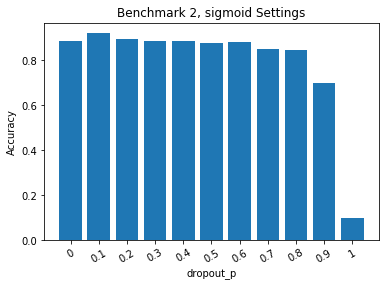

```python
# Create bar graph
plt.clf()
objects = ('0', '0.1', '0.2', '0.3', '0.4', '0.5', '0.6', '0.7', '0.8', '0.9', '1')
y_pos = np.arange(len(objects))
performance = [0.885, 0.92, 0.895, 0.885, 0.885, 0.875, 0.88, 0.85, 0.845, 0.7, 0.1]
plt.bar(y_pos, performance, align='center', alpha=1)
plt.xticks(y_pos, objects, rotation=30)
plt.xlabel('dropout_p')
plt.ylabel('Accuracy')
plt.title('Benchmark 2, sigmoid Settings')

plt.show()
plt.clf()
```

### Benchmark 2 (ReLu)

Same benchmark as benchmark 2 but with the ReLu function

```python
# ReLu, dropout = 0
acc0 = deep_belief_net(hidden_layers_structure=[300],
                       learning_rate_rbm=0.05,
                       learning_rate=0.1,
                       n_epochs_rbm=40,
                       n_iter_backprop=200,
                       batch_size=32,
                       activation_function='relu',
                       dropout_p=0.)
```

```
[START] Pre-training step:
>> Epoch 1 finished 	RBM Reconstruction error 76.494263
>> Epoch 2 finished 	RBM Reconstruction error 49.433613
>> Epoch 3 finished 	RBM Reconstruction error 34.763378
>> Epoch 4 finished 	RBM Reconstruction error 53.639404
>> Epoch 5 finished 	RBM Reconstruction error 47.919071
>> Epoch 6 finished 	RBM Reconstruction error 52.792355
>> Epoch 7 finished 	RBM Reconstruction error 34.348198
>> Epoch 8 finished 	RBM Reconstruction error 37.879623
>> Epoch 9 finished 	RBM Reconstruction error 40.244701
>> Epoch 10 finished 	RBM Reconstruction error 24.620647
>> Epoch 11 finished 	RBM Reconstruction error 46.829220
>> Epoch 12 finished 	RBM Reconstruction error 39.373817
>> Epoch 13 finished 	RBM Reconstruction error 34.669823
>> Epoch 14 finished 	RBM Reconstruction error 33.453056
>> Epoch 15 finished 	RBM Reconstruction error 37.854984
>> Epoch 16 finished 	RBM Reconstruction error 41.508236
>> Epoch 17 finished 	RBM Reconstruction error 34.404789
>> Epoch 18 finished 	RBM Reconstruction error 37.564243
>> Epoch 19 finished 	RBM Reconstruction error 29.922712
>> Epoch 20 finished 	RBM Reconstruction error 45.012032
>> Epoch 21 finished 	RBM Reconstruction error 45.408573
>> Epoch 22 finished 	RBM Reconstruction error 28.551580
>> Epoch 23 finished 	RBM Reconstruction error 37.426979
>> Epoch 24 finished 	RBM Reconstruction error 40.499168
>> Epoch 25 finished 	RBM Reconstruction error 35.235374
>> Epoch 26 finished 	RBM Reconstruction error 35.480835
>> Epoch 27 finished 	RBM Reconstruction error 41.282398
>> Epoch 28 finished 	RBM Reconstruction error 42.309975
>> Epoch 29 finished 	RBM Reconstruction error 40.058102
>> Epoch 30 finished 	RBM Reconstruction error 31.168457
>> Epoch 31 finished 	RBM Reconstruction error 43.066540
>> Epoch 32 finished 	RBM Reconstruction error 37.291489
>> Epoch 33 finished 	RBM Reconstruction error 31.662176
>> Epoch 34 finished 	RBM Reconstruction error 35.579239
>> Epoch 35 finished 	RBM Reconstruction error 46.759823
>> Epoch 36 finished 	RBM Reconstruction error 45.324329
>> Epoch 37 finished 	RBM Reconstruction error 42.645927
>> Epoch 38 finished 	RBM Reconstruction error 45.038387
>> Epoch 39 finished 	RBM Reconstruction error 44.802437
```

[output cut: 191 more lines]

```
>> Epoch 188 finished 	ANN training loss 0.002357
>> Epoch 189 finished 	ANN training loss 0.002341
>> Epoch 190 finished 	ANN training loss 0.002326
>> Epoch 191 finished 	ANN training loss 0.002311
>> Epoch 192 finished 	ANN training loss 0.002296
>> Epoch 193 finished 	ANN training loss 0.002281
>> Epoch 194 finished 	ANN training loss 0.002266
>> Epoch 195 finished 	ANN training loss 0.002252
>> Epoch 196 finished 	ANN training loss 0.002237
>> Epoch 197 finished 	ANN training loss 0.002223
>> Epoch 198 finished 	ANN training loss 0.002209
>> Epoch 199 finished 	ANN training loss 0.002195
[END] Fine tuning step
Done.
Accuracy: 0.880000
```

```python
print('ACCURACY: ' + str(acc0))
```

```
ACCURACY: 0.88
```

```python
# ReLu, dropout = 0.1
acc1 = deep_belief_net(hidden_layers_structure=[300],
                       learning_rate_rbm=0.05,
                       learning_rate=0.1,
                       n_epochs_rbm=40,
                       n_iter_backprop=200,
                       batch_size=32,
                       activation_function='relu',
                       dropout_p=0.1)
```

```
[START] Pre-training step:
>> Epoch 1 finished 	RBM Reconstruction error 72.055847
>> Epoch 2 finished 	RBM Reconstruction error 60.757393
>> Epoch 3 finished 	RBM Reconstruction error 61.084770
>> Epoch 4 finished 	RBM Reconstruction error 52.822067
>> Epoch 5 finished 	RBM Reconstruction error 45.157761
>> Epoch 6 finished 	RBM Reconstruction error 43.368752
>> Epoch 7 finished 	RBM Reconstruction error 55.778893
>> Epoch 8 finished 	RBM Reconstruction error 45.162216
>> Epoch 9 finished 	RBM Reconstruction error 37.964745
>> Epoch 10 finished 	RBM Reconstruction error 33.017380
>> Epoch 11 finished 	RBM Reconstruction error 54.482384
>> Epoch 12 finished 	RBM Reconstruction error 52.822216
>> Epoch 13 finished 	RBM Reconstruction error 46.630253
>> Epoch 14 finished 	RBM Reconstruction error 47.379044
>> Epoch 15 finished 	RBM Reconstruction error 43.645729
>> Epoch 16 finished 	RBM Reconstruction error 39.365711
>> Epoch 17 finished 	RBM Reconstruction error 47.167969
>> Epoch 18 finished 	RBM Reconstruction error 48.273788
>> Epoch 19 finished 	RBM Reconstruction error 45.013912
>> Epoch 20 finished 	RBM Reconstruction error 53.182144
>> Epoch 21 finished 	RBM Reconstruction error 50.217506
>> Epoch 22 finished 	RBM Reconstruction error 54.040089
>> Epoch 23 finished 	RBM Reconstruction error 50.279682
>> Epoch 24 finished 	RBM Reconstruction error 44.892334
>> Epoch 25 finished 	RBM Reconstruction error 60.720314
>> Epoch 26 finished 	RBM Reconstruction error 47.933243
>> Epoch 27 finished 	RBM Reconstruction error 45.958370
>> Epoch 28 finished 	RBM Reconstruction error 49.027050
>> Epoch 29 finished 	RBM Reconstruction error 51.609917
>> Epoch 30 finished 	RBM Reconstruction error 57.335293
>> Epoch 31 finished 	RBM Reconstruction error 53.782314
>> Epoch 32 finished 	RBM Reconstruction error 60.037567
>> Epoch 33 finished 	RBM Reconstruction error 41.730480
>> Epoch 34 finished 	RBM Reconstruction error 49.835506
>> Epoch 35 finished 	RBM Reconstruction error 45.948681
>> Epoch 36 finished 	RBM Reconstruction error 45.618214
>> Epoch 37 finished 	RBM Reconstruction error 58.829765
>> Epoch 38 finished 	RBM Reconstruction error 44.395443
>> Epoch 39 finished 	RBM Reconstruction error 41.659542
```

[output cut: 191 more lines]

```
>> Epoch 188 finished 	ANN training loss 0.001206
>> Epoch 189 finished 	ANN training loss 0.001159
>> Epoch 190 finished 	ANN training loss 0.001127
>> Epoch 191 finished 	ANN training loss 0.001106
>> Epoch 192 finished 	ANN training loss 0.001119
>> Epoch 193 finished 	ANN training loss 0.001094
>> Epoch 194 finished 	ANN training loss 0.001082
>> Epoch 195 finished 	ANN training loss 0.001071
>> Epoch 196 finished 	ANN training loss 0.001051
>> Epoch 197 finished 	ANN training loss 0.001081
>> Epoch 198 finished 	ANN training loss 0.001072
>> Epoch 199 finished 	ANN training loss 0.001053
[END] Fine tuning step
Done.
Accuracy: 0.890000
```

```python
print('ACCURACY: ' + str(acc1))
```

```
ACCURACY: 0.89
```

```python
# ReLu, dropout = 0.3
acc3 = deep_belief_net(hidden_layers_structure=[300],
                       learning_rate_rbm=0.05,
                       learning_rate=0.1,
                       n_epochs_rbm=40,
                       n_iter_backprop=200,
                       batch_size=32,
                       activation_function='relu',
                       dropout_p=0.3)
```

```
[START] Pre-training step:
>> Epoch 1 finished 	RBM Reconstruction error 56.206200
>> Epoch 2 finished 	RBM Reconstruction error 77.201317
>> Epoch 3 finished 	RBM Reconstruction error 43.497169
>> Epoch 4 finished 	RBM Reconstruction error 35.043930
>> Epoch 5 finished 	RBM Reconstruction error 29.859175
>> Epoch 6 finished 	RBM Reconstruction error 36.687565
>> Epoch 7 finished 	RBM Reconstruction error 43.480713
>> Epoch 8 finished 	RBM Reconstruction error 46.617226
>> Epoch 9 finished 	RBM Reconstruction error 41.150391
>> Epoch 10 finished 	RBM Reconstruction error 35.490501
>> Epoch 11 finished 	RBM Reconstruction error 34.342411
>> Epoch 12 finished 	RBM Reconstruction error 29.118097
>> Epoch 13 finished 	RBM Reconstruction error 33.308773
>> Epoch 14 finished 	RBM Reconstruction error 37.300919
>> Epoch 15 finished 	RBM Reconstruction error 44.223289
>> Epoch 16 finished 	RBM Reconstruction error 43.610748
>> Epoch 17 finished 	RBM Reconstruction error 42.425957
>> Epoch 18 finished 	RBM Reconstruction error 33.686352
>> Epoch 19 finished 	RBM Reconstruction error 32.535210
>> Epoch 20 finished 	RBM Reconstruction error 40.499744
>> Epoch 21 finished 	RBM Reconstruction error 30.235912
>> Epoch 22 finished 	RBM Reconstruction error 39.815880
>> Epoch 23 finished 	RBM Reconstruction error 46.056564
>> Epoch 24 finished 	RBM Reconstruction error 43.469513
>> Epoch 25 finished 	RBM Reconstruction error 37.808216
>> Epoch 26 finished 	RBM Reconstruction error 38.587616
>> Epoch 27 finished 	RBM Reconstruction error 39.078217
>> Epoch 28 finished 	RBM Reconstruction error 31.427929
>> Epoch 29 finished 	RBM Reconstruction error 38.274857
>> Epoch 30 finished 	RBM Reconstruction error 37.169632
>> Epoch 31 finished 	RBM Reconstruction error 36.369694
>> Epoch 32 finished 	RBM Reconstruction error 44.888748
>> Epoch 33 finished 	RBM Reconstruction error 60.992508
>> Epoch 34 finished 	RBM Reconstruction error 43.566807
>> Epoch 35 finished 	RBM Reconstruction error 71.165504
>> Epoch 36 finished 	RBM Reconstruction error 48.004337
>> Epoch 37 finished 	RBM Reconstruction error 56.236366
>> Epoch 38 finished 	RBM Reconstruction error 37.914242
>> Epoch 39 finished 	RBM Reconstruction error 40.765881
```

[output cut: 191 more lines]

```
>> Epoch 188 finished 	ANN training loss 0.001067
>> Epoch 189 finished 	ANN training loss 0.001031
>> Epoch 190 finished 	ANN training loss 0.000993
>> Epoch 191 finished 	ANN training loss 0.000976
>> Epoch 192 finished 	ANN training loss 0.001036
>> Epoch 193 finished 	ANN training loss 0.001026
>> Epoch 194 finished 	ANN training loss 0.000949
>> Epoch 195 finished 	ANN training loss 0.000948
>> Epoch 196 finished 	ANN training loss 0.000929
>> Epoch 197 finished 	ANN training loss 0.000967
>> Epoch 198 finished 	ANN training loss 0.000988
>> Epoch 199 finished 	ANN training loss 0.001036
[END] Fine tuning step
Done.
Accuracy: 0.900000
```

```python
print('ACCURACY: ' + str(acc3))
```

```
ACCURACY: 0.9
```

```python
# ReLu, dropout = 0.4
acc4 = deep_belief_net(hidden_layers_structure=[300],
                       learning_rate_rbm=0.05,
                       learning_rate=0.1,
                       n_epochs_rbm=40,
                       n_iter_backprop=200,
                       batch_size=32,
                       activation_function='relu',
                       dropout_p=0.4)
```

```
[START] Pre-training step:
>> Epoch 1 finished 	RBM Reconstruction error 65.088890
>> Epoch 2 finished 	RBM Reconstruction error 31.600693
>> Epoch 3 finished 	RBM Reconstruction error 38.023712
>> Epoch 4 finished 	RBM Reconstruction error 38.858429
>> Epoch 5 finished 	RBM Reconstruction error 33.014267
>> Epoch 6 finished 	RBM Reconstruction error 27.287451
>> Epoch 7 finished 	RBM Reconstruction error 27.105581
>> Epoch 8 finished 	RBM Reconstruction error 36.422344
>> Epoch 9 finished 	RBM Reconstruction error 59.886730
>> Epoch 10 finished 	RBM Reconstruction error 32.112198
>> Epoch 11 finished 	RBM Reconstruction error 26.038902
>> Epoch 12 finished 	RBM Reconstruction error 29.801992
>> Epoch 13 finished 	RBM Reconstruction error 28.663811
>> Epoch 14 finished 	RBM Reconstruction error 26.208193
>> Epoch 15 finished 	RBM Reconstruction error 25.640636
>> Epoch 16 finished 	RBM Reconstruction error 25.160589
>> Epoch 17 finished 	RBM Reconstruction error 33.832520
>> Epoch 18 finished 	RBM Reconstruction error 35.933903
>> Epoch 19 finished 	RBM Reconstruction error 38.471088
>> Epoch 20 finished 	RBM Reconstruction error 40.283703
>> Epoch 21 finished 	RBM Reconstruction error 34.686333
>> Epoch 22 finished 	RBM Reconstruction error 36.088261
>> Epoch 23 finished 	RBM Reconstruction error 33.995361
>> Epoch 24 finished 	RBM Reconstruction error 32.413864
>> Epoch 25 finished 	RBM Reconstruction error 35.722523
>> Epoch 26 finished 	RBM Reconstruction error 27.134438
>> Epoch 27 finished 	RBM Reconstruction error 35.185036
>> Epoch 28 finished 	RBM Reconstruction error 20.068762
>> Epoch 29 finished 	RBM Reconstruction error 29.205156
>> Epoch 30 finished 	RBM Reconstruction error 27.306763
>> Epoch 31 finished 	RBM Reconstruction error 38.133926
>> Epoch 32 finished 	RBM Reconstruction error 29.115192
>> Epoch 33 finished 	RBM Reconstruction error 31.015118
>> Epoch 34 finished 	RBM Reconstruction error 30.365646
>> Epoch 35 finished 	RBM Reconstruction error 27.149424
>> Epoch 36 finished 	RBM Reconstruction error 34.585625
>> Epoch 37 finished 	RBM Reconstruction error 39.828106
>> Epoch 38 finished 	RBM Reconstruction error 36.040863
>> Epoch 39 finished 	RBM Reconstruction error 51.653358
```

[output cut: 191 more lines]

```
>> Epoch 188 finished 	ANN training loss 0.001185
>> Epoch 189 finished 	ANN training loss 0.001050
>> Epoch 190 finished 	ANN training loss 0.001120
>> Epoch 191 finished 	ANN training loss 0.001193
>> Epoch 192 finished 	ANN training loss 0.001123
>> Epoch 193 finished 	ANN training loss 0.001136
>> Epoch 194 finished 	ANN training loss 0.001106
>> Epoch 195 finished 	ANN training loss 0.001060
>> Epoch 196 finished 	ANN training loss 0.001148
>> Epoch 197 finished 	ANN training loss 0.000971
>> Epoch 198 finished 	ANN training loss 0.000978
>> Epoch 199 finished 	ANN training loss 0.000997
[END] Fine tuning step
Done.
Accuracy: 0.890000
```

```python
print('ACCURACY: ' + str(acc4))
```

```
ACCURACY: 0.89
```

```python
# ReLu, dropout = 0.5
acc5 = deep_belief_net(hidden_layers_structure=[300],
                       learning_rate_rbm=0.05,
                       learning_rate=0.1,
                       n_epochs_rbm=40,
                       n_iter_backprop=200,
                       batch_size=32,
                       activation_function='relu',
                       dropout_p=0.5)
```

```
[START] Pre-training step:
>> Epoch 1 finished 	RBM Reconstruction error 61.709766
>> Epoch 2 finished 	RBM Reconstruction error 54.472504
>> Epoch 3 finished 	RBM Reconstruction error 75.873703
>> Epoch 4 finished 	RBM Reconstruction error 41.272430
>> Epoch 5 finished 	RBM Reconstruction error 43.754398
>> Epoch 6 finished 	RBM Reconstruction error 42.647362
>> Epoch 7 finished 	RBM Reconstruction error 40.159855
>> Epoch 8 finished 	RBM Reconstruction error 60.702248
>> Epoch 9 finished 	RBM Reconstruction error 37.104389
>> Epoch 10 finished 	RBM Reconstruction error 36.450516
>> Epoch 11 finished 	RBM Reconstruction error 50.309250
>> Epoch 12 finished 	RBM Reconstruction error 32.404320
>> Epoch 13 finished 	RBM Reconstruction error 40.761646
>> Epoch 14 finished 	RBM Reconstruction error 39.678955
>> Epoch 15 finished 	RBM Reconstruction error 43.482391
>> Epoch 16 finished 	RBM Reconstruction error 48.358349
>> Epoch 17 finished 	RBM Reconstruction error 41.619835
>> Epoch 18 finished 	RBM Reconstruction error 28.050406
>> Epoch 19 finished 	RBM Reconstruction error 44.146065
>> Epoch 20 finished 	RBM Reconstruction error 64.320587
>> Epoch 21 finished 	RBM Reconstruction error 34.633278
>> Epoch 22 finished 	RBM Reconstruction error 50.839394
>> Epoch 23 finished 	RBM Reconstruction error 50.193310
>> Epoch 24 finished 	RBM Reconstruction error 50.998871
>> Epoch 25 finished 	RBM Reconstruction error 46.640747
>> Epoch 26 finished 	RBM Reconstruction error 43.082211
>> Epoch 27 finished 	RBM Reconstruction error 48.230694
>> Epoch 28 finished 	RBM Reconstruction error 66.244759
>> Epoch 29 finished 	RBM Reconstruction error 50.090733
>> Epoch 30 finished 	RBM Reconstruction error 43.973370
>> Epoch 31 finished 	RBM Reconstruction error 42.613564
>> Epoch 32 finished 	RBM Reconstruction error 47.859264
>> Epoch 33 finished 	RBM Reconstruction error 52.287685
>> Epoch 34 finished 	RBM Reconstruction error 51.919575
>> Epoch 35 finished 	RBM Reconstruction error 54.550453
>> Epoch 36 finished 	RBM Reconstruction error 50.095306
>> Epoch 37 finished 	RBM Reconstruction error 53.549805
>> Epoch 38 finished 	RBM Reconstruction error 46.231861
>> Epoch 39 finished 	RBM Reconstruction error 56.310070
```

[output cut: 191 more lines]

```
>> Epoch 188 finished 	ANN training loss 0.003478
>> Epoch 189 finished 	ANN training loss 0.003374
>> Epoch 190 finished 	ANN training loss 0.003038
>> Epoch 191 finished 	ANN training loss 0.003253
>> Epoch 192 finished 	ANN training loss 0.002931
>> Epoch 193 finished 	ANN training loss 0.002856
>> Epoch 194 finished 	ANN training loss 0.002921
>> Epoch 195 finished 	ANN training loss 0.002922
>> Epoch 196 finished 	ANN training loss 0.003118
>> Epoch 197 finished 	ANN training loss 0.003332
>> Epoch 198 finished 	ANN training loss 0.003246
>> Epoch 199 finished 	ANN training loss 0.002912
[END] Fine tuning step
Done.
Accuracy: 0.890000
```

```python
print('ACCURACY: ' + str(acc5))
```

```
ACCURACY: 0.89
```

```python
# ReLu, dropout = 0.6
acc6 = deep_belief_net(hidden_layers_structure=[300],
                       learning_rate_rbm=0.05,
                       learning_rate=0.1,
                       n_epochs_rbm=40,
                       n_iter_backprop=200,
                       batch_size=32,
                       activation_function='relu',
                       dropout_p=0.6)
```

```
[START] Pre-training step:
>> Epoch 1 finished 	RBM Reconstruction error 61.378994
>> Epoch 2 finished 	RBM Reconstruction error 38.144863
>> Epoch 3 finished 	RBM Reconstruction error 48.835243
>> Epoch 4 finished 	RBM Reconstruction error 43.290958
>> Epoch 5 finished 	RBM Reconstruction error 44.144161
>> Epoch 6 finished 	RBM Reconstruction error 42.889774
>> Epoch 7 finished 	RBM Reconstruction error 33.065033
>> Epoch 8 finished 	RBM Reconstruction error 24.430702
>> Epoch 9 finished 	RBM Reconstruction error 32.138363
>> Epoch 10 finished 	RBM Reconstruction error 45.784576
>> Epoch 11 finished 	RBM Reconstruction error 32.016129
>> Epoch 12 finished 	RBM Reconstruction error 25.012192
>> Epoch 13 finished 	RBM Reconstruction error 32.610817
>> Epoch 14 finished 	RBM Reconstruction error 54.927158
>> Epoch 15 finished 	RBM Reconstruction error 47.476357
>> Epoch 16 finished 	RBM Reconstruction error 28.648687
>> Epoch 17 finished 	RBM Reconstruction error 27.258995
>> Epoch 18 finished 	RBM Reconstruction error 28.335403
>> Epoch 19 finished 	RBM Reconstruction error 43.332287
>> Epoch 20 finished 	RBM Reconstruction error 34.647114
>> Epoch 21 finished 	RBM Reconstruction error 33.540207
>> Epoch 22 finished 	RBM Reconstruction error 43.665752
>> Epoch 23 finished 	RBM Reconstruction error 35.126572
>> Epoch 24 finished 	RBM Reconstruction error 33.687454
>> Epoch 25 finished 	RBM Reconstruction error 26.624083
>> Epoch 26 finished 	RBM Reconstruction error 35.344112
>> Epoch 27 finished 	RBM Reconstruction error 35.424717
>> Epoch 28 finished 	RBM Reconstruction error 23.503057
>> Epoch 29 finished 	RBM Reconstruction error 28.569208
>> Epoch 30 finished 	RBM Reconstruction error 29.112249
>> Epoch 31 finished 	RBM Reconstruction error 38.162247
>> Epoch 32 finished 	RBM Reconstruction error 39.954365
>> Epoch 33 finished 	RBM Reconstruction error 34.830547
>> Epoch 34 finished 	RBM Reconstruction error 18.477585
>> Epoch 35 finished 	RBM Reconstruction error 26.755713
>> Epoch 36 finished 	RBM Reconstruction error 37.530590
>> Epoch 37 finished 	RBM Reconstruction error 39.838272
>> Epoch 38 finished 	RBM Reconstruction error 48.593719
>> Epoch 39 finished 	RBM Reconstruction error 33.874222
```

[output cut: 191 more lines]

```
>> Epoch 188 finished 	ANN training loss 0.008544
>> Epoch 189 finished 	ANN training loss 0.008372
>> Epoch 190 finished 	ANN training loss 0.008228
>> Epoch 191 finished 	ANN training loss 0.007931
>> Epoch 192 finished 	ANN training loss 0.007178
>> Epoch 193 finished 	ANN training loss 0.007475
>> Epoch 194 finished 	ANN training loss 0.007936
>> Epoch 195 finished 	ANN training loss 0.007389
>> Epoch 196 finished 	ANN training loss 0.007859
>> Epoch 197 finished 	ANN training loss 0.007093
>> Epoch 198 finished 	ANN training loss 0.007480
>> Epoch 199 finished 	ANN training loss 0.007590
[END] Fine tuning step
Done.
Accuracy: 0.870000
```

```python
print('ACCURACY: ' + str(acc6))
```

```
ACCURACY: 0.87
```

```python
# ReLu, dropout = 0.7
acc7 = deep_belief_net(hidden_layers_structure=[300],
                       learning_rate_rbm=0.05,
                       learning_rate=0.1,
                       n_epochs_rbm=40,
                       n_iter_backprop=200,
                       batch_size=32,
                       activation_function='relu',
                       dropout_p=0.7)
```

```
[START] Pre-training step:
>> Epoch 1 finished 	RBM Reconstruction error 56.047256
>> Epoch 2 finished 	RBM Reconstruction error 75.743523
>> Epoch 3 finished 	RBM Reconstruction error 30.459770
>> Epoch 4 finished 	RBM Reconstruction error 47.690372
>> Epoch 5 finished 	RBM Reconstruction error 45.758965
>> Epoch 6 finished 	RBM Reconstruction error 34.811928
>> Epoch 7 finished 	RBM Reconstruction error 34.652184
>> Epoch 8 finished 	RBM Reconstruction error 34.783401
>> Epoch 9 finished 	RBM Reconstruction error 29.111069
>> Epoch 10 finished 	RBM Reconstruction error 31.374155
>> Epoch 11 finished 	RBM Reconstruction error 57.646584
>> Epoch 12 finished 	RBM Reconstruction error 22.685879
>> Epoch 13 finished 	RBM Reconstruction error 38.631672
>> Epoch 14 finished 	RBM Reconstruction error 44.106903
>> Epoch 15 finished 	RBM Reconstruction error 46.644821
>> Epoch 16 finished 	RBM Reconstruction error 33.263466
>> Epoch 17 finished 	RBM Reconstruction error 32.393909
>> Epoch 18 finished 	RBM Reconstruction error 36.074516
>> Epoch 19 finished 	RBM Reconstruction error 37.753258
>> Epoch 20 finished 	RBM Reconstruction error 27.625925
>> Epoch 21 finished 	RBM Reconstruction error 24.151003
>> Epoch 22 finished 	RBM Reconstruction error 46.662666
>> Epoch 23 finished 	RBM Reconstruction error 37.606102
>> Epoch 24 finished 	RBM Reconstruction error 37.305729
>> Epoch 25 finished 	RBM Reconstruction error 30.290499
>> Epoch 26 finished 	RBM Reconstruction error 29.300077
>> Epoch 27 finished 	RBM Reconstruction error 25.525688
>> Epoch 28 finished 	RBM Reconstruction error 38.064743
>> Epoch 29 finished 	RBM Reconstruction error 29.105440
>> Epoch 30 finished 	RBM Reconstruction error 44.112823
>> Epoch 31 finished 	RBM Reconstruction error 30.791983
>> Epoch 32 finished 	RBM Reconstruction error 43.724434
>> Epoch 33 finished 	RBM Reconstruction error 26.208227
>> Epoch 34 finished 	RBM Reconstruction error 34.571922
>> Epoch 35 finished 	RBM Reconstruction error 36.998856
>> Epoch 36 finished 	RBM Reconstruction error 31.790464
>> Epoch 37 finished 	RBM Reconstruction error 23.368891
>> Epoch 38 finished 	RBM Reconstruction error 27.893360
>> Epoch 39 finished 	RBM Reconstruction error 44.985336
```

[output cut: 191 more lines]

```
>> Epoch 188 finished 	ANN training loss 0.061075
>> Epoch 189 finished 	ANN training loss 0.063031
>> Epoch 190 finished 	ANN training loss 0.058655
>> Epoch 191 finished 	ANN training loss 0.056797
>> Epoch 192 finished 	ANN training loss 0.056967
>> Epoch 193 finished 	ANN training loss 0.054322
>> Epoch 194 finished 	ANN training loss 0.056132
>> Epoch 195 finished 	ANN training loss 0.062337
>> Epoch 196 finished 	ANN training loss 0.061040
>> Epoch 197 finished 	ANN training loss 0.055425
>> Epoch 198 finished 	ANN training loss 0.058720
>> Epoch 199 finished 	ANN training loss 0.066024
[END] Fine tuning step
Done.
Accuracy: 0.900000
```

```python
print('ACCURACY: ' + str(acc7))
```

```
ACCURACY: 0.9
```

```python
# ReLu, dropout = 0.8
acc8 = deep_belief_net(hidden_layers_structure=[300],
                       learning_rate_rbm=0.05,
                       learning_rate=0.1,
                       n_epochs_rbm=40,
                       n_iter_backprop=200,
                       batch_size=32,
                       activation_function='relu',
                       dropout_p=0.8)
```

```
[START] Pre-training step:
>> Epoch 1 finished 	RBM Reconstruction error 60.473331
>> Epoch 2 finished 	RBM Reconstruction error 56.021935
>> Epoch 3 finished 	RBM Reconstruction error 71.656853
>> Epoch 4 finished 	RBM Reconstruction error 50.487885
>> Epoch 5 finished 	RBM Reconstruction error 50.820499
>> Epoch 6 finished 	RBM Reconstruction error 42.040997
>> Epoch 7 finished 	RBM Reconstruction error 34.458988
>> Epoch 8 finished 	RBM Reconstruction error 42.691341
>> Epoch 9 finished 	RBM Reconstruction error 52.118073
>> Epoch 10 finished 	RBM Reconstruction error 46.811501
>> Epoch 11 finished 	RBM Reconstruction error 32.541492
>> Epoch 12 finished 	RBM Reconstruction error 34.893253
>> Epoch 13 finished 	RBM Reconstruction error 52.058681
>> Epoch 14 finished 	RBM Reconstruction error 38.734688
>> Epoch 15 finished 	RBM Reconstruction error 37.273239
>> Epoch 16 finished 	RBM Reconstruction error 34.313351
>> Epoch 17 finished 	RBM Reconstruction error 48.837479
>> Epoch 18 finished 	RBM Reconstruction error 39.533573
>> Epoch 19 finished 	RBM Reconstruction error 30.994461
>> Epoch 20 finished 	RBM Reconstruction error 36.145123
>> Epoch 21 finished 	RBM Reconstruction error 26.398838
>> Epoch 22 finished 	RBM Reconstruction error 29.877769
>> Epoch 23 finished 	RBM Reconstruction error 32.888607
>> Epoch 24 finished 	RBM Reconstruction error 38.913994
>> Epoch 25 finished 	RBM Reconstruction error 34.648663
>> Epoch 26 finished 	RBM Reconstruction error 46.099884
>> Epoch 27 finished 	RBM Reconstruction error 42.561821
>> Epoch 28 finished 	RBM Reconstruction error 41.133087
>> Epoch 29 finished 	RBM Reconstruction error 35.349255
>> Epoch 30 finished 	RBM Reconstruction error 29.608042
>> Epoch 31 finished 	RBM Reconstruction error 34.103809
>> Epoch 32 finished 	RBM Reconstruction error 45.162472
>> Epoch 33 finished 	RBM Reconstruction error 43.641148
>> Epoch 34 finished 	RBM Reconstruction error 30.042070
>> Epoch 35 finished 	RBM Reconstruction error 38.409088
>> Epoch 36 finished 	RBM Reconstruction error 37.312607
>> Epoch 37 finished 	RBM Reconstruction error 34.084312
>> Epoch 38 finished 	RBM Reconstruction error 37.813393
>> Epoch 39 finished 	RBM Reconstruction error 40.761871
```

[output cut: 191 more lines]

```
>> Epoch 188 finished 	ANN training loss 0.452089
>> Epoch 189 finished 	ANN training loss 0.447998
>> Epoch 190 finished 	ANN training loss 0.428183
>> Epoch 191 finished 	ANN training loss 0.431471
>> Epoch 192 finished 	ANN training loss 0.415347
>> Epoch 193 finished 	ANN training loss 0.437009
>> Epoch 194 finished 	ANN training loss 0.427055
>> Epoch 195 finished 	ANN training loss 0.428547
>> Epoch 196 finished 	ANN training loss 0.420437
>> Epoch 197 finished 	ANN training loss 0.409065
>> Epoch 198 finished 	ANN training loss 0.418048
>> Epoch 199 finished 	ANN training loss 0.421983
[END] Fine tuning step
Done.
Accuracy: 0.800000
```

```python
print('ACCURACY: ' + str(acc8))
```

```
ACCURACY: 0.8
```

```python
# ReLu, dropout = 0.9
acc9 = deep_belief_net(hidden_layers_structure=[300],
                       learning_rate_rbm=0.05,
                       learning_rate=0.1,
                       n_epochs_rbm=40,
                       n_iter_backprop=200,
                       batch_size=32,
                       activation_function='relu',
                       dropout_p=0.9)
```

```
[START] Pre-training step:
>> Epoch 1 finished 	RBM Reconstruction error 51.625134
>> Epoch 2 finished 	RBM Reconstruction error 76.770470
>> Epoch 3 finished 	RBM Reconstruction error 72.536652
>> Epoch 4 finished 	RBM Reconstruction error 62.944092
>> Epoch 5 finished 	RBM Reconstruction error 53.268398
>> Epoch 6 finished 	RBM Reconstruction error 58.766701
>> Epoch 7 finished 	RBM Reconstruction error 48.798634
>> Epoch 8 finished 	RBM Reconstruction error 60.624760
>> Epoch 9 finished 	RBM Reconstruction error 56.839169
>> Epoch 10 finished 	RBM Reconstruction error 43.366913
>> Epoch 11 finished 	RBM Reconstruction error 43.427475
>> Epoch 12 finished 	RBM Reconstruction error 27.791582
>> Epoch 13 finished 	RBM Reconstruction error 40.248569
>> Epoch 14 finished 	RBM Reconstruction error 34.714977
>> Epoch 15 finished 	RBM Reconstruction error 57.294037
>> Epoch 16 finished 	RBM Reconstruction error 51.249142
>> Epoch 17 finished 	RBM Reconstruction error 49.431450
>> Epoch 18 finished 	RBM Reconstruction error 57.282455
>> Epoch 19 finished 	RBM Reconstruction error 39.906178
>> Epoch 20 finished 	RBM Reconstruction error 64.982338
>> Epoch 21 finished 	RBM Reconstruction error 46.795116
>> Epoch 22 finished 	RBM Reconstruction error 46.363087
>> Epoch 23 finished 	RBM Reconstruction error 48.862373
>> Epoch 24 finished 	RBM Reconstruction error 44.838661
>> Epoch 25 finished 	RBM Reconstruction error 36.712193
>> Epoch 26 finished 	RBM Reconstruction error 50.306717
>> Epoch 27 finished 	RBM Reconstruction error 41.899246
>> Epoch 28 finished 	RBM Reconstruction error 49.440899
>> Epoch 29 finished 	RBM Reconstruction error 54.250488
>> Epoch 30 finished 	RBM Reconstruction error 50.092716
>> Epoch 31 finished 	RBM Reconstruction error 50.622646
>> Epoch 32 finished 	RBM Reconstruction error 47.596855
>> Epoch 33 finished 	RBM Reconstruction error 43.325298
>> Epoch 34 finished 	RBM Reconstruction error 51.524601
>> Epoch 35 finished 	RBM Reconstruction error 48.152855
>> Epoch 36 finished 	RBM Reconstruction error 43.356514
>> Epoch 37 finished 	RBM Reconstruction error 59.101551
>> Epoch 38 finished 	RBM Reconstruction error 49.825939
>> Epoch 39 finished 	RBM Reconstruction error 47.288212
```

[output cut: 191 more lines]

```
>> Epoch 188 finished 	ANN training loss 2.160564
>> Epoch 189 finished 	ANN training loss 2.168859
>> Epoch 190 finished 	ANN training loss 2.152675
>> Epoch 191 finished 	ANN training loss 2.160844
>> Epoch 192 finished 	ANN training loss 2.137596
>> Epoch 193 finished 	ANN training loss 2.140012
>> Epoch 194 finished 	ANN training loss 2.136550
>> Epoch 195 finished 	ANN training loss 2.130581
>> Epoch 196 finished 	ANN training loss 2.121011
>> Epoch 197 finished 	ANN training loss 2.138720
>> Epoch 198 finished 	ANN training loss 2.155964
>> Epoch 199 finished 	ANN training loss 2.149277
[END] Fine tuning step
Done.
Accuracy: 0.155000
```

```python
print('ACCURACY: ' + str(acc9))
```

```
ACCURACY: 0.155
```

```python
# ReLu, dropout = 1
acc10 = deep_belief_net(hidden_layers_structure=[300],
                       learning_rate_rbm=0.05,
                       learning_rate=0.1,
                       n_epochs_rbm=40,
                       n_iter_backprop=200,
                       batch_size=32,
                       activation_function='relu',
                       dropout_p=1.)
```

```
[START] Pre-training step:
>> Epoch 1 finished 	RBM Reconstruction error 79.109840
>> Epoch 2 finished 	RBM Reconstruction error 63.176834
>> Epoch 3 finished 	RBM Reconstruction error 53.967606
>> Epoch 4 finished 	RBM Reconstruction error 32.274902
>> Epoch 5 finished 	RBM Reconstruction error 32.726784
>> Epoch 6 finished 	RBM Reconstruction error 37.979504
>> Epoch 7 finished 	RBM Reconstruction error 31.923939
>> Epoch 8 finished 	RBM Reconstruction error 36.889969
>> Epoch 9 finished 	RBM Reconstruction error 26.216021
>> Epoch 10 finished 	RBM Reconstruction error 25.015684
>> Epoch 11 finished 	RBM Reconstruction error 28.614719
>> Epoch 12 finished 	RBM Reconstruction error 24.293184
>> Epoch 13 finished 	RBM Reconstruction error 26.673061
>> Epoch 14 finished 	RBM Reconstruction error 25.868410
>> Epoch 15 finished 	RBM Reconstruction error 37.665257
>> Epoch 16 finished 	RBM Reconstruction error 37.511024
>> Epoch 17 finished 	RBM Reconstruction error 43.258770
>> Epoch 18 finished 	RBM Reconstruction error 30.991518
>> Epoch 19 finished 	RBM Reconstruction error 42.074825
>> Epoch 20 finished 	RBM Reconstruction error 21.609245
>> Epoch 21 finished 	RBM Reconstruction error 28.272455
>> Epoch 22 finished 	RBM Reconstruction error 28.798027
>> Epoch 23 finished 	RBM Reconstruction error 27.145079
>> Epoch 24 finished 	RBM Reconstruction error 27.364443
>> Epoch 25 finished 	RBM Reconstruction error 24.284081
>> Epoch 26 finished 	RBM Reconstruction error 50.532295
>> Epoch 27 finished 	RBM Reconstruction error 22.311724
>> Epoch 28 finished 	RBM Reconstruction error 25.176216
>> Epoch 29 finished 	RBM Reconstruction error 26.835533
>> Epoch 30 finished 	RBM Reconstruction error 23.717609
>> Epoch 31 finished 	RBM Reconstruction error 28.740952
>> Epoch 32 finished 	RBM Reconstruction error 32.097599
>> Epoch 33 finished 	RBM Reconstruction error 38.287491
>> Epoch 34 finished 	RBM Reconstruction error 33.548656
>> Epoch 35 finished 	RBM Reconstruction error 38.731396
>> Epoch 36 finished 	RBM Reconstruction error 25.642601
>> Epoch 37 finished 	RBM Reconstruction error 40.658470
>> Epoch 38 finished 	RBM Reconstruction error 22.271059
>> Epoch 39 finished 	RBM Reconstruction error 39.835522
```

[output cut: 191 more lines]

```
>> Epoch 188 finished 	ANN training loss nan
>> Epoch 189 finished 	ANN training loss nan
>> Epoch 190 finished 	ANN training loss nan
>> Epoch 191 finished 	ANN training loss nan
>> Epoch 192 finished 	ANN training loss nan
>> Epoch 193 finished 	ANN training loss nan
>> Epoch 194 finished 	ANN training loss nan
>> Epoch 195 finished 	ANN training loss nan
>> Epoch 196 finished 	ANN training loss nan
>> Epoch 197 finished 	ANN training loss nan
>> Epoch 198 finished 	ANN training loss nan
>> Epoch 199 finished 	ANN training loss nan
[END] Fine tuning step
Done.
Accuracy: 0.100000
```

```python
print('ACCURACY: ' + str(acc10))
```

```
ACCURACY: 0.1
```

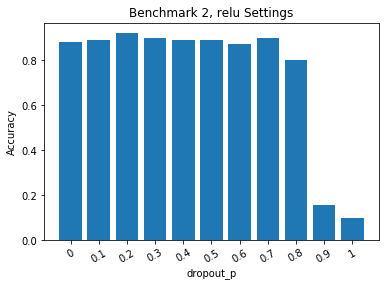

```python
# Create bar graph
plt.clf()
objects = ('0', '0.1', '0.2', '0.3', '0.4', '0.5', '0.6', '0.7', '0.8', '0.9', '1')
y_pos = np.arange(len(objects))
performance = [0.88, 0.89, 0.92, 0.90, 0.89, 0.89, 0.87, 0.90, 0.80, 0.155, 0.1]
plt.bar(y_pos, performance, align='center', alpha=1)
plt.xticks(y_pos, objects, rotation=30)
plt.xlabel('dropout_p')
plt.ylabel('Accuracy')
plt.title('Benchmark 2, relu Settings')

plt.show()
plt.clf()
```

[output not shown]

## SVM Tests:

```python
# Import SVM modules
from sklearn.svm import LinearSVC
from sklearn.tree import DecisionTreeClassifier
from sklearn.ensemble import AdaBoostClassifier
from sklearn.ensemble import RandomForestClassifier
from sklearn.svm import SVC
```

```python
# Linear SVC Performance
def linSVC(C):
    X_train, X_test, Y_train, Y_test = train_test_split(X, Y, test_size=0.2, random_state=0)
    clf = LinearSVC(C=C)
    clf.fit(X_train, Y_train)
    Y_pred = clf.predict(X_test)
    correct = 0
    for i in range(0, len(Y_test)):
        if Y_pred[i] == Y_test[i]:
            correct += 1
    return float(correct / len(Y_test))
```

```python
linSVC_acc1 = linSVC(C=0.1)
print('ACCURACY: ' + str(linSVC_acc1))
```

```
ACCURACY: 0.86
```

```python
linSVC_acc2 = linSVC(C=1.)
print('ACCURACY: ' + str(linSVC_acc2))
```

```
ACCURACY: 0.845
```

```python
linSVC_acc3 = linSVC(C=10)
print('ACCURACY: ' + str(linSVC_acc3))
```

```
ACCURACY: 0.84
```

```python
linSVC_acc4 = linSVC(C=100)
print('ACCURACY: ' + str(linSVC_acc4))
```

```
ACCURACY: 0.84
```

```python
# Decision Tree Performance
def decision_tree():
    X_train, X_test, Y_train, Y_test = train_test_split(X, Y, test_size=0.2, random_state=0)
    clf = DecisionTreeClassifier()
    clf.fit(X_train, Y_train)
    Y_pred = clf.predict(X_test)
    correct = 0
    for i in range(0, len(Y_test)):
        if Y_pred[i] == Y_test[i]:
            correct += 1
    return float(correct / len(Y_test))

decision_tree_acc = decision_tree()
print('ACCURACY: ' + str(decision_tree_acc))
```

```
ACCURACY: 0.665
```

```python
# Boosting Performance
def boosting():
    X_train, X_test, Y_train, Y_test = train_test_split(X, Y, test_size=0.2, random_state=0)
    clf = AdaBoostClassifier()
    clf.fit(X_train, Y_train)
    Y_pred = clf.predict(X_test)
    correct = 0
    for i in range(0, len(Y_test)):
        if Y_pred[i] == Y_test[i]:
            correct += 1
    return float(correct / len(Y_test))

boosting_acc = boosting()
print('ACCURACY: ' + str(boosting_acc))
```

```
ACCURACY: 0.395
```

```python
# Random Forest Performance
def random_forest():
    X_train, X_test, Y_train, Y_test = train_test_split(X, Y, test_size=0.2, random_state=0)
    clf = RandomForestClassifier()
    clf.fit(X_train, Y_train)
    Y_pred = clf.predict(X_test)
    correct = 0
    for i in range(0, len(Y_test)):
        if Y_pred[i] == Y_test[i]:
            correct += 1
    return float(correct / len(Y_test))

random_forest_acc = random_forest()
print('ACCURACY: ' + str(random_forest_acc))
```

```
ACCURACY: 0.795
```

```python
# SVC, 3rd degree rbf
def svc_classifier(C):
    X_train, X_test, Y_train, Y_test = train_test_split(X, Y, test_size=0.2, random_state=0)
    clf = SVC(C=C, max_iter=-1)
    clf.fit(X_train, Y_train)
    Y_pred = clf.predict(X_test)
    correct = 0
    for i in range(0, len(Y_test)):
        if Y_pred[i] == Y_test[i]:
            correct += 1
    return float(correct / len(Y_test))
```

```python
svc1_acc = svc_classifier(0.1)
print('ACCURACY: ' + str(svc1_acc))
```

```
ACCURACY: 0.115
```

```python
svc2_acc = svc_classifier(1.0)
print('ACCURACY: ' + str(svc2_acc))
```

```
ACCURACY: 0.805
```

```python
svc3_acc = svc_classifier(10.)
print('ACCURACY: ' + str(svc3_acc))
```

```
ACCURACY: 0.885
```

```python
svc4_acc = svc_classifier(100.)
print('ACCURACY: ' + str(svc4_acc))
```

```
ACCURACY: 0.895
```

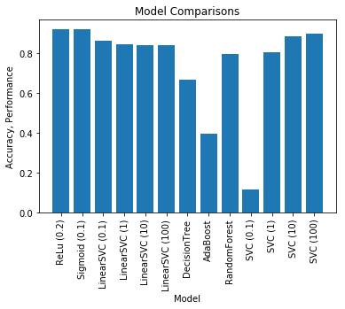

```python
# Create bar graph
plt.clf()
objects = ('ReLu (0.2)', 'Sigmoid (0.1)',
           'LinearSVC (0.1)', 'LinearSVC (1)', 'LinearSVC (10)', 'LinearSVC (100)',
           'DecisionTree', 'AdaBoost', 'RandomForest',
           'SVC (0.1)', 'SVC (1)', 'SVC (10)', 'SVC (100)')

y_pos = np.arange(len(objects))
performance = [0.92, 0.92,
               0.86, 0.845, 0.84, 0.84,
               0.665, 0.395, 0.795,
               0.115, 0.805, 0.885, 0.895]
plt.bar(y_pos, performance, align='center', alpha=1)
plt.xticks(y_pos, objects, rotation=90)
plt.xlabel('Model')
plt.ylabel('Accuracy, Performance')
plt.title('Model Comparisons')

plt.show()
plt.clf()
```